# Digital Epidemiology

## Assignment No. 2 - Influenza-like Illness

## Giacomo Legnaro

The goal of this assignment is to try and reproduce for Italy the results reported in the article for the USA *D.J. McIver & J. S. Brownstein (2014), "Wikipedia Usage Estimates Prevalence of Influenza-Like Illness in the United States in Near Real-Time", PLoS Comput Biol 10(4): http://journals.plos.org/ploscompbiol/article?id=10.1371/journal.pcbi.1003581*

Official data on influenza in Italy are collected by the "Istituto Superiore di Sanità" with a program called "Influnet" that uses sentinel doctors. The project is described here: http://www.iss.it/iflu/index.php?lang=1&anno=2016&tipo=4

These data will be our ground truth.

To reproduce the paper we download page view counts from wikipedia of such keywords related to flu.

Let's start with import all the libraries needed.

```python
import os
import io
import sys
import glob
import time
import gzip
import shutil
import urllib
import urllib2
import os.path
import warnings
import datetime
import requests
import cStringIO
import cleanfile
import itertools
import subprocess
import multiprocessing

import scipy.stats
import scipy.signal
import statsmodels.tsa

import numpy as np
import pandas as pd
import matplotlib.pyplot as plt
import scikits.statsmodels.api as sm
import statsmodels.tsa.stattools

from scipy import stats
from sklearn import metrics
from itertools import islice
from sklearn import linear_model
from sklearn.pipeline import Pipeline
from scipy.stats.stats import pearsonr
from sklearn.model_selection import KFold
from sklearn.preprocessing import normalize
from sklearn.model_selection import train_test_split
from sklearn.preprocessing import PolynomialFeatures
from sklearn.feature_selection import f_regression, mutual_info_regression

from random import choice
from bs4 import BeautifulSoup
from joblib import Parallel, delayed
from multiprocessing.dummy import Pool

%matplotlib inline
plt.rcParams['figure.figsize'] = (10, 6)
io_method = cStringIO.StringIO
```

# Section 1

### Wikipedia download data

First part of this assignment is dedicated to downloads the data from Wikipedia. I have decided to download locally all the data that i'm interested to and only after process them. In this notebook the output of this part will not be full but only a initial printout. All the data are downloaded and analyze with this code. (You can run it only modifying the path. Storage size requested to download all the data locally ~3TB, fibre connection DL:70Mb/s UL:20Mb/s, data download speed 50-65Mb/s)

#### Limit in download speed and simultaneously number of download files

One of the problem that I have encounter with the download of the data from https://dumps.wikimedia.org is due to a limited file download speed give from wikimedia and a limit of 3 simultaneously download for each browser. To bypass this limits, I have written the code so that the downloads are parallelized with the use of different "browser" only with send a different *user-agent* string. The number of file download simultaneously for each browser are limited at 2 times number of browser because map function not apply the function in a certain order but randomly, and the mod mode to assign the user-agent string is not so efficient in this case. In case of more than 3 file use the same browser, the downloads of the extra file will be interrupt at the begin and the size of this file will be equal to '213'. In this case try-catch with a while loop permit to sleep 2-seconds and retry to download.

#### Issue with external HD

Download all the files locally require a lot of large transfers and is not possible to use directly an external HD (I have tried it and it go slowly, with error, and reduce a lot the speed). So, I have download every month in my pc and also after that I have transfer all the files in the external HD.

#### Wikimedia empty files

One other problem is the presence of empty file, this case are treated separately with relax of some constraint impose in the rest of the downloads.

#### Wikimedia raw data

From 2015-05 Wikimedia datasets is getting produced by stripping down extra-information from Pagecounts-all-sites. This required a change in the path from pagecounts-raw up to 2015-04 to pageviews from 2015-05.

#### Data collected

The data collected are from 2011-10-01 up to 2016-04-30: 5 Influenza seasons.

```python
def makeDirectory(path):
    """
    Return the directory path where save the documents

    :param path: path where create the new folder
    :param directory: name of the new folder
    """
    try:
        os.makedirs(os.path.join(path))
    except OSError:
        if not os.path.isdir(os.path.join(path)):
            raise
    return os.path.join(path)
```

```python
def download_data(yr,mth,l_dl):
    path = yr + '/' + mth + '/' + l_dl
    urllib.URLopener.version = user_agents[link_dl.index(l_dl)%len(user_agents)]
    wikimedia = urllib.URLopener()
    headers = {"Content-Length": '213'}
    while int(headers["Content-Length"]) < 5000:
        try:
            filename, headers = wikimedia.retrieve(main_url + path, '/Users/giacomolegnaro/Downloads/Wikimedia/' + l_dl)
        except IOError:
            time.sleep(2)
    print(yr + ' ' + mth + ' ' + l_dl + ' - Progress ' + str(round(float(len(os.listdir('/Users/giacomolegnaro/Downloads/Wikimedia/'))) / len(link_dl)*100, 2))+'%')
```

```python
opener = urllib2.build_opener()
```

```python
user_agents = [
    'AmigaVoyager/3.2 (AmigaOS/MC680x0)',
    'Cyberdog/2.0 (Macintosh; PPC)',
    'IBM WebExplorer /v0.94',
    'Lynx/2.8.5rel.1 libwww-FM/2.14 SSL-MM/1.4.1 GNUTLS/1.2.9',
    'Mozilla/4.0 (compatible; MSIE 6.0; Windows NT 5.1; SV1; .NET CLR 1.1.4322; .NET CLR 2.0.50727)',
    'Mozilla/4.0 (compatible; MSIE 7.0; America Online Browser 1.1; Windows NT 5.1; (R1 1.5); .NET CLR 2.0.50727; InfoPath.1)',
    'Mozilla/4.0 (compatible; MSIE 7.0; Windows NT 5.1; Trident/4.0; .NET4.0C; .NET4.0E; .NET CLR 2.0.50727; .NET CLR 1.1.4322; .NET CLR 3.0.4506.2152; .NET CLR 3.5.30729; Browzar)',
    'Mozilla/4.0 (compatible; MSIE 7.0; Windows NT 6.1; WOW64; Trident/4.0; Deepnet Explorer 1.5.3; Smart 2x2; SLCC2; .NET CLR 2.0.50727; .NET CLR 3.5.30729; .NET CLR 3.0.30729; Media Center PC 6.0; .NET4.0C; .NET4.0E)',
    'Mozilla/4.0 (compatible; MSIE 8.0; Windows NT 6.1; Trident/4.0; Avant Browser; SLCC2; .NET CLR 2.0.50727; .NET CLR 3.5.30729; .NET CLR 3.0.30729; Media Center PC 6.0)',
    'Mozilla/4.08 (Charon; Inferno)',
    'Mozilla/5.0 (Macintosh; Intel Mac OS X 10_9_3) AppleWebKit/537.75.14 (KHTML, like Gecko) Version/7.0.3 Safari/7046A194A',
    'Mozilla/5.0 (Macintosh; U; Intel Mac OS X 10.6; en-US; rv:1.9.2.3) Gecko/20100402 Prism/1.0b4',
    'Mozilla/5.0 (Macintosh; U; PPC Mac OS X Mach-O; XH; rv:8.578.498) fr, Gecko/20121021 Camino/8.723+ (Firefox compatible)',
    'Mozilla/5.0 (Macintosh; U; PPC Mac OS X; en) AppleWebKit/418.8 (KHTML, like Gecko, Safari) Cheshire/1.0.UNOFFICIAL',
    'Mozilla/5.0 (Macintosh; U; PPC Mac OS X; pl-PL; rv:1.0.1) Gecko/20021111 Chimera/0.6',
    'Mozilla/5.0 (Macintosh; U; PPC Mac OS X; pl-pl) AppleWebKit/312.8 (KHTML, like Gecko, Safari) DeskBrowse/1.0',
    'Mozilla/5.0 (Macintosh; U; PPC; en-US; mimic; rv:9.3.0) Gecko/20120117 Firefox/3.6.25 Classilla/CFM',
    'Mozilla/5.0 (Windows NT 5.2; RW; rv:7.0a1) Gecko/20091211 SeaMonkey/9.23a1pre',
    'Mozilla/5.0 (Windows NT 6.1) AppleWebKit/537.36 (KHTML, like Gecko) Chrome/41.0.2228.0 Safari/537.36',
    'Mozilla/5.0 (Windows NT 6.1; WOW64) AppleWebKit/534.24 (KHTML, like Gecko) RockMelt/0.9.58.494 Chrome/11.0.696.71 Safari/534.24',
    'Mozilla/5.0 (Windows NT 6.1; WOW64; Trident/7.0; AS; rv:11.0) like Gecko',
    'Mozilla/5.0 (Windows NT 6.2) AppleWebKit/535.7 (KHTML, like Gecko) Comodo_Dragon/16.1.1.0 Chrome/16.0.912.63 Safari/535.7',
    'Mozilla/5.0 (Windows; U; Win 9x 4.90; SG; rv:1.9.2.4) Gecko/20101104 Netscape/9.1.0285',
    'Mozilla/5.0 (Windows; U; WinNT; en; rv:1.0.2) Gecko/20030311 Beonex/0.8.2-stable',
    'Mozilla/5.0 (Windows; U; Windows NT 5.1; en-US) AppleWebKit/532.2 (KHTML, like Gecko) ChromePlus/4.0.222.3 Chrome/4.0.222.3 Safari/532.2',
    'Mozilla/5.0 (Windows; U; Windows NT 5.1; it; rv:1.8.1.11) Gecko/20071127 Firefox/2.0.0.11',
    'Mozilla/5.0 (Windows; U; Windows NT 6.1; en-US; rv:1.9.2.3) Gecko/20100409 Firefox/3.6.3 CometBird/3.6.3',
    'Mozilla/5.0 (Windows; U; Windows NT 6.1; x64; fr; rv:1.9.2.13) Gecko/20101203 Firebird/3.6.13',
    'Mozilla/5.0 (X11; Linux x86_64; rv:10.0.11) Gecko/20100101 conkeror/1.0pre (Debian-1.0~~pre+git120527-1)',
    'Mozilla/5.0 (X11; U; Linux i686; en-US; rv:1.3a) Gecko/20021207 Phoenix/0.5',
    'Mozilla/5.0 (X11; U; Linux i686; en-US; rv:1.8.0.12) Gecko/20070731 Ubuntu/dapper-security Firefox/1.5.0.12',
    'Mozilla/5.0 (X11; U; Linux i686; nl; rv:1.8.1b2) Gecko/20060821 BonEcho/2.0b2 (Debian-1.99+2.0b2+dfsg-1)',
    'Mozilla/5.0 (X11; U; Linux x86_64; cs-CZ) AppleWebKit/533.3 (KHTML, like Gecko) rekonq Safari/533.3',
    'Mozilla/5.0 (compatible; Konqueror/3.5; Linux) KHTML/3.5.5 (like Gecko) (Kubuntu)',
    'Mozilla/5.0 (compatible; MSIE 8.0; Windows NT 6.0; SV1; Crazy Browser 9.0.04)',
    'Mozilla/5.0 (compatible; MSIE 9.0; AOL 9.7; AOLBuild 4343.19; Windows NT 6.1; WOW64; Trident/5.0; FunWebProducts)',
    'Mozilla/5.0 (compatible; U; ABrowse 0.6; Syllable) AppleWebKit/420+ (KHTML, like Gecko)Mozilla/5.0 (compatible; MSIE 8.0; Windows NT 6.0; Trident/4.0; Acoo Browser 1.98.744; .NET CLR 3.5.30729)',
    'Mozilla/6.0 (X11; U; Linux x86_64; en-US; rv:2.9.0.3) Gecko/2009022510 FreeBSD/ Sunrise/4.0.1/like Safari',
    'Opera/9.80 (X11; Linux i686; Ubuntu/14.10) Presto/2.12.388 Version/12.16',
    'Sundance/0.9x(Compatible; Windows; U; en-US;)Version/0.9x'
]
```

```python
for yr in ['2016']:
    for m in ['-04','-03','-02','-01']:
        mth = yr + m

        if (yr == '2016') or ((yr == '2015') and (m not in ['-01', '-02', '-03', '-04'])):
            sel = 'pageviews'
        else:
            sel = 'pagecounts-raw'
        main_url = 'https://dumps.wikimedia.org/other/' + sel + '/'
        print(yr + ' ' + mth)
        r = requests.get(main_url + yr + '/' + mth + '/')
        soup = BeautifulSoup(r.content, "html.parser")
        link_dl = [link.get('href').encode('utf8') for link in soup.find_all('a') if ((link.get('href') == link.string) and (link.string.split('-')[0] == sel.split('-')[0]))]
        print len(link_dl)
        makeDirectory('/Users/giacomolegnaro/Downloads/Wikimedia/')
        makeDirectory('/Volumes/My Book/Wikimedia/' + sel + '/' + yr + '/' + mth + '/')

        p = Pool(len(user_agents)*2)

        out = p.map(lambda l_dl: download_data(yr,mth,l_dl), link_dl)

        path = yr + '/' + mth + '/'
        source = '/Users/giacomolegnaro/Downloads/Wikimedia/'
        dest = '/Volumes/My Book/Wikimedia/' + sel + '/'
        out = [shutil.move(source + f,dest + path + f) for f in os.listdir(source)]
```

[output not shown]

[output cut: 707 more lines]

```python
for yr in ['2015','2014','2013','2012']:
    for m in ['-12','-11','-10','-04','-03','-02','-01']:
        mth = yr + m

        if (yr == '2016') or ((yr == '2015') and (m not in ['-01', '-02', '-03', '-04'])):
            sel = 'pageviews'
        else:
            sel = 'pagecounts-raw'
        main_url = 'https://dumps.wikimedia.org/other/' + sel + '/'
        print(yr + ' ' + mth)
        r = requests.get(main_url + yr + '/' + mth + '/')
        soup = BeautifulSoup(r.content, "html.parser")
        link_dl = [link.get('href').encode('utf8') for link in soup.find_all('a') if ((link.get('href') == link.string) and (link.string.split('-')[0] == sel.split('-')[0]))]
        print len(link_dl)
        makeDirectory('/Users/giacomolegnaro/Downloads/Wikimedia/')
        makeDirectory('/Volumes/My Book/Wikimedia/' + sel + '/' + yr + '/' + mth + '/')

        p = Pool(len(user_agents)*2)

        out = p.map(lambda l_dl: download_data(yr,mth,l_dl), link_dl)

        path = yr + '/' + mth + '/'
        source = '/Users/giacomolegnaro/Downloads/Wikimedia/'
        dest = '/Volumes/My Book/Wikimedia/' + sel + '/'
        out = [shutil.move(source + f,dest + path + f) for f in os.listdir(source)]
```

[output not shown]

[output cut: 731 more lines]

```python
for yr in ['2011']:
    for m in ['-12','-11','-10']:
        mth = yr + m

        if (yr == '2016') or ((yr == '2015') and (m not in ['-01', '-02', '-03', '-04'])):
            sel = 'pageviews'
        else:
            sel = 'pagecounts-raw'
        main_url = 'https://dumps.wikimedia.org/other/' + sel + '/'
        print(yr + ' ' + mth)
        r = requests.get(main_url + yr + '/' + mth + '/')
        soup = BeautifulSoup(r.content, "html.parser")
        link_dl = [link.get('href').encode('utf8') for link in soup.find_all('a') if ((link.get('href') == link.string) and (link.string.split('-')[0] == sel.split('-')[0]))]
        print len(link_dl)
        makeDirectory('/Users/giacomolegnaro/Downloads/Wikimedia/')
        makeDirectory('/Volumes/My Book/Wikimedia/' + sel + '/' + yr + '/' + mth + '/')

        p = Pool(len(user_agents)*2)

        out = p.map(lambda l_dl: download_data(yr,mth,l_dl), link_dl)

        path = yr + '/' + mth + '/'
        source = '/Users/giacomolegnaro/Downloads/Wikimedia/'
        dest = '/Volumes/My Book/Wikimedia/' + sel + '/'
        out = [shutil.move(source + f,dest + path + f) for f in os.listdir(source)]
```

[output not shown]

[output cut: 731 more lines]

#### Code to download not ok files (interrupt, error not try-catch, exceptions)

This code is used 4-5 times in all the download time

```python
yr = '2011'
m = '-12'
mth = yr + m
```

```python
if (yr == '2016') or ((yr == '2015') and (m not in ['-01', '-02', '-03', '-04'])):
    sel = 'pageviews'
else:
    sel = 'pagecounts-raw'
main_url = 'https://dumps.wikimedia.org/other/' + sel + '/'
```

```python
print(yr + ' ' + mth)
r = requests.get(main_url + yr + '/' + mth + '/')
soup = BeautifulSoup(r.content, "html.parser")
link_dl = [link.get('href').encode('utf8') for link in soup.find_all('a') if ((link.get('href') == link.string) and (link.string.split('-')[0] == sel.split('-')[0]))]
file_dl = os.listdir('/Users/giacomolegnaro/Downloads/Wikimedia/')
# make the difference between downloaded files and not downloaded
to_dl = list(set(link_dl) - set(file_dl))
```

```
2011 2011-12
```

```python
def download_data(yr,mth,l_dl):
    path = yr + '/' + mth + '/' + l_dl
    urllib.URLopener.version = user_agents[link_dl.index(l_dl)%len(user_agents)]
    wikimedia = urllib.URLopener()
    wikimedia.retrieve(main_url + path, '/Users/giacomolegnaro/Downloads/Wikimedia/' + l_dl)
    print(yr + ' ' + mth + ' ' + l_dl + ' - Progress ' + str(round(float(len(os.listdir('/Users/giacomolegnaro/Downloads/Wikimedia/'))) / len(link_dl)*100, 2))+'%')
```

```python
for l_dl in to_dl:
    download_data(yr,mth,l_dl)
```

```python
path = yr + '/' + mth + '/'
source = '/Users/giacomolegnaro/Downloads/Wikimedia/'
dest = '/Volumes/My Book/Wikimedia/' + sel + '/'
out = [shutil.move(source + f,dest + path + f) for f in os.listdir(source)]
```

# Section 2

### Wikipedia analyze data

Second part of this notebook is dedicated to the analyze of the download files. Each month required to comment the row code free and uncomment the desired month.

(The code is reported in one chunck - mainly algorithm - and is request to comment/uncomment only PATH_TO_FILE for each month)

*Note: This code work only with macOS system. The 'gzcat' function to ungzip the file request masOS Operating System.*

#### Slow analyze

One of the limit in the speed of the analyze is due to the read speed from an external HD (USB 3.0) but in this case nothing is possible to reduce it.

Ungzip the file and read row by row required ~30 seconds for each file, too much! With 'gzcat' function I have reduce a lot the time to unzip (~1-2 seconds).

Another limit is due to read all the rows of the file! This is not necessary! I have open and read some random files and I have seen thata it start always after 3500000 rows, and with the function islice from itertools I have reduce a lot the computational time. Similarly to the jump at 3500000 I have think is not necessary to read all the rows after, and when 'it' is no more the row start, I have dropped down the analyze and go to the next file.

At the end, the time for each file go from 2 to 5 seconds.

#### 'it' and 'it.m'

I have read in the wikimedia page https://dumps.wikimedia.org/other/pagecounts-raw/, open and read some random files and I have found that 'it.m' is not the page views from mobile devices but of wikimedia project. 'it.mw' is the correct views from the wikipedia mobile devices, but this views are not for each page, but aggregated! In this study I have only considered the 'it' page views.

#### Chronology wikipedia pages

Yes, another problem! Sometimes the page are subject to a merge with other pages, or to a change of the name, or some other things. I assume are not all, but I will report below some things:

- 13:53, 6 dic 2013 "Gambo7 ha spostato la pagina Virus dell'influenza A sottotipo H1N1 a Influenzavirus A sottotipo H1N1: omologia con Influenzavirus A". In this case an user have changed and merge *Virus_dell'influenza_A_sottotipo_H1N1* into *Influenzavirus_A_sottotipo_H1N1* due to a homology with *Influenzavirus_A*
- *Virus_dell'influenza_A_sottotipo_H1N1* vs *Virus_dell%27influenza_A_sottotipo_H1N1* issue with the superscript character "'"
- 19:56, 7 nov 2011 "Doc.mari ha spostato Vaccino influenzale a Vaccino antinfluenzale". In this case the user have changed the name from *Vaccino_influenzale* to *Vaccino_antinfluenzale*. I have seen this things too late. The series is affected by this anomaly at the beginning

Another things about wikipedia keywords search: '#' indicate the section in a page, but the data available reported only the total page and not the single section. (e.g. Vaccino_antinfluenzale#Vaccino_influenza_stagionale)

#### Wikipedia pages related to flu

Symptom:

- Artralgia
- Cefalea
- Febbre
- Fotofobia
- Mialgia
- Raffreddore_comune
- Rinorrea
- Starnuto
- Tosse
- Vomito

Pharmaceutical drug:

- Amantadina
- Antivirale
- Paracetamolo
- Oseltamivir
- Zanamivir

Flu vaccines:

- Vaccino_antinfluenzale

Flu type:

- Influenza_aviaria
- Influenza
- Influenzavirus_A_sottotipo_H1N1
- Influenzavirus_A
- Virus_dell'influenza_A_sottotipo_H1N1
- Virus_dell%27influenza_A_sottotipo_H1N1

Institution:

- Centro_europeo_per_la_prevenzione_e_il_controllo_delle_malattie
- Istituto_superiore_di_sanità

General keywords related (fear)

- Epidemia
- Pandemia_influenzale

#### Analyze data

The keyword list above are searched in each file; when they are founded, they have the number of views in the third column. I have created a file for each keywords and at each occur I update the files with the date in format YYYYMMDDHHMMSS follow by the page views value (third column in each row of the gzip file) and a '\n' character.

An extra file I have created to saved all the page views in Italy: 'totalViews'.

```python
keywords = [
    "Amantadina",
    "Antivirale",
    "Artralgia",
    "Cefalea",
    "Centro_europeo_per_la_prevenzione_e_il_controllo_delle_malattie",
    "Epidemia",
    "Febbre",
    "Fotofobia",
    "Influenza_aviaria",
    "Influenza",
    "Influenzavirus_A_sottotipo_H1N1",
    "Influenzavirus_A",
    "Istituto_superiore_di_sanità",
    "Mialgia",
    "Oseltamivir",
    "Pandemia_influenzale",
    "Paracetamolo",
    "Raffreddore_comune",
    "Rinorrea",
    "Starnuto",
    "Tosse",
    "Vaccino_antinfluenzale",
    "Virus_dell'influenza_A_sottotipo_H1N1",
    "Virus_dell%27influenza_A_sottotipo_H1N1",
    "Vomito",
    "Zanamivir"
]
```

```python
PATH_TO_FILE = '/Volumes/My Book/Wikimedia/pagecounts-raw/2011'
# PATH_TO_FILE = '/Volumes/My Book/Wikimedia/pagecounts-raw/2012'
# PATH_TO_FILE = '/Volumes/My Book/Wikimedia/pagecounts-raw/2013'
# PATH_TO_FILE = '/Volumes/My Book/Wikimedia/pagecounts-raw/2014'
# PATH_TO_FILE = '/Volumes/My Book/Wikimedia/pagecounts-raw/2015'
# PATH_TO_FILE = '/Volumes/My Book/Wikimedia/pageviews/2015'
# PATH_TO_FILE = '/Volumes/My Book/Wikimedia/pageviews/2016'
FILE_DIR = '/Users/giacomolegnaro/Documents/Data Science/2nd Year/Digital Epidemiology/Homework2/Wikimedia/clean'
```

```python
for dirname, dirnames, filenames in os.walk(PATH_TO_FILE):
    for subdirname in dirnames:
        print subdirname
        for gzip_path in glob.glob(os.path.join(dirname, subdirname) + "/*.gz"):
            fileName = gzip_path.split('/')[-1][:-3].split('-')
            print gzip_path.split('/')[-1][:-3]
            if os.path.isdir(gzip_path) == False:
                p = subprocess.Popen(['gzcat', gzip_path], stdout=subprocess.PIPE, stderr=subprocess.PIPE)
                fh = io_method(p.communicate()[0])
                assert p.returncode == 0
                ct = 0
                for line in islice(fh, 3500000, None):
                    lineList = line.split(' ')
                    if lineList[0] == 'it':
                        try:
                            ct += int(lineList[2])
                        except IndexError:
                            ct += 0
                        if lineList[1] in keywords:
                            with open(FILE_DIR + '/' + lineList[1] + '.txt', 'a') as output:
                                output.write(fileName[1] + fileName[2] + ' ' + lineList[2] + '\n')
                    elif ((lineList[0] != 'it') and (ct != 0)):
                        break

                with open (FILE_DIR + '/' 'totalViews.txt','a') as output:
                    output.write(fileName[1] + fileName[2] + ' ' + str(ct) + '\n')
```

```
2011-10
pagecounts-20111001-000000
pagecounts-20111001-010000
pagecounts-20111001-020000
pagecounts-20111001-030000
pagecounts-20111001-040000
pagecounts-20111001-050000
pagecounts-20111001-060000
pagecounts-20111001-070000
pagecounts-20111001-080000
pagecounts-20111001-090000
pagecounts-20111001-100000
pagecounts-20111001-110000
pagecounts-20111001-120000
pagecounts-20111001-130000
pagecounts-20111001-140000
pagecounts-20111001-150000
pagecounts-20111001-160000
pagecounts-20111001-170000
pagecounts-20111001-180000
pagecounts-20111001-190000
pagecounts-20111001-200000
pagecounts-20111001-210000
pagecounts-20111001-220000
pagecounts-20111001-230000
pagecounts-20111002-000000
pagecounts-20111002-010000
pagecounts-20111002-020000
pagecounts-20111002-030000
pagecounts-20111002-040000
pagecounts-20111002-050000
pagecounts-20111002-060000
pagecounts-20111002-070000
pagecounts-20111002-080000
pagecounts-20111002-090000
pagecounts-20111002-100000
pagecounts-20111002-110000
pagecounts-20111002-120000
pagecounts-20111002-130000
pagecounts-20111002-140000
```

[output cut: 690 more lines]

```
pagecounts-20111031-090000
pagecounts-20111031-100000
pagecounts-20111031-110000
pagecounts-20111031-120000
pagecounts-20111031-130000
pagecounts-20111031-140000
pagecounts-20111031-150000
pagecounts-20111031-160000
pagecounts-20111031-170000
pagecounts-20111031-180000
pagecounts-20111031-190000
pagecounts-20111031-200000
pagecounts-20111031-210000
pagecounts-20111031-220000
pagecounts-20111031-230000
```

# Section 3

## Process official data on "Influenza" in Italy

### Data from Influnet surveillance system

Influnet series collect data for each year from mid October to mid-April. The file contains a lot of information, too much for us! We consider only the first column Year-Week (YYYY-WW) [ISO_week_date] and the fifth column with the estimated flu incidence for that week.

Issue: The data are with separator character a *blank* ' ', thousands character *dot* '.' and *comma* as decimal ','.

This assumption is not true only in the 2013-2014 season. In this case the thousands character and decimal are invert! With a delete of the series and a new loading with this precaution all is ok.

```python
path_gt = 'influnet/data/'
path = 'Wikimedia/clean/'
```

```python
gt_ts = pd.concat([pd.read_csv(f, sep=' ', thousands='.', decimal=',', index_col=0, skiprows = 1, usecols=[0,4], names = ['time',f.split('_')[1].split('.')[0]]) for f in glob.glob(path_gt + "/*.txt")], axis=1)
```

```python
del gt_ts['2013-2014']
```

```python
f = path_gt + "influnet_2013-2014.txt"
gt_ts = pd.concat([gt_ts, pd.read_csv(f, sep=' ', thousands=',', decimal='.', index_col=0, skiprows = 2, usecols=[0,4], names = ['time',f.split('_')[1].split('.')[0]])], axis=1).sum(axis=1)
gt_ts = gt_ts.fillna(0)
gt_ts_raw = gt_ts.copy()
```

Plot all the official series, only to a briefly view

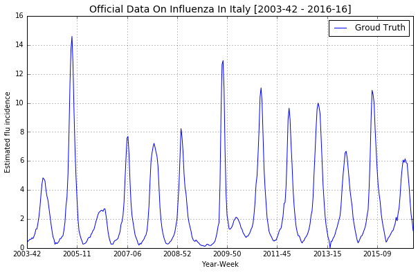

```python
gt_ts.plot(legend=True, label='Groud Truth')
plt.title('Official Data On Influenza In Italy ['+ min(gt_ts.index)+' - '+max(gt_ts.index)+']', fontsize=14)
plt.xlabel('Year-Week')
plt.ylabel('Estimated flu incidence')
plt.grid()
plt.show()
```

The period consider start from the 42th week's of 2011 and we reduce the ground truth series to this period.

```python
init_date = '2011-42'
gt_ts = gt_ts[init_date:]
```

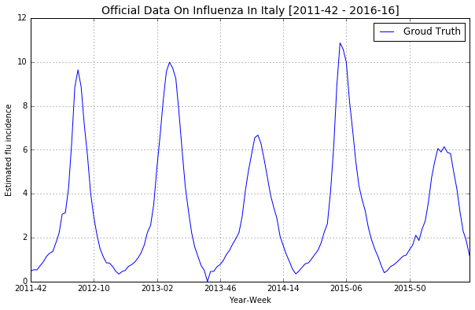

```python
gt_ts.plot(legend=True, label='Groud Truth')
plt.title('Official Data On Influenza In Italy ['+ min(gt_ts.index)+' - '+max(gt_ts.index)+']', fontsize=14)
plt.xlabel('Year-Week')
plt.ylabel('Estimated flu incidence')
plt.grid()
plt.show()
```

## Part 1.1

### Process the Wikipedia pageview data for the "Influenza" page of the Italian

Define a function to aggregate the pageviews on a weekly time scale. function strftime works on macOS an with the string "%G-%V" take the datetime and return the Year and Week in ISO calendar (the week start on Monday and the week beetween two years belong to the year with majority of its day - thursday is the tip of the balance)

```python
def hourlyToWeekly(filename, sep):
    ts = pd.Series.from_csv(filename, sep = sep, header=None, index_col = 0)
    wts = ts.groupby(ts.index.strftime("%G-%V")).sum()
    return wts
```

```python
df = pd.concat([hourlyToWeekly(f, ' ') for f in glob.glob(path + "/*.txt")], axis=1)
df = df.fillna(0)

df.columns = [os.path.basename(f).split('.')[0] for f in glob.glob(path + "/*.txt")]
```

```python
df["Influenzavirus_A_sottotipo_H1N1"] = df["Influenzavirus_A_sottotipo_H1N1"].add(df["Virus_dell'influenza_A_sottotipo_H1N1"], fill_value=0).add(df["Virus_dell%27influenza_A_sottotipo_H1N1"], fill_value=0)

del df["Virus_dell'influenza_A_sottotipo_H1N1"]
del df["Virus_dell%27influenza_A_sottotipo_H1N1"]
```

As explained in section 2 we merge the three series:

- *Influenzavirus_A_sottotipo_H1N1*
- *Virus_dell'influenza_A_sottotipo_H1N1*
- *Virus_dell%27influenza_A_sottotipo_H1N1* and delete the extra

```python
df_raw = df.copy()
df_raw
```

|  | Amantadina | Antivirale | Artralgia | Cefalea | Centro_europeo_per_la_prevenzione_e_il_controllo_delle_malattie | Epidemia | Febbre | Fotofobia | Influenza | Influenza_aviaria | ... | Pandemia_influenzale | Paracetamolo | Raffreddore_comune | Rinorrea | Starnuto | Tosse | totalViews | Vaccino_antinfluenzale | Vomito | Zanamivir |
| --- | --- | --- | --- | --- | --- | --- | --- | --- | --- | --- | --- | --- | --- | --- | --- | --- | --- | --- | --- | --- | --- |
| 2011-39 | 43 | 55 | 93 | 395 | 5 | 120 | 1054 | 108 | 244 | 101 | ... | 20 | 1112 | 491 | 68 | 153 | 377 | 27539912 | 0.0 | 481 | 12 |
| 2011-40 | 155 | 164 | 366 | 1582 | 28 | 355 | 3686 | 354 | 1083 | 326 | ... | 77 | 4078 | 1772 | 327 | 436 | 1351 | 118338276 | 0.0 | 1512 | 35 |
| 2011-41 | 155 | 174 | 396 | 1604 | 24 | 370 | 3502 | 386 | 1101 | 307 | ... | 106 | 4331 | 2095 | 333 | 499 | 1491 | 94647305 | 0.0 | 1659 | 49 |
| 2011-42 | 162 | 178 | 391 | 1526 | 51 | 378 | 3499 | 433 | 1176 | 276 | ... | 113 | 4485 | 1898 | 363 | 454 | 1663 | 93271823 | 0.0 | 1724 | 68 |
| 2011-43 | 183 | 210 | 385 | 1696 | 34 | 413 | 3696 | 463 | 1119 | 354 | ... | 83 | 4848 | 1747 | 352 | 454 | 1947 | 99364715 | 0.0 | 1825 | 67 |
| 2011-44 | 224 | 279 | 449 | 2074 | 27 | 433 | 3962 | 527 | 1309 | 298 | ... | 100 | 4973 | 1783 | 333 | 498 | 2211 | 108841801 | 0.0 | 2173 | 62 |
| 2011-45 | 221 | 248 | 466 | 2306 | 24 | 425 | 4158 | 616 | 1352 | 343 | ... | 93 | 4787 | 1545 | 369 | 483 | 2268 | 109836162 | 394.0 | 2118 | 55 |
| 2011-46 | 290 | 245 | 464 | 2009 | 39 | 450 | 4139 | 508 | 1420 | 371 | ... | 93 | 4935 | 1789 | 374 | 513 | 2140 | 106748952 | 826.0 | 2110 | 67 |
| 2011-47 | 252 | 297 | 437 | 2200 | 32 | 440 | 4367 | 576 | 1558 | 414 | ... | 117 | 6523 | 1830 | 375 | 564 | 2277 | 105517950 | 1129.0 | 2276 | 59 |
| 2011-48 | 243 | 280 | 462 | 2037 | 27 | 552 | 4403 | 506 | 1534 | 1470 | ... | 121 | 5040 | 1831 | 404 | 498 | 2179 | 103806835 | 761.0 | 2437 | 78 |
| 2011-49 | 185 | 230 | 439 | 1880 | 22 | 439 | 4161 | 469 | 1387 | 478 | ... | 92 | 4729 | 1566 | 367 | 498 | 2051 | 101174357 | 453.0 | 2152 | 94 |
| 2011-50 | 252 | 295 | 425 | 1937 | 26 | 422 | 4339 | 499 | 1463 | 438 | ... | 107 | 4900 | 1533 | 366 | 518 | 1935 | 104067037 | 345.0 | 2093 | 69 |
| 2011-51 | 124 | 150 | 213 | 902 | 16 | 234 | 2471 | 268 | 833 | 747 | ... | 70 | 3477 | 1141 | 168 | 285 | 1120 | 55305462 | 147.0 | 1188 | 35 |
| 2011-52 | 156 | 202 | 285 | 1317 | 18 | 263 | 4882 | 375 | 1588 | 604 | ... | 83 | 5972 | 1861 | 278 | 423 | 1935 | 90211318 | 160.0 | 2477 | 62 |
| 2012-01 | 236 | 307 | 455 | 1861 | 27 | 535 | 5952 | 528 | 2037 | 466 | ... | 140 | 6817 | 2352 | 425 | 643 | 2649 | 119823036 | 179.0 | 2726 | 73 |
| 2012-02 | 335 | 329 | 478 | 2062 | 24 | 513 | 5885 | 645 | 2083 | 525 | ... | 106 | 6363 | 2087 | 409 | 632 | 2782 | 116279474 | 197.0 | 2759 | 94 |
| 2012-03 | 313 | 282 | 455 | 1864 | 23 | 463 | 6320 | 487 | 2092 | 527 | ... | 115 | 6256 | 1865 | 375 | 565 | 2596 | 109904116 | 187.0 | 2506 | 84 |
| 2012-04 | 300 | 296 | 539 | 2102 | 26 | 550 | 6978 | 536 | 2507 | 527 | ... | 148 | 6208 | 2266 | 433 | 584 | 2787 | 115702289 | 199.0 | 2354 | 144 |
| 2012-05 | 312 | 342 | 532 | 1995 | 24 | 506 | 7657 | 483 | 2728 | 519 | ... | 149 | 6953 | 2229 | 434 | 619 | 2783 | 116246769 | 238.0 | 2338 | 179 |
| 2012-06 | 347 | 381 | 607 | 1963 | 24 | 505 | 7196 | 568 | 2282 | 492 | ... | 143 | 7028 | 2136 | 412 | 620 | 2595 | 119656983 | 190.0 | 2278 | 145 |
| 2012-07 | 327 | 366 | 564 | 1918 | 22 | 509 | 6971 | 551 | 2198 | 483 | ... | 97 | 6464 | 2142 | 390 | 580 | 2471 | 113809247 | 188.0 | 2611 | 128 |
| 2012-08 | 315 | 340 | 716 | 2079 | 25 | 495 | 7253 | 596 | 2237 | 446 | ... | 110 | 6043 | 2116 | 814 | 688 | 2345 | 112860742 | 174.0 | 2644 | 121 |
| 2012-09 | 236 | 309 | 538 | 2134 | 27 | 422 | 5741 | 556 | 1664 | 430 | ... | 117 | 5430 | 1893 | 408 | 664 | 2115 | 112172874 | 169.0 | 2599 | 73 |
| 2012-10 | 245 | 259 | 543 | 1652 | 27 | 398 | 5100 | 552 | 1161 | 458 | ... | 117 | 7008 | 1753 | 393 | 603 | 2088 | 107815827 | 120.0 | 2501 | 72 |
| 2012-11 | 178 | 278 | 579 | 1974 | 22 | 538 | 4163 | 624 | 1198 | 435 | ... | 396 | 4183 | 1564 | 424 | 521 | 1748 | 101505308 | 134.0 | 2068 | 78 |
| 2012-12 | 166 | 255 | 516 | 1767 | 24 | 418 | 3828 | 553 | 938 | 356 | ... | 128 | 3471 | 1320 | 400 | 489 | 1280 | 99418248 | 90.0 | 1806 | 56 |
| 2012-13 | 178 | 291 | 625 | 1750 | 23 | 426 | 3295 | 580 | 1019 | 368 | ... | 100 | 3626 | 1246 | 429 | 528 | 1042 | 99082137 | 80.0 | 1677 | 69 |
| 2012-14 | 213 | 244 | 514 | 1632 | 27 | 415 | 3116 | 480 | 782 | 372 | ... | 76 | 3246 | 961 | 344 | 502 | 990 | 97879780 | 76.0 | 1650 | 47 |
| 2012-15 | 198 | 267 | 544 | 1751 | 58 | 468 | 3283 | 547 | 811 | 385 | ... | 112 | 3743 | 1106 | 364 | 448 | 1013 | 107373915 | 80.0 | 1978 | 54 |
| 2012-16 | 220 | 275 | 617 | 1900 | 27 | 460 | 3952 | 588 | 872 | 390 | ... | 112 | 3817 | 1074 | 345 | 414 | 1026 | 106949016 | 94.0 | 2063 | 62 |
| ... | ... | ... | ... | ... | ... | ... | ... | ... | ... | ... | ... | ... | ... | ... | ... | ... | ... | ... | ... | ... | ... |
| 2015-41 | 109 | 104 | 459 | 755 | 25 | 277 | 861 | 354 | 642 | 202 | ... | 62 | 1984 | 1039 | 161 | 207 | 352 | 54469589 | 188.0 | 444 | 24 |
| 2015-42 | 99 | 150 | 299 | 663 | 28 | 194 | 892 | 204 | 530 | 175 | ... | 43 | 1995 | 922 | 197 | 211 | 348 | 52542024 | 291.0 | 445 | 21 |
| 2015-43 | 123 | 115 | 208 | 684 | 19 | 229 | 895 | 204 | 507 | 183 | ... | 48 | 1879 | 787 | 147 | 186 | 345 | 49880045 | 316.0 | 416 | 18 |
| 2015-44 | 127 | 105 | 253 | 648 | 14 | 220 | 825 | 200 | 479 | 300 | ... | 64 | 1805 | 607 | 137 | 182 | 388 | 49865506 | 273.0 | 423 | 23 |
| 2015-45 | 119 | 117 | 249 | 744 | 27 | 274 | 847 | 200 | 576 | 198 | ... | 60 | 1881 | 606 | 163 | 182 | 360 | 52650244 | 358.0 | 442 | 31 |
| 2015-46 | 156 | 107 | 222 | 718 | 17 | 217 | 832 | 202 | 549 | 180 | ... | 58 | 1728 | 523 | 148 | 186 | 409 | 53722960 | 383.0 | 485 | 38 |
| 2015-47 | 137 | 242 | 199 | 635 | 14 | 210 | 909 | 236 | 532 | 181 | ... | 42 | 1880 | 480 | 163 | 156 | 339 | 55196890 | 413.0 | 448 | 35 |
| 2015-48 | 145 | 117 | 218 | 687 | 23 | 214 | 957 | 212 | 570 | 215 | ... | 68 | 1791 | 586 | 153 | 197 | 308 | 53103330 | 328.0 | 441 | 29 |
| 2015-49 | 134 | 129 | 206 | 625 | 17 | 187 | 924 | 175 | 563 | 307 | ... | 48 | 2335 | 604 | 144 | 184 | 328 | 51818693 | 251.0 | 429 | 22 |
| 2015-50 | 133 | 111 | 202 | 636 | 25 | 165 | 970 | 177 | 525 | 197 | ... | 47 | 2056 | 575 | 186 | 214 | 323 | 50784272 | 156.0 | 434 | 69 |
| 2015-51 | 141 | 130 | 211 | 576 | 23 | 167 | 881 | 163 | 580 | 137 | ... | 68 | 1923 | 648 | 174 | 269 | 326 | 49134283 | 110.0 | 397 | 39 |
| 2015-52 | 65 | 110 | 132 | 395 | 17 | 96 | 661 | 145 | 422 | 91 | ... | 42 | 1673 | 554 | 122 | 158 | 286 | 41918624 | 85.0 | 298 | 20 |
| 2015-53 | 107 | 106 | 168 | 517 | 18 | 157 | 899 | 139 | 525 | 227 | ... | 58 | 1942 | 788 | 169 | 182 | 336 | 48141667 | 62.0 | 477 | 32 |
| 2016-01 | 128 | 126 | 226 | 591 | 45 | 199 | 1155 | 187 | 660 | 197 | ... | 64 | 2154 | 936 | 226 | 242 | 395 | 59225424 | 83.0 | 484 | 32 |
| 2016-02 | 157 | 160 | 271 | 670 | 23 | 244 | 1133 | 244 | 753 | 297 | ... | 65 | 2191 | 771 | 212 | 218 | 476 | 60808188 | 85.0 | 555 | 37 |
| 2016-03 | 194 | 164 | 266 | 744 | 17 | 264 | 1086 | 219 | 751 | 212 | ... | 69 | 2083 | 805 | 185 | 269 | 411 | 59441516 | 95.0 | 481 | 40 |
| 2016-04 | 185 | 158 | 310 | 795 | 20 | 291 | 1284 | 230 | 702 | 264 | ... | 82 | 2295 | 852 | 229 | 287 | 388 | 58728254 | 85.0 | 541 | 47 |
| 2016-05 | 177 | 165 | 312 | 871 | 19 | 290 | 1510 | 219 | 793 | 260 | ... | 79 | 2313 | 820 | 240 | 267 | 403 | 59952557 | 94.0 | 530 | 48 |
| 2016-06 | 188 | 178 | 278 | 827 | 25 | 348 | 1367 | 297 | 804 | 248 | ... | 99 | 2420 | 751 | 218 | 268 | 429 | 60372242 | 77.0 | 492 | 41 |
| 2016-07 | 222 | 163 | 297 | 806 | 17 | 784 | 1421 | 275 | 776 | 298 | ... | 68 | 2215 | 688 | 200 | 297 | 443 | 59536013 | 79.0 | 506 | 42 |
| 2016-08 | 165 | 181 | 309 | 761 | 16 | 467 | 1421 | 214 | 778 | 241 | ... | 83 | 2291 | 657 | 200 | 276 | 416 | 57084524 | 67.0 | 473 | 29 |
| 2016-09 | 136 | 154 | 269 | 774 | 28 | 255 | 1282 | 251 | 676 | 263 | ... | 124 | 2079 | 575 | 187 | 227 | 378 | 59638966 | 40.0 | 440 | 30 |
| 2016-10 | 129 | 170 | 259 | 804 | 17 | 247 | 1309 | 248 | 691 | 226 | ... | 65 | 2020 | 497 | 194 | 221 | 391 | 56797538 | 52.0 | 478 | 32 |
| 2016-11 | 155 | 136 | 263 | 717 | 27 | 207 | 1267 | 227 | 757 | 222 | ... | 56 | 2024 | 519 | 172 | 197 | 352 | 56949096 | 46.0 | 441 | 43 |
| 2016-12 | 125 | 157 | 202 | 665 | 19 | 179 | 1078 | 169 | 637 | 158 | ... | 51 | 1723 | 411 | 196 | 207 | 290 | 56824960 | 48.0 | 372 | 26 |
| 2016-13 | 118 | 127 | 249 | 652 | 19 | 250 | 1042 | 221 | 777 | 241 | ... | 42 | 1661 | 598 | 179 | 220 | 272 | 58237823 | 75.0 | 403 | 23 |
| 2016-14 | 106 | 152 | 249 | 708 | 26 | 213 | 940 | 222 | 544 | 218 | ... | 51 | 1879 | 427 | 183 | 192 | 273 | 53090047 | 60.0 | 394 | 43 |
| 2016-15 | 105 | 132 | 261 | 723 | 29 | 237 | 936 | 212 | 465 | 190 | ... | 38 | 1572 | 415 | 149 | 208 | 316 | 50953039 | 41.0 | 358 | 28 |
| 2016-16 | 136 | 164 | 258 | 615 | 25 | 182 | 793 | 229 | 467 | 196 | ... | 58 | 1515 | 424 | 181 | 232 | 256 | 53964932 | 50.0 | 386 | 25 |
| 2016-17 | 132 | 116 | 214 | 560 | 13 | 214 | 726 | 168 | 395 | 336 | ... | 44 | 1514 | 399 | 125 | 147 | 192 | 46426870 | 53.0 | 338 | 18 |

156 rows × 25 columns

The series are downloaded from the beginning of October to the end of April. But the Influnet series are a subset! To compare the two time series, we exctract a subset from the wikipedia data with indexes given by the ground truth.

```python
init_date = min(set(df.index) & set(gt_ts.index))
init_date
```

```
'2011-42'
```

```python
gt_ts = gt_ts[init_date:]
```

```python
df = df.loc[gt_ts.index]
```

```python
df_tot = pd.concat([df, gt_ts], axis=1)
```

Make a dataframe with all the keywords and the ground truth.

```python
names = list(df.columns.values)
names.append('GroundTruth')
df_tot.columns = names
df_tot
```

|  | Amantadina | Antivirale | Artralgia | Cefalea | Centro_europeo_per_la_prevenzione_e_il_controllo_delle_malattie | Epidemia | Febbre | Fotofobia | Influenza | Influenza_aviaria | ... | Paracetamolo | Raffreddore_comune | Rinorrea | Starnuto | Tosse | totalViews | Vaccino_antinfluenzale | Vomito | Zanamivir | GroundTruth |
| --- | --- | --- | --- | --- | --- | --- | --- | --- | --- | --- | --- | --- | --- | --- | --- | --- | --- | --- | --- | --- | --- |
| 2011-42 | 162 | 178 | 391 | 1526 | 51 | 378 | 3499 | 433 | 1176 | 276 | ... | 4485 | 1898 | 363 | 454 | 1663 | 93271823 | 0.0 | 1724 | 68 | 0.47 |
| 2011-43 | 183 | 210 | 385 | 1696 | 34 | 413 | 3696 | 463 | 1119 | 354 | ... | 4848 | 1747 | 352 | 454 | 1947 | 99364715 | 0.0 | 1825 | 67 | 0.54 |
| 2011-44 | 224 | 279 | 449 | 2074 | 27 | 433 | 3962 | 527 | 1309 | 298 | ... | 4973 | 1783 | 333 | 498 | 2211 | 108841801 | 0.0 | 2173 | 62 | 0.53 |
| 2011-45 | 221 | 248 | 466 | 2306 | 24 | 425 | 4158 | 616 | 1352 | 343 | ... | 4787 | 1545 | 369 | 483 | 2268 | 109836162 | 394.0 | 2118 | 55 | 0.72 |
| 2011-46 | 290 | 245 | 464 | 2009 | 39 | 450 | 4139 | 508 | 1420 | 371 | ... | 4935 | 1789 | 374 | 513 | 2140 | 106748952 | 826.0 | 2110 | 67 | 0.89 |
| 2011-47 | 252 | 297 | 437 | 2200 | 32 | 440 | 4367 | 576 | 1558 | 414 | ... | 6523 | 1830 | 375 | 564 | 2277 | 105517950 | 1129.0 | 2276 | 59 | 1.14 |
| 2011-48 | 243 | 280 | 462 | 2037 | 27 | 552 | 4403 | 506 | 1534 | 1470 | ... | 5040 | 1831 | 404 | 498 | 2179 | 103806835 | 761.0 | 2437 | 78 | 1.29 |
| 2011-49 | 185 | 230 | 439 | 1880 | 22 | 439 | 4161 | 469 | 1387 | 478 | ... | 4729 | 1566 | 367 | 498 | 2051 | 101174357 | 453.0 | 2152 | 94 | 1.36 |
| 2011-50 | 252 | 295 | 425 | 1937 | 26 | 422 | 4339 | 499 | 1463 | 438 | ... | 4900 | 1533 | 366 | 518 | 1935 | 104067037 | 345.0 | 2093 | 69 | 1.76 |
| 2011-51 | 124 | 150 | 213 | 902 | 16 | 234 | 2471 | 268 | 833 | 747 | ... | 3477 | 1141 | 168 | 285 | 1120 | 55305462 | 147.0 | 1188 | 35 | 2.20 |
| 2011-52 | 156 | 202 | 285 | 1317 | 18 | 263 | 4882 | 375 | 1588 | 604 | ... | 5972 | 1861 | 278 | 423 | 1935 | 90211318 | 160.0 | 2477 | 62 | 3.07 |
| 2012-01 | 236 | 307 | 455 | 1861 | 27 | 535 | 5952 | 528 | 2037 | 466 | ... | 6817 | 2352 | 425 | 643 | 2649 | 119823036 | 179.0 | 2726 | 73 | 3.13 |
| 2012-02 | 335 | 329 | 478 | 2062 | 24 | 513 | 5885 | 645 | 2083 | 525 | ... | 6363 | 2087 | 409 | 632 | 2782 | 116279474 | 197.0 | 2759 | 94 | 4.24 |
| 2012-03 | 313 | 282 | 455 | 1864 | 23 | 463 | 6320 | 487 | 2092 | 527 | ... | 6256 | 1865 | 375 | 565 | 2596 | 109904116 | 187.0 | 2506 | 84 | 6.30 |
| 2012-04 | 300 | 296 | 539 | 2102 | 26 | 550 | 6978 | 536 | 2507 | 527 | ... | 6208 | 2266 | 433 | 584 | 2787 | 115702289 | 199.0 | 2354 | 144 | 8.86 |
| 2012-05 | 312 | 342 | 532 | 1995 | 24 | 506 | 7657 | 483 | 2728 | 519 | ... | 6953 | 2229 | 434 | 619 | 2783 | 116246769 | 238.0 | 2338 | 179 | 9.64 |
| 2012-06 | 347 | 381 | 607 | 1963 | 24 | 505 | 7196 | 568 | 2282 | 492 | ... | 7028 | 2136 | 412 | 620 | 2595 | 119656983 | 190.0 | 2278 | 145 | 8.87 |
| 2012-07 | 327 | 366 | 564 | 1918 | 22 | 509 | 6971 | 551 | 2198 | 483 | ... | 6464 | 2142 | 390 | 580 | 2471 | 113809247 | 188.0 | 2611 | 128 | 7.14 |
| 2012-08 | 315 | 340 | 716 | 2079 | 25 | 495 | 7253 | 596 | 2237 | 446 | ... | 6043 | 2116 | 814 | 688 | 2345 | 112860742 | 174.0 | 2644 | 121 | 5.75 |
| 2012-09 | 236 | 309 | 538 | 2134 | 27 | 422 | 5741 | 556 | 1664 | 430 | ... | 5430 | 1893 | 408 | 664 | 2115 | 112172874 | 169.0 | 2599 | 73 | 4.03 |
| 2012-10 | 245 | 259 | 543 | 1652 | 27 | 398 | 5100 | 552 | 1161 | 458 | ... | 7008 | 1753 | 393 | 603 | 2088 | 107815827 | 120.0 | 2501 | 72 | 2.95 |
| 2012-11 | 178 | 278 | 579 | 1974 | 22 | 538 | 4163 | 624 | 1198 | 435 | ... | 4183 | 1564 | 424 | 521 | 1748 | 101505308 | 134.0 | 2068 | 78 | 2.13 |
| 2012-12 | 166 | 255 | 516 | 1767 | 24 | 418 | 3828 | 553 | 938 | 356 | ... | 3471 | 1320 | 400 | 489 | 1280 | 99418248 | 90.0 | 1806 | 56 | 1.49 |
| 2012-13 | 178 | 291 | 625 | 1750 | 23 | 426 | 3295 | 580 | 1019 | 368 | ... | 3626 | 1246 | 429 | 528 | 1042 | 99082137 | 80.0 | 1677 | 69 | 1.13 |
| 2012-14 | 213 | 244 | 514 | 1632 | 27 | 415 | 3116 | 480 | 782 | 372 | ... | 3246 | 961 | 344 | 502 | 990 | 97879780 | 76.0 | 1650 | 47 | 0.85 |
| 2012-15 | 198 | 267 | 544 | 1751 | 58 | 468 | 3283 | 547 | 811 | 385 | ... | 3743 | 1106 | 364 | 448 | 1013 | 107373915 | 80.0 | 1978 | 54 | 0.84 |
| 2012-16 | 220 | 275 | 617 | 1900 | 27 | 460 | 3952 | 588 | 872 | 390 | ... | 3817 | 1074 | 345 | 414 | 1026 | 106949016 | 94.0 | 2063 | 62 | 0.68 |
| 2012-17 | 184 | 274 | 676 | 1686 | 24 | 503 | 3737 | 505 | 728 | 358 | ... | 4075 | 991 | 399 | 458 | 1011 | 102745188 | 82.0 | 1942 | 53 | 0.46 |
| 2012-42 | 228 | 337 | 591 | 2483 | 18 | 462 | 4226 | 595 | 1587 | 633 | ... | 5797 | 1868 | 401 | 705 | 1283 | 121540632 | 750.0 | 1986 | 68 | 0.34 |
| 2012-43 | 244 | 272 | 586 | 2599 | 25 | 468 | 4192 | 588 | 1606 | 589 | ... | 5735 | 2309 | 359 | 738 | 1402 | 122132429 | 1061.0 | 2021 | 68 | 0.46 |
| ... | ... | ... | ... | ... | ... | ... | ... | ... | ... | ... | ... | ... | ... | ... | ... | ... | ... | ... | ... | ... | ... |
| 2015-16 | 154 | 172 | 527 | 954 | 73 | 328 | 1168 | 317 | 579 | 303 | ... | 2073 | 617 | 242 | 307 | 505 | 79865047 | 82.0 | 667 | 46 | 1.15 |
| 2015-17 | 151 | 207 | 367 | 987 | 57 | 311 | 1089 | 349 | 560 | 273 | ... | 1843 | 612 | 208 | 308 | 370 | 80843535 | 100.0 | 695 | 51 | 0.75 |
| 2015-42 | 99 | 150 | 299 | 663 | 28 | 194 | 892 | 204 | 530 | 175 | ... | 1995 | 922 | 197 | 211 | 348 | 52542024 | 291.0 | 445 | 21 | 0.40 |
| 2015-43 | 123 | 115 | 208 | 684 | 19 | 229 | 895 | 204 | 507 | 183 | ... | 1879 | 787 | 147 | 186 | 345 | 49880045 | 316.0 | 416 | 18 | 0.50 |
| 2015-44 | 127 | 105 | 253 | 648 | 14 | 220 | 825 | 200 | 479 | 300 | ... | 1805 | 607 | 137 | 182 | 388 | 49865506 | 273.0 | 423 | 23 | 0.68 |
| 2015-45 | 119 | 117 | 249 | 744 | 27 | 274 | 847 | 200 | 576 | 198 | ... | 1881 | 606 | 163 | 182 | 360 | 52650244 | 358.0 | 442 | 31 | 0.76 |
| 2015-46 | 156 | 107 | 222 | 718 | 17 | 217 | 832 | 202 | 549 | 180 | ... | 1728 | 523 | 148 | 186 | 409 | 53722960 | 383.0 | 485 | 38 | 0.88 |
| 2015-47 | 137 | 242 | 199 | 635 | 14 | 210 | 909 | 236 | 532 | 181 | ... | 1880 | 480 | 163 | 156 | 339 | 55196890 | 413.0 | 448 | 35 | 1.02 |
| 2015-48 | 145 | 117 | 218 | 687 | 23 | 214 | 957 | 212 | 570 | 215 | ... | 1791 | 586 | 153 | 197 | 308 | 53103330 | 328.0 | 441 | 29 | 1.16 |
| 2015-49 | 134 | 129 | 206 | 625 | 17 | 187 | 924 | 175 | 563 | 307 | ... | 2335 | 604 | 144 | 184 | 328 | 51818693 | 251.0 | 429 | 22 | 1.21 |
| 2015-50 | 133 | 111 | 202 | 636 | 25 | 165 | 970 | 177 | 525 | 197 | ... | 2056 | 575 | 186 | 214 | 323 | 50784272 | 156.0 | 434 | 69 | 1.45 |
| 2015-51 | 141 | 130 | 211 | 576 | 23 | 167 | 881 | 163 | 580 | 137 | ... | 1923 | 648 | 174 | 269 | 326 | 49134283 | 110.0 | 397 | 39 | 1.66 |
| 2015-52 | 65 | 110 | 132 | 395 | 17 | 96 | 661 | 145 | 422 | 91 | ... | 1673 | 554 | 122 | 158 | 286 | 41918624 | 85.0 | 298 | 20 | 2.11 |
| 2015-53 | 107 | 106 | 168 | 517 | 18 | 157 | 899 | 139 | 525 | 227 | ... | 1942 | 788 | 169 | 182 | 336 | 48141667 | 62.0 | 477 | 32 | 1.87 |
| 2016-01 | 128 | 126 | 226 | 591 | 45 | 199 | 1155 | 187 | 660 | 197 | ... | 2154 | 936 | 226 | 242 | 395 | 59225424 | 83.0 | 484 | 32 | 2.39 |
| 2016-02 | 157 | 160 | 271 | 670 | 23 | 244 | 1133 | 244 | 753 | 297 | ... | 2191 | 771 | 212 | 218 | 476 | 60808188 | 85.0 | 555 | 37 | 2.76 |
| 2016-03 | 194 | 164 | 266 | 744 | 17 | 264 | 1086 | 219 | 751 | 212 | ... | 2083 | 805 | 185 | 269 | 411 | 59441516 | 95.0 | 481 | 40 | 3.62 |
| 2016-04 | 185 | 158 | 310 | 795 | 20 | 291 | 1284 | 230 | 702 | 264 | ... | 2295 | 852 | 229 | 287 | 388 | 58728254 | 85.0 | 541 | 47 | 4.73 |
| 2016-05 | 177 | 165 | 312 | 871 | 19 | 290 | 1510 | 219 | 793 | 260 | ... | 2313 | 820 | 240 | 267 | 403 | 59952557 | 94.0 | 530 | 48 | 5.47 |
| 2016-06 | 188 | 178 | 278 | 827 | 25 | 348 | 1367 | 297 | 804 | 248 | ... | 2420 | 751 | 218 | 268 | 429 | 60372242 | 77.0 | 492 | 41 | 6.06 |
| 2016-07 | 222 | 163 | 297 | 806 | 17 | 784 | 1421 | 275 | 776 | 298 | ... | 2215 | 688 | 200 | 297 | 443 | 59536013 | 79.0 | 506 | 42 | 5.90 |
| 2016-08 | 165 | 181 | 309 | 761 | 16 | 467 | 1421 | 214 | 778 | 241 | ... | 2291 | 657 | 200 | 276 | 416 | 57084524 | 67.0 | 473 | 29 | 6.14 |
| 2016-09 | 136 | 154 | 269 | 774 | 28 | 255 | 1282 | 251 | 676 | 263 | ... | 2079 | 575 | 187 | 227 | 378 | 59638966 | 40.0 | 440 | 30 | 5.88 |
| 2016-10 | 129 | 170 | 259 | 804 | 17 | 247 | 1309 | 248 | 691 | 226 | ... | 2020 | 497 | 194 | 221 | 391 | 56797538 | 52.0 | 478 | 32 | 5.83 |
| 2016-11 | 155 | 136 | 263 | 717 | 27 | 207 | 1267 | 227 | 757 | 222 | ... | 2024 | 519 | 172 | 197 | 352 | 56949096 | 46.0 | 441 | 43 | 5.00 |
| 2016-12 | 125 | 157 | 202 | 665 | 19 | 179 | 1078 | 169 | 637 | 158 | ... | 1723 | 411 | 196 | 207 | 290 | 56824960 | 48.0 | 372 | 26 | 4.23 |
| 2016-13 | 118 | 127 | 249 | 652 | 19 | 250 | 1042 | 221 | 777 | 241 | ... | 1661 | 598 | 179 | 220 | 272 | 58237823 | 75.0 | 403 | 23 | 3.18 |
| 2016-14 | 106 | 152 | 249 | 708 | 26 | 213 | 940 | 222 | 544 | 218 | ... | 1879 | 427 | 183 | 192 | 273 | 53090047 | 60.0 | 394 | 43 | 2.30 |
| 2016-15 | 105 | 132 | 261 | 723 | 29 | 237 | 936 | 212 | 465 | 190 | ... | 1572 | 415 | 149 | 208 | 316 | 50953039 | 41.0 | 358 | 28 | 1.85 |
| 2016-16 | 136 | 164 | 258 | 615 | 25 | 182 | 793 | 229 | 467 | 196 | ... | 1515 | 424 | 181 | 232 | 256 | 53964932 | 50.0 | 386 | 25 | 1.19 |

140 rows × 26 columns

If we consider only the views is a good idea, but a better idea is to divide the views by the total views. This is done because the series could be affected by a trend of an increase use of wikipedia (to consult).

```python
df_norm = df.divide(df['totalViews'], axis='index')
```

```python
del df_norm['totalViews']
df_norm
```

|  | Amantadina | Antivirale | Artralgia | Cefalea | Centro_europeo_per_la_prevenzione_e_il_controllo_delle_malattie | Epidemia | Febbre | Fotofobia | Influenza | Influenza_aviaria | ... | Oseltamivir | Pandemia_influenzale | Paracetamolo | Raffreddore_comune | Rinorrea | Starnuto | Tosse | Vaccino_antinfluenzale | Vomito | Zanamivir |
| --- | --- | --- | --- | --- | --- | --- | --- | --- | --- | --- | --- | --- | --- | --- | --- | --- | --- | --- | --- | --- | --- |
| 2011-42 | 0.000002 | 0.000002 | 0.000004 | 0.000016 | 5.467889e-07 | 0.000004 | 0.000038 | 0.000005 | 0.000013 | 0.000003 | ... | 1.072135e-06 | 1.211513e-06 | 0.000048 | 0.000020 | 0.000004 | 0.000005 | 0.000018 | 0.000000e+00 | 0.000018 | 7.290519e-07 |
| 2011-43 | 0.000002 | 0.000002 | 0.000004 | 0.000017 | 3.421738e-07 | 0.000004 | 0.000037 | 0.000005 | 0.000011 | 0.000004 | ... | 1.177480e-06 | 8.353066e-07 | 0.000049 | 0.000018 | 0.000004 | 0.000005 | 0.000020 | 0.000000e+00 | 0.000018 | 6.742836e-07 |
| 2011-44 | 0.000002 | 0.000003 | 0.000004 | 0.000019 | 2.480665e-07 | 0.000004 | 0.000036 | 0.000005 | 0.000012 | 0.000003 | ... | 1.093330e-06 | 9.187647e-07 | 0.000046 | 0.000016 | 0.000003 | 0.000005 | 0.000020 | 0.000000e+00 | 0.000020 | 5.696341e-07 |
| 2011-45 | 0.000002 | 0.000002 | 0.000004 | 0.000021 | 2.185073e-07 | 0.000004 | 0.000038 | 0.000006 | 0.000012 | 0.000003 | ... | 1.083432e-06 | 8.467157e-07 | 0.000044 | 0.000014 | 0.000003 | 0.000004 | 0.000021 | 3.587161e-06 | 0.000019 | 5.007458e-07 |
| 2011-46 | 0.000003 | 0.000002 | 0.000004 | 0.000019 | 3.653432e-07 | 0.000004 | 0.000039 | 0.000005 | 0.000013 | 0.000003 | ... | 1.152236e-06 | 8.712029e-07 | 0.000046 | 0.000017 | 0.000004 | 0.000005 | 0.000020 | 7.737781e-06 | 0.000020 | 6.276408e-07 |
| 2011-47 | 0.000002 | 0.000003 | 0.000004 | 0.000021 | 3.032659e-07 | 0.000004 | 0.000041 | 0.000005 | 0.000015 | 0.000004 | ... | 1.298357e-06 | 1.108816e-06 | 0.000062 | 0.000017 | 0.000004 | 0.000005 | 0.000022 | 1.069960e-05 | 0.000022 | 5.591466e-07 |
| 2011-48 | 0.000002 | 0.000003 | 0.000004 | 0.000020 | 2.600985e-07 | 0.000005 | 0.000042 | 0.000005 | 0.000015 | 0.000014 | ... | 1.165627e-06 | 1.165627e-06 | 0.000049 | 0.000018 | 0.000004 | 0.000005 | 0.000021 | 7.330924e-06 | 0.000023 | 7.513956e-07 |
| 2011-49 | 0.000002 | 0.000002 | 0.000004 | 0.000019 | 2.174464e-07 | 0.000004 | 0.000041 | 0.000005 | 0.000014 | 0.000005 | ... | 1.591312e-06 | 9.093213e-07 | 0.000047 | 0.000015 | 0.000004 | 0.000005 | 0.000020 | 4.477419e-06 | 0.000021 | 9.290892e-07 |
| 2011-50 | 0.000002 | 0.000003 | 0.000004 | 0.000019 | 2.498390e-07 | 0.000004 | 0.000042 | 0.000005 | 0.000014 | 0.000004 | ... | 1.201149e-06 | 1.028183e-06 | 0.000047 | 0.000015 | 0.000004 | 0.000005 | 0.000019 | 3.315171e-06 | 0.000020 | 6.630342e-07 |
| 2011-51 | 0.000002 | 0.000003 | 0.000004 | 0.000016 | 2.893023e-07 | 0.000004 | 0.000045 | 0.000005 | 0.000015 | 0.000014 | ... | 1.464593e-06 | 1.265698e-06 | 0.000063 | 0.000021 | 0.000003 | 0.000005 | 0.000020 | 2.657965e-06 | 0.000021 | 6.328489e-07 |
| 2011-52 | 0.000002 | 0.000002 | 0.000003 | 0.000015 | 1.995315e-07 | 0.000003 | 0.000054 | 0.000004 | 0.000018 | 0.000007 | ... | 1.241529e-06 | 9.200619e-07 | 0.000066 | 0.000021 | 0.000003 | 0.000005 | 0.000021 | 1.773613e-06 | 0.000027 | 6.872752e-07 |
| 2012-01 | 0.000002 | 0.000003 | 0.000004 | 0.000016 | 2.253323e-07 | 0.000004 | 0.000050 | 0.000004 | 0.000017 | 0.000004 | ... | 1.293574e-06 | 1.168390e-06 | 0.000057 | 0.000020 | 0.000004 | 0.000005 | 0.000022 | 1.493870e-06 | 0.000023 | 6.092318e-07 |
| 2012-02 | 0.000003 | 0.000003 | 0.000004 | 0.000018 | 2.063993e-07 | 0.000004 | 0.000051 | 0.000006 | 0.000018 | 0.000005 | ... | 1.496395e-06 | 9.115968e-07 | 0.000055 | 0.000018 | 0.000004 | 0.000005 | 0.000024 | 1.694194e-06 | 0.000024 | 8.083972e-07 |
| 2012-03 | 0.000003 | 0.000003 | 0.000004 | 0.000017 | 2.092733e-07 | 0.000004 | 0.000058 | 0.000004 | 0.000019 | 0.000005 | ... | 2.211018e-06 | 1.046367e-06 | 0.000057 | 0.000017 | 0.000003 | 0.000005 | 0.000024 | 1.701483e-06 | 0.000023 | 7.643026e-07 |
| 2012-04 | 0.000003 | 0.000003 | 0.000005 | 0.000018 | 2.247147e-07 | 0.000005 | 0.000060 | 0.000005 | 0.000022 | 0.000005 | ... | 2.229861e-06 | 1.279145e-06 | 0.000054 | 0.000020 | 0.000004 | 0.000005 | 0.000024 | 1.719931e-06 | 0.000020 | 1.244573e-06 |
| 2012-05 | 0.000003 | 0.000003 | 0.000005 | 0.000017 | 2.064574e-07 | 0.000004 | 0.000066 | 0.000004 | 0.000023 | 0.000004 | ... | 2.511898e-06 | 1.281756e-06 | 0.000060 | 0.000019 | 0.000004 | 0.000005 | 0.000024 | 2.047369e-06 | 0.000020 | 1.539828e-06 |
| 2012-06 | 0.000003 | 0.000003 | 0.000005 | 0.000016 | 2.005733e-07 | 0.000004 | 0.000060 | 0.000005 | 0.000019 | 0.000004 | ... | 2.189592e-06 | 1.195083e-06 | 0.000059 | 0.000018 | 0.000003 | 0.000005 | 0.000022 | 1.587872e-06 | 0.000019 | 1.211797e-06 |
| 2012-07 | 0.000003 | 0.000003 | 0.000005 | 0.000017 | 1.933059e-07 | 0.000004 | 0.000061 | 0.000005 | 0.000019 | 0.000004 | ... | 1.941846e-06 | 8.523033e-07 | 0.000057 | 0.000019 | 0.000003 | 0.000005 | 0.000022 | 1.651887e-06 | 0.000023 | 1.124689e-06 |
| 2012-08 | 0.000003 | 0.000003 | 0.000006 | 0.000018 | 2.215119e-07 | 0.000004 | 0.000064 | 0.000005 | 0.000020 | 0.000004 | ... | 1.745514e-06 | 9.746525e-07 | 0.000054 | 0.000019 | 0.000007 | 0.000006 | 0.000021 | 1.541723e-06 | 0.000023 | 1.072118e-06 |
| 2012-09 | 0.000002 | 0.000003 | 0.000005 | 0.000019 | 2.406999e-07 | 0.000004 | 0.000051 | 0.000005 | 0.000015 | 0.000004 | ... | 1.283733e-06 | 1.043033e-06 | 0.000048 | 0.000017 | 0.000004 | 0.000006 | 0.000019 | 1.506603e-06 | 0.000023 | 6.507812e-07 |
| 2012-10 | 0.000002 | 0.000002 | 0.000005 | 0.000015 | 2.504271e-07 | 0.000004 | 0.000047 | 0.000005 | 0.000011 | 0.000004 | ... | 9.553328e-07 | 1.085184e-06 | 0.000065 | 0.000016 | 0.000004 | 0.000006 | 0.000019 | 1.113009e-06 | 0.000023 | 6.678055e-07 |
| 2012-11 | 0.000002 | 0.000003 | 0.000006 | 0.000019 | 2.167374e-07 | 0.000005 | 0.000041 | 0.000006 | 0.000012 | 0.000004 | ... | 1.073835e-06 | 3.901274e-06 | 0.000041 | 0.000015 | 0.000004 | 0.000005 | 0.000017 | 1.320128e-06 | 0.000020 | 7.684327e-07 |
| 2012-12 | 0.000002 | 0.000003 | 0.000005 | 0.000018 | 2.414044e-07 | 0.000004 | 0.000039 | 0.000006 | 0.000009 | 0.000004 | ... | 1.015910e-06 | 1.287490e-06 | 0.000035 | 0.000013 | 0.000004 | 0.000005 | 0.000013 | 9.052664e-07 | 0.000018 | 5.632769e-07 |
| 2012-13 | 0.000002 | 0.000003 | 0.000006 | 0.000018 | 2.321306e-07 | 0.000004 | 0.000033 | 0.000006 | 0.000010 | 0.000004 | ... | 1.049634e-06 | 1.009264e-06 | 0.000037 | 0.000013 | 0.000004 | 0.000005 | 0.000011 | 8.074109e-07 | 0.000017 | 6.963919e-07 |
| 2012-14 | 0.000002 | 0.000002 | 0.000005 | 0.000017 | 2.758486e-07 | 0.000004 | 0.000032 | 0.000005 | 0.000008 | 0.000004 | ... | 9.501452e-07 | 7.764627e-07 | 0.000033 | 0.000010 | 0.000004 | 0.000005 | 0.000010 | 7.764627e-07 | 0.000017 | 4.801809e-07 |
| 2012-15 | 0.000002 | 0.000002 | 0.000005 | 0.000016 | 5.401684e-07 | 0.000004 | 0.000031 | 0.000005 | 0.000008 | 0.000004 | ... | 6.984937e-07 | 1.043084e-06 | 0.000035 | 0.000010 | 0.000003 | 0.000004 | 0.000009 | 7.450599e-07 | 0.000018 | 5.029154e-07 |
| 2012-16 | 0.000002 | 0.000003 | 0.000006 | 0.000018 | 2.524567e-07 | 0.000004 | 0.000037 | 0.000005 | 0.000008 | 0.000004 | ... | 1.000477e-06 | 1.047228e-06 | 0.000036 | 0.000010 | 0.000003 | 0.000004 | 0.000010 | 8.789235e-07 | 0.000019 | 5.797155e-07 |
| 2012-17 | 0.000002 | 0.000003 | 0.000007 | 0.000016 | 2.335876e-07 | 0.000005 | 0.000036 | 0.000005 | 0.000007 | 0.000003 | ... | 7.396940e-07 | 1.109541e-06 | 0.000040 | 0.000010 | 0.000004 | 0.000004 | 0.000010 | 7.980909e-07 | 0.000019 | 5.158392e-07 |
| 2012-42 | 0.000002 | 0.000003 | 0.000005 | 0.000020 | 1.480986e-07 | 0.000004 | 0.000035 | 0.000005 | 0.000013 | 0.000005 | ... | 1.201244e-06 | 1.522125e-06 | 0.000048 | 0.000015 | 0.000003 | 0.000006 | 0.000011 | 6.170776e-06 | 0.000016 | 5.594837e-07 |
| 2012-43 | 0.000002 | 0.000002 | 0.000005 | 0.000021 | 2.046958e-07 | 0.000004 | 0.000034 | 0.000005 | 0.000013 | 0.000005 | ... | 1.179048e-06 | 1.195424e-06 | 0.000047 | 0.000019 | 0.000003 | 0.000006 | 0.000011 | 8.687291e-06 | 0.000017 | 5.567727e-07 |
| ... | ... | ... | ... | ... | ... | ... | ... | ... | ... | ... | ... | ... | ... | ... | ... | ... | ... | ... | ... | ... | ... |
| 2015-16 | 0.000002 | 0.000002 | 0.000007 | 0.000012 | 9.140419e-07 | 0.000004 | 0.000015 | 0.000004 | 0.000007 | 0.000004 | ... | 1.014211e-06 | 7.512673e-07 | 0.000026 | 0.000008 | 0.000003 | 0.000004 | 0.000006 | 1.026732e-06 | 0.000008 | 5.759716e-07 |
| 2015-17 | 0.000002 | 0.000003 | 0.000005 | 0.000012 | 7.050657e-07 | 0.000004 | 0.000013 | 0.000004 | 0.000007 | 0.000003 | ... | 7.174352e-07 | 7.545439e-07 | 0.000023 | 0.000008 | 0.000003 | 0.000004 | 0.000005 | 1.236957e-06 | 0.000009 | 6.308482e-07 |
| 2015-42 | 0.000002 | 0.000003 | 0.000006 | 0.000013 | 5.329068e-07 | 0.000004 | 0.000017 | 0.000004 | 0.000010 | 0.000003 | ... | 9.896840e-07 | 8.183925e-07 | 0.000038 | 0.000018 | 0.000004 | 0.000004 | 0.000007 | 5.538424e-06 | 0.000008 | 3.996801e-07 |
| 2015-43 | 0.000002 | 0.000002 | 0.000004 | 0.000014 | 3.809139e-07 | 0.000005 | 0.000018 | 0.000004 | 0.000010 | 0.000004 | ... | 6.014429e-07 | 9.623087e-07 | 0.000038 | 0.000016 | 0.000003 | 0.000004 | 0.000007 | 6.335199e-06 | 0.000008 | 3.608658e-07 |
| 2015-44 | 0.000003 | 0.000002 | 0.000005 | 0.000013 | 2.807552e-07 | 0.000004 | 0.000017 | 0.000004 | 0.000010 | 0.000006 | ... | 8.422656e-07 | 1.283452e-06 | 0.000036 | 0.000012 | 0.000003 | 0.000004 | 0.000008 | 5.474726e-06 | 0.000008 | 4.612407e-07 |
| 2015-45 | 0.000002 | 0.000002 | 0.000005 | 0.000014 | 5.128181e-07 | 0.000005 | 0.000016 | 0.000004 | 0.000011 | 0.000004 | ... | 9.496632e-07 | 1.139596e-06 | 0.000036 | 0.000012 | 0.000003 | 0.000003 | 0.000007 | 6.799589e-06 | 0.000008 | 5.887912e-07 |
| 2015-46 | 0.000003 | 0.000002 | 0.000004 | 0.000013 | 3.164383e-07 | 0.000004 | 0.000015 | 0.000004 | 0.000010 | 0.000003 | ... | 7.817886e-07 | 1.079613e-06 | 0.000032 | 0.000010 | 0.000003 | 0.000003 | 0.000008 | 7.129168e-06 | 0.000009 | 7.073326e-07 |
| 2015-47 | 0.000002 | 0.000004 | 0.000004 | 0.000012 | 2.536375e-07 | 0.000004 | 0.000016 | 0.000004 | 0.000010 | 0.000003 | ... | 8.877312e-07 | 7.609124e-07 | 0.000034 | 0.000009 | 0.000003 | 0.000003 | 0.000006 | 7.482306e-06 | 0.000008 | 6.340937e-07 |
| 2015-48 | 0.000003 | 0.000002 | 0.000004 | 0.000013 | 4.331178e-07 | 0.000004 | 0.000018 | 0.000004 | 0.000011 | 0.000004 | ... | 8.850669e-07 | 1.280522e-06 | 0.000034 | 0.000011 | 0.000003 | 0.000004 | 0.000006 | 6.176637e-06 | 0.000008 | 5.461051e-07 |
| 2015-49 | 0.000003 | 0.000002 | 0.000004 | 0.000012 | 3.280669e-07 | 0.000004 | 0.000018 | 0.000003 | 0.000011 | 0.000006 | ... | 8.491144e-07 | 9.263067e-07 | 0.000045 | 0.000012 | 0.000003 | 0.000004 | 0.000006 | 4.843812e-06 | 0.000008 | 4.245572e-07 |
| 2015-50 | 0.000003 | 0.000002 | 0.000004 | 0.000013 | 4.922784e-07 | 0.000003 | 0.000019 | 0.000003 | 0.000010 | 0.000004 | ... | 1.004248e-06 | 9.254834e-07 | 0.000040 | 0.000011 | 0.000004 | 0.000004 | 0.000006 | 3.071817e-06 | 0.000009 | 1.358688e-06 |
| 2015-51 | 0.000003 | 0.000003 | 0.000004 | 0.000012 | 4.681049e-07 | 0.000003 | 0.000018 | 0.000003 | 0.000012 | 0.000003 | ... | 1.058324e-06 | 1.383962e-06 | 0.000039 | 0.000013 | 0.000004 | 0.000005 | 0.000007 | 2.238763e-06 | 0.000008 | 7.937431e-07 |
| 2015-52 | 0.000002 | 0.000003 | 0.000003 | 0.000009 | 4.055477e-07 | 0.000002 | 0.000016 | 0.000003 | 0.000010 | 0.000002 | ... | 1.025797e-06 | 1.001941e-06 | 0.000040 | 0.000013 | 0.000003 | 0.000004 | 0.000007 | 2.027738e-06 | 0.000007 | 4.771149e-07 |
| 2015-53 | 0.000002 | 0.000002 | 0.000003 | 0.000011 | 3.738965e-07 | 0.000003 | 0.000019 | 0.000003 | 0.000011 | 0.000005 | ... | 1.246322e-06 | 1.204778e-06 | 0.000040 | 0.000016 | 0.000004 | 0.000004 | 0.000007 | 1.287866e-06 | 0.000010 | 6.647049e-07 |
| 2016-01 | 0.000002 | 0.000002 | 0.000004 | 0.000010 | 7.598088e-07 | 0.000003 | 0.000020 | 0.000003 | 0.000011 | 0.000003 | ... | 1.029963e-06 | 1.080617e-06 | 0.000036 | 0.000016 | 0.000004 | 0.000004 | 0.000007 | 1.401425e-06 | 0.000008 | 5.403085e-07 |
| 2016-02 | 0.000003 | 0.000003 | 0.000004 | 0.000011 | 3.782385e-07 | 0.000004 | 0.000019 | 0.000004 | 0.000012 | 0.000005 | ... | 1.233387e-06 | 1.068935e-06 | 0.000036 | 0.000013 | 0.000003 | 0.000004 | 0.000008 | 1.397838e-06 | 0.000009 | 6.084707e-07 |
| 2016-03 | 0.000003 | 0.000003 | 0.000004 | 0.000013 | 2.859954e-07 | 0.000004 | 0.000018 | 0.000004 | 0.000013 | 0.000004 | ... | 2.035614e-06 | 1.160805e-06 | 0.000035 | 0.000014 | 0.000003 | 0.000005 | 0.000007 | 1.598210e-06 | 0.000008 | 6.729303e-07 |
| 2016-04 | 0.000003 | 0.000003 | 0.000005 | 0.000014 | 3.405516e-07 | 0.000005 | 0.000022 | 0.000004 | 0.000012 | 0.000004 | ... | 2.366834e-06 | 1.396261e-06 | 0.000039 | 0.000015 | 0.000004 | 0.000005 | 0.000007 | 1.447344e-06 | 0.000009 | 8.002962e-07 |
| 2016-05 | 0.000003 | 0.000003 | 0.000005 | 0.000015 | 3.169173e-07 | 0.000005 | 0.000025 | 0.000004 | 0.000013 | 0.000004 | ... | 1.851464e-06 | 1.317709e-06 | 0.000039 | 0.000014 | 0.000004 | 0.000004 | 0.000007 | 1.567906e-06 | 0.000009 | 8.006331e-07 |
| 2016-06 | 0.000003 | 0.000003 | 0.000005 | 0.000014 | 4.140976e-07 | 0.000006 | 0.000023 | 0.000005 | 0.000013 | 0.000004 | ... | 1.457624e-06 | 1.639826e-06 | 0.000040 | 0.000012 | 0.000004 | 0.000004 | 0.000007 | 1.275421e-06 | 0.000008 | 6.791200e-07 |
| 2016-07 | 0.000004 | 0.000003 | 0.000005 | 0.000014 | 2.855415e-07 | 0.000013 | 0.000024 | 0.000005 | 0.000013 | 0.000005 | ... | 2.032383e-06 | 1.142166e-06 | 0.000037 | 0.000012 | 0.000003 | 0.000005 | 0.000007 | 1.326928e-06 | 0.000008 | 7.054554e-07 |
| 2016-08 | 0.000003 | 0.000003 | 0.000005 | 0.000013 | 2.802861e-07 | 0.000008 | 0.000025 | 0.000004 | 0.000014 | 0.000004 | ... | 1.804342e-06 | 1.453984e-06 | 0.000040 | 0.000012 | 0.000004 | 0.000005 | 0.000007 | 1.173698e-06 | 0.000008 | 5.080186e-07 |
| 2016-09 | 0.000002 | 0.000003 | 0.000005 | 0.000013 | 4.694917e-07 | 0.000004 | 0.000021 | 0.000004 | 0.000011 | 0.000004 | ... | 1.425243e-06 | 2.079178e-06 | 0.000035 | 0.000010 | 0.000003 | 0.000004 | 0.000006 | 6.707024e-07 | 0.000007 | 5.030268e-07 |
| 2016-10 | 0.000002 | 0.000003 | 0.000005 | 0.000014 | 2.993087e-07 | 0.000004 | 0.000023 | 0.000004 | 0.000012 | 0.000004 | ... | 1.725427e-06 | 1.144416e-06 | 0.000036 | 0.000009 | 0.000003 | 0.000004 | 0.000007 | 9.155326e-07 | 0.000008 | 5.634047e-07 |
| 2016-11 | 0.000003 | 0.000002 | 0.000005 | 0.000013 | 4.741076e-07 | 0.000004 | 0.000022 | 0.000004 | 0.000013 | 0.000004 | ... | 1.334525e-06 | 9.833343e-07 | 0.000036 | 0.000009 | 0.000003 | 0.000003 | 0.000006 | 8.077389e-07 | 0.000008 | 7.550603e-07 |
| 2016-12 | 0.000002 | 0.000003 | 0.000004 | 0.000012 | 3.343601e-07 | 0.000003 | 0.000019 | 0.000003 | 0.000011 | 0.000003 | ... | 1.143864e-06 | 8.974929e-07 | 0.000030 | 0.000007 | 0.000003 | 0.000004 | 0.000005 | 8.446992e-07 | 0.000007 | 4.575454e-07 |
| 2016-13 | 0.000002 | 0.000002 | 0.000004 | 0.000011 | 3.262485e-07 | 0.000004 | 0.000018 | 0.000004 | 0.000013 | 0.000004 | ... | 9.615744e-07 | 7.211808e-07 | 0.000029 | 0.000010 | 0.000003 | 0.000004 | 0.000005 | 1.287823e-06 | 0.000007 | 3.949323e-07 |
| 2016-14 | 0.000002 | 0.000003 | 0.000005 | 0.000013 | 4.897340e-07 | 0.000004 | 0.000018 | 0.000004 | 0.000010 | 0.000004 | ... | 1.299679e-06 | 9.606320e-07 | 0.000035 | 0.000008 | 0.000003 | 0.000004 | 0.000005 | 1.130155e-06 | 0.000007 | 8.099447e-07 |
| 2016-15 | 0.000002 | 0.000003 | 0.000005 | 0.000014 | 5.691515e-07 | 0.000005 | 0.000018 | 0.000004 | 0.000009 | 0.000004 | ... | 6.084034e-07 | 7.457848e-07 | 0.000031 | 0.000008 | 0.000003 | 0.000004 | 0.000006 | 8.046625e-07 | 0.000007 | 5.495256e-07 |
| 2016-16 | 0.000003 | 0.000003 | 0.000005 | 0.000011 | 4.632638e-07 | 0.000003 | 0.000015 | 0.000004 | 0.000009 | 0.000004 | ... | 5.559166e-07 | 1.074772e-06 | 0.000028 | 0.000008 | 0.000003 | 0.000004 | 0.000005 | 9.265276e-07 | 0.000007 | 4.632638e-07 |

140 rows × 24 columns

Below a plot of the difference between the absolute value and relative value of Influenza time series. (note that the series are plotted with different axes)

[figure not shown]

```python
df['Influenza'].plot(legend=True, label='Flu', color='r')
plt.title('"Influenza" Wikipedia Page View Data ['+ min(gt_ts.index)+' - '+max(gt_ts.index)+']', fontsize=14)
plt.xlabel('Year-Week')
plt.ylabel('Number of page views')
df_norm['Influenza'].plot(legend=True, label='Flu / TotalViews', secondary_y=True, color='g')
plt.ylabel('Percentage of influenza page views over total views')
plt.grid()
plt.show()
```

After that we consider all the page views normalized by the total views.

## Part 1.2

### Compare the time series from the official Influnet surveillance system with the time series of "Influenza" pageviews

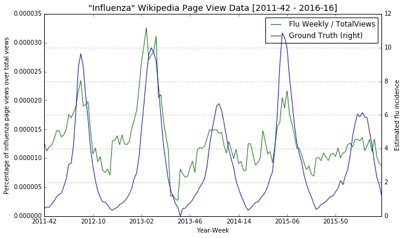

```python
df_norm['Influenza'].plot(legend=True, label='Flu Weekly / TotalViews', color='g')
plt.title('"Influenza" Wikipedia Page View Data ['+ min(gt_ts.index)+' - '+max(gt_ts.index)+']', fontsize=14)
plt.xlabel('Year-Week')
plt.ylabel('Percentage of influenza page views over total views')
gt_ts.plot(legend=True, label='Ground Truth', secondary_y=True, color='b')
plt.ylabel('Estimated flu incidence')
plt.grid()
plt.show()
```

It's evident a similar evolution of the wikipedia click on page "Influenza" respect to ground truth, but to have an objective indicator we try to compute the correlation between the two time series.

Initially I have consider some measures of correlation:

- Pearson Correlation
- Cross Correlation
- Spearman rank-order Correlation

Let's start to analyze them:

#### Pearson correlation

The Pearson correlation coefficient measures the linear relationship between two datasets. Strictly speaking, Pearson’s correlation requires that each dataset be normally distributed, and not necessarily zero-mean. Like other correlation coefficients, this one varies between -1 and +1 with 0 implying no correlation. Correlations of -1 or +1 imply an exact linear relationship. Positive correlations imply that as x increases, so does y. Negative correlations imply that as x increases, y decreases. The p-value roughly indicates the probability of an uncorrelated system producing datasets that have a Pearson correlation at least as extreme as the one computed from these datasets.

To apply this measure of correlation we try to verify if they are normally distributed, and to do that we use Jarque-Bera test and normal test.

**Jarque-Bera test** work for a large enough number of data sample (>2000) and the test asymptoticcaly has a Chi-Squared distribution with 2 degrees of freedom.

The null hypothesis **H0** is a joint hypothesis of the *skewness being zero* and the *excess kurtosis being zero* (kurtosis equal to 3, excess kurtosis equal to 0)

```python
jb_value,p = scipy.stats.jarque_bera(gt_ts)
print 'Ground Truth - Statistic test', round(jb_value,4), 'with', p, 'p-value'
```

```
Ground Truth - Statistic test 26.8481 with 1.47912398418e-06 p-value
```

```python
jb_value,p = scipy.stats.jarque_bera(df_norm['Influenza'])
print 'Influenza - Statistic test', round(jb_value,4), 'with', p, 'p-value'
```

```
Influenza - Statistic test 74.3368 with 1.11022302463e-16 p-value
```

**Normal test** is based on D’Agostino and Pearson’s test that combines skew and kurtosis to produce an omnibus test of normality.

Obviously the null hypothesis **H0** is normal distribution and the test is distributed as a Chi-Square.

```python
k2,p = scipy.stats.mstats.normaltest(gt_ts)
print 'Ground Truth - Statistic test', round(k2,4), 'with', p, 'p-value'
```

```
Ground Truth - Statistic test 21.2782 with 2.39607991243e-05 p-value
```

```python
k2,p = scipy.stats.mstats.normaltest(df_norm['Influenza'])
print 'Influenza - Statistic test', round(k2,4), 'with', p, 'p-value'
```

```
Influenza - Statistic test 40.3316 with 1.74624418387e-09 p-value
```

Both the test Reject the null hypothesis of normal distribution, the correlation measure haven't any sense. Only to play I have tried to do the measure of Pearson correlation

```python
coeff, pvalue = pearsonr(gt_ts, df_norm['Influenza'])
print coeff, ' ', pvalue
```

```
0.750461057133   1.36011511074e-26
```

#### Cross-correlation

Relationships between time series is by the cross-correlation function (assuming stationarity). To use this measure we should verify the stationarity of the two series. The null hypothesis is of zero correlation .

To do that I have used the Augmented Dickey-Fuller test. The null hypothesis of the Augmented Dickey-Fuller is that there is a unit root, with the alternative that there is no unit root. If the pvalue is above a critical size, then we cannot reject that there is a unit root.

The p-values are obtained through regression surface approximation from MacKinnon 1994, but using the updated 2010 tables. If the p-value is close to significant, then the critical values should be used to judge whether to accept or reject the null.

```python
adf,pvalue,_,_,_,_ = statsmodels.tsa.stattools.adfuller(gt_ts)
print 'Augmented Dickey-Fuller unit root test - Ground Truth Series'
print 'Test statistic:', round(adf,4), 'with', pvalue, "p-value"
```

```
Augmented Dickey-Fuller unit root test - Ground Truth Series
Test statistic: -5.6384 with 1.05025106912e-06 p-value
```

```python
adf,pvalue,_,_,_,_ = statsmodels.tsa.stattools.adfuller(df_norm['Influenza'])
print 'Augmented Dickey-Fuller unit root test - Influenza Series'
print 'Test statistic:', round(adf,4), 'with', pvalue, "p-value"
```

```
Augmented Dickey-Fuller unit root test - Influenza Series
Test statistic: -4.4052 with 0.000290597006878 p-value
```

For each series we reject the null hypothesis of unit root at level 5% and also 1%. We assume stationarity! This will be the measure of correlation that we use in this assignment.

The function of numpy.correlate and scipy.signal.correlate return an incorrect value of correlation. To solve this I have written the function correctly (I hope).

The function, given two time series in input, return the correlation value, the statistic test and the p-value.

```python
def crossCorr(x,y):
    num = np.mean((x-np.mean(x))*(y-np.mean(y)))
    den = np.std(x)*np.std(y)
    r = num/den

    #significance
    n = len(x)
    t = r * ((n-2)/(1-r**2))**(0.5)
    pvalue = 1-scipy.stats.t.cdf(t, n-2)

    return r,t,pvalue
```

```python
r,t,p = crossCorr(gt_ts, df_norm['Influenza'])

print 'The correlation between Ground Truth and Influenza is:'
print 'Cross-Correlation',round(r,4), 'with statistic test', round(t,4), 'and pvalue', p
```

```
The correlation between Ground Truth and Influenza is:
Cross-Correlation 0.7505 with statistic test 13.339 and pvalue 0.0
```

The null hypothesis $H_0$ of zero correlation is rejected at every level $\alpha$

#### Spearman rank-order correlation

The Spearman's rank-order correlation is the nonparametric version of the Pearson product-moment correlation. Spearman's correlation coefficient measures the strength and direction of association between two ranked variables and this is not our case!

*Note*: The measure of correlation that I have used in all of the next point is **Cross-Correlation**

## Part 2.1

### Try to find other Wikipedia pages related to flu whose pageview time series are correlated with the Influnet signal

The choose of the keywords and then of the pageviews is done in this way:

- keywords used in the paper (mentioned at the beginning)
- keywords mentioned in the assignment text
- keywords linked in the Influenza Wikipedia web page

The last point is interesting, because the page with an high correlation with Influenza is a strong evidence of people interested to symptom, evolution and drugs of Influenza. They are searching exactly this things!

We repeat the same analyze done for only Influenza serie, to all the dataframe.

A briefly view of the keywords series

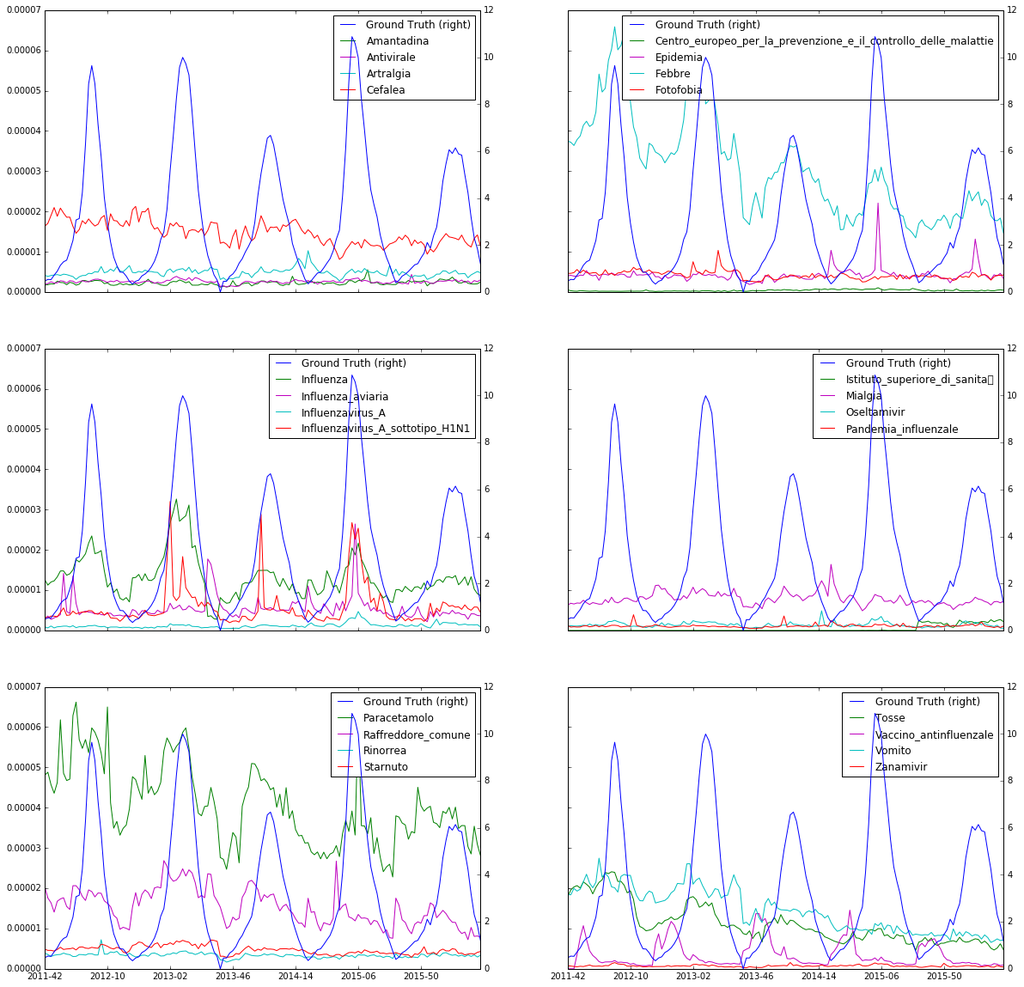

```python
pos = [[0,0],[0,1],[1,0],[1,1],[2,0],[2,1]]
fig, axes = plt.subplots(nrows=3, ncols=2,sharey=True,sharex=True,figsize=(20,20))
for i in range(int(np.ceil(float(len(df_norm.columns))/4))):
    a,b = pos[i]
    gt_ts.plot(ax=axes[a,b], legend=True, label='Ground Truth', secondary_y=True, color='b')
    df_norm[df_norm.columns[(i*4)]].plot(ax=axes[a,b], legend=True, label=df_norm.columns[(i*4)], color='g')
    df_norm[df_norm.columns[(i*4)+1]].plot(ax=axes[a,b], legend=True, label=df_norm.columns[(i*4)+1], color='m')
    df_norm[df_norm.columns[(i*4)+2]].plot(ax=axes[a,b], legend=True, label=df_norm.columns[(i*4)+2], color='c')
    df_norm[df_norm.columns[(i*4)+3]].plot(ax=axes[a,b], legend=True, label=df_norm.columns[(i*4)+3], color='r')
plt.show()
```

Fever seem to have a correlation with ground truth (plot 0,1), Influenza_A_sottotipo_H1N1 (plot 1,0) like Influenza (plot 1,0) analyzed above. A strange things appear in the last plot (plot 2,1): the keywords Vaccino_antinfluenzale seem to anticipate the flu season and have an evolution similar than ground truth.

At this point we continue without any treatment of the series.

## Part 2.2

### On aggregating the hourly pageview data to compute weekly pageviews, can you do something to select page views from Italy?

Given this question some consideration are acceptable like do a random samples or we can see how the views are distributed during the 24-hours. I'm interesting to follow the second option.

To do that I have defined a function call *hourly*, this function reload all the data but it aggregated the views by the hour. Every basic treatment of the series explained before are done.

```python
def hourly(filename, sep):
    ts = pd.Series.from_csv(filename, sep = sep, header=None, index_col = 0)
    wts = ts.groupby(ts.index.strftime('%H')).mean()
    return wts
```

```python
df_h = pd.concat([hourly(f, ' ') for f in glob.glob(path + "/*.txt")], axis=1)
df_h = df_h.fillna(0)
```

```python
df_h.columns = [os.path.basename(f).split('.')[0] for f in glob.glob(path + "/*.txt")]
```

```python
df_h["Influenzavirus_A_sottotipo_H1N1"] = df_h["Influenzavirus_A_sottotipo_H1N1"].add(df_h["Virus_dell'influenza_A_sottotipo_H1N1"], fill_value=0).add(df_h["Virus_dell%27influenza_A_sottotipo_H1N1"], fill_value=0)
```

```python
del df_h["Virus_dell'influenza_A_sottotipo_H1N1"]
del df_h["Virus_dell%27influenza_A_sottotipo_H1N1"]
```

```python
df_h_tot = df_h.copy()
```

```python
del df_h['totalViews']
```

A plot will help us to understand the distribution of the views by hour. Except some keywords drop to zero, the series with a consistent number of visualizations follow the same trend

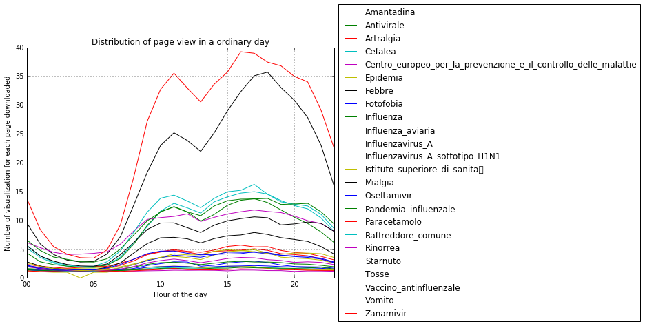

```python
ax = df_h.plot(legend=True)
plt.title('Distribution of page view in a ordinary day')
plt.xlabel('Hour of the day')
plt.ylabel('Number of visualization for each page downloaded')
box = ax.get_position()
ax.set_position([box.x0, box.y0, box.width * 0.8, box.height])
ax.legend(loc='center left', bbox_to_anchor=(1, 0.5))
plt.grid()
plt.show()
```

Below a summarize plot.

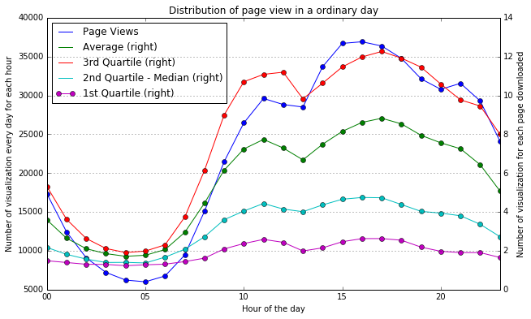

```python
df_h_tot.mean(axis=1).plot(marker='o', linestyle='-', legend=True, label='Page Views')
plt.xlabel('Hour of the day')
plt.ylabel('Number of visualization every day for each hour')
plt.title('Distribution of page view in a ordinary day')
df_h.mean(axis=1).plot(marker='o', linestyle='-', secondary_y=True, legend=True, label='Average')
plt.ylabel('Number of visualization for each page downloaded')
df_h.quantile(q=0.75, axis=1).plot(marker='o', linestyle='-', secondary_y=True, legend=True, label='3rd Quartile')
df_h.quantile(q=0.50, axis=1).plot(marker='o', linestyle='-', secondary_y=True, legend=True, label='2nd Quartile - Median')
df_h.quantile(q=0.25, axis=1).plot(marker='o', linestyle='-', secondary_y=True, legend=True, label='1st Quartile')
plt.grid()
plt.show()
```

In this plot is evident that if we would select a subset of the views without loss of information, we can drop the night hours (e.g. between 0-8 or 1-7 or 2-5 depend how accuracy we would have).

## Part 2.3

### For each of the selected Wikipedia pages, compute the same correlation with the Influnet time series

With the function of the *Cross-Correlation* defined before, we compute the measure of correlation between the selected pages and the groud truth

```python
corr = [crossCorr(gt_ts, df_norm[i])[0] for i in list(df_norm.columns)]
```

```python
for i in range(len(df_norm.columns)):
    print('\t'.join(['%.4f','%.33s']) % (corr[i], df_norm.columns[i]))
```

```
0.4122	Amantadina
0.5480	Antivirale
0.0950	Artralgia
-0.0691	Cefalea
0.0243	Centro_europeo_per_la_prevenzione
0.2914	Epidemia
0.4608	Febbre
0.0817	Fotofobia
0.7505	Influenza
0.1926	Influenza_aviaria
0.5817	Influenzavirus_A
0.6136	Influenzavirus_A_sottotipo_H1N1
-0.0446	Istituto_superiore_di_sanità
0.0968	Mialgia
0.6305	Oseltamivir
0.1581	Pandemia_influenzale
0.4129	Paracetamolo
0.2639	Raffreddore_comune
0.3497	Rinorrea
0.2502	Starnuto
0.2611	Tosse
-0.3684	Vaccino_antinfluenzale
0.0754	Vomito
0.6276	Zanamivir
```

Is easy to understand if we sort in descending order the correlation. Pay attention that a negative correlation but with high negative value is significant as positive! (abs use to do that)

```python
id_sort = sorted(range(len(corr)), reverse=True, key = np.abs(corr).__getitem__)
print 'Correlation of selected wikipedia pages in descending order'
for i in range(len(df_norm.columns)):
    print('\t'.join(['%.4f','%.33s']) % (corr[id_sort[i]], df_norm.columns[id_sort[i]]))
```

```
Correlation of selected wikipedia pages in descending order
0.7505	Influenza
0.6305	Oseltamivir
0.6276	Zanamivir
0.6136	Influenzavirus_A_sottotipo_H1N1
0.5817	Influenzavirus_A
0.5480	Antivirale
0.4608	Febbre
0.4129	Paracetamolo
0.4122	Amantadina
-0.3684	Vaccino_antinfluenzale
0.3497	Rinorrea
0.2914	Epidemia
0.2639	Raffreddore_comune
0.2611	Tosse
0.2502	Starnuto
0.1926	Influenza_aviaria
0.1581	Pandemia_influenzale
0.0968	Mialgia
0.0950	Artralgia
0.0817	Fotofobia
0.0754	Vomito
-0.0691	Cefalea
-0.0446	Istituto_superiore_di_sanità
0.0243	Centro_europeo_per_la_prevenzione
```

Influenza is again the page views more correlated with the ground truth.

## Part 3.1

### Build a regression model that predicts the Influnet incidence for a given week based on the Wikipedia pageview data for the same week.

- F-test
- Mutual Information
- Cross-Correlation (explained before)

**F-test** [f_regression function]

The methods based on F-test estimate the degree of linear dependency between two random variables. It is a univariate linear regression tests. Quick linear model for testing the effect of a single regressor, sequentially for many regressors.

This is done in 2 steps:

- The cross correlation between each regressor and the target is computed, that is,

  ((X[:, i] - mean(X[:, i])) *(y - mean_y)) / (std(X[:, i])* std(y))
- It is converted to an F score then to a p-value.

**Mutual Information** [mutal_info_regression]

The mutual information methods can capture any kind of statistical dependency, but being nonparametric, they require more samples for accurate estimation. It estimate mutual information for a continuous target variable. Mutual information (MI) between two random variables is a non-negative value, which measures the dependency between the variables. It is equal to zero if and only if two random variables are independent, and higher values mean higher dependency. The function relies on nonparametric methods based on entropy estimation from k-nearest neighbors distances.

```python
# F-test
f_test, _ = f_regression(df_norm,gt_ts)
f_test = normalize([f_test])[0]

# Mutual Information
mi = mutual_info_regression(df_norm,gt_ts)
mi = normalize([mi])[0]

# Cross-Correlation
corr = [crossCorr(gt_ts, df_norm[i])[0] for i in list(df_norm.columns)]
corr = normalize([corr])[0]

# Score
score = np.mean([f_test,mi,corr], axis=0)
```

```python
sort_index_f_test = sorted(range(len(f_test)), key=np.abs(f_test).__getitem__, reverse=True)
sort_index_mi = sorted(range(len(mi)), key=np.abs(mi).__getitem__, reverse=True)
sort_index_corr = sorted(range(len(corr)), key=np.abs(corr).__getitem__, reverse=True)
sort_index_score = sorted(range(len(score)), key=np.abs(score).__getitem__, reverse=True)
```

```python
# Select the top k elements
k = 5
```

```python
f_test_col = ['\033[36m%.4f\033[0m' if i  in sort_index_f_test[0:5] else '\033[30m%.4f' for i in range(len(df_norm.columns))]
mi_col     = ['\033[36m%.4f\033[0m' if i in sort_index_mi[0:k] else '\033[30m%.4f' for i in range(len(df_norm.columns))]
corr_col   = ['\033[36m%.4f\033[0m' if i in sort_index_corr[0:k] else '\033[30m%.4f' for i in range(len(df_norm.columns))]
score_col  = ['\033[36m%.4f\033[0m' if i in sort_index_score[0:k] else '\033[30m%.4f' for i in range(len(df_norm.columns))]
feat_col   = ['\033[46m%s\033[0m' if i in sort_index_score[0:k] else '\033[30m%s' for i in range(len(df_norm.columns))]
```

```python
print ('\t'.join(['f_reg', 'mi', 'corr', 'score', 'feature']))
for i in range(len(df_norm.columns)):
    print('\t'.join([f_test_col[i], mi_col[i], corr_col[i], score_col[i], feat_col[i]]) % (f_test[i], f_test[i], corr[i], score[i], df_norm.columns[i][:33]))
```

```
f_reg	mi	corr	score	feature
0.1085	0.1085	0.2183	0.1676	Amantadina
0.2276	0.2276	0.2902	0.2447	Antivirale
0.0048	0.0048	0.0503	0.0494	Artralgia
0.0025	0.0025	-0.0366	-0.0126	Cefalea
0.0003	0.0003	0.0129	0.0125	Centro_europeo_per_la_prevenzione
0.0492	0.0492	0.1543	0.1066	Epidemia
0.1429	0.1429	0.2440	0.2565	Febbre
0.0036	0.0036	0.0433	0.0335	Fotofobia
0.6835	0.6835	0.3974	0.4574	Influenza
0.0204	0.0204	0.1020	0.0739	Influenza_aviaria
0.2712	0.2712	0.3081	0.2797	Influenzavirus_A
0.3202	0.3202	0.3250	0.3362	Influenzavirus_A_sottotipo_H1N1
0.0011	0.0011	-0.0236	0.0041	Istituto_superiore_di_sanità
0.0050	0.0050	0.0513	0.0304	Mialgia
0.3497	0.3497	0.3339	0.3624	Oseltamivir
0.0136	0.0136	0.0837	0.0563	Pandemia_influenzale
0.1089	0.1089	0.2186	0.1730	Paracetamolo
0.0397	0.0397	0.1397	0.0884	Raffreddore_comune
0.0739	0.0739	0.1852	0.1405	Rinorrea
0.0354	0.0354	0.1325	0.1104	Starnuto
0.0388	0.0388	0.1382	0.0905	Tosse
0.0832	0.0832	-0.1951	0.0171	Vaccino_antinfluenzale
0.0030	0.0030	0.0399	0.0518	Vomito
0.3446	0.3446	0.3324	0.3098	Zanamivir
```

```python
print 'The top feature is', df_norm.columns[score.argmax()],'with score',  round(score.max(),4)
```

```
The top feature is Influenza with score 0.4574
```

```python
ind = np.argpartition(score, -k)[-k:]
ind = ind[np.argsort(score[ind], -1, )][::-1]
```

```python
print 'The top', k, 'features are:'
for i in range(len(ind)):
    print (i+1), ' with value ', round(score[ind[i]],4),'is', df_norm.columns[ind[i]]
```

```
The top 5 features are:
1  with value  0.4574 is Influenza
2  with value  0.3624 is Oseltamivir
3  with value  0.3362 is Influenzavirus_A_sottotipo_H1N1
4  with value  0.3098 is Zanamivir
5  with value  0.2797 is Influenzavirus_A
```

```python
top_corr = np.corrcoef(df_norm[list(df_norm.columns[ind])], rowvar=0)
print top_corr
```

```
[[ 1.          0.54288161  0.49994673  0.55222429  0.32382716]
 [ 0.54288161  1.          0.5006891   0.62880622  0.51401772]
 [ 0.49994673  0.5006891   1.          0.42860158  0.62360429]
 [ 0.55222429  0.62880622  0.42860158  1.          0.51714339]
 [ 0.32382716  0.51401772  0.62360429  0.51714339  1.        ]]
```

In the matrix above we can see a significant correlation between the feature selected.

This is an interesting point of view of the features selection, because the top 5 features are highly correlated with the ground truth but also between their.

As touched on before, correlation between the keywords selected is an indicator that the people are searching exactly this thing!

**Build a model - model 0**

Try to build a model with the 5 top features. A briefly introduction of what we do in this model:

- No treatment are applied at the series
- No shift at each series
- No cut at night hours
- No dummy variables (for each season)
- No ARMA model

This assumption imply that in the sequel this argument will be treated. Moreover in this first model with linear regression we point attention at the model, coefficient, coefficients significance, and relative p-value.

Create a dataframe with the selected features

```python
df_top = df_norm[list(df_norm.columns[ind])].copy()
```

Split the dataset in train and test (70-30) and fit the model.

```python
id_train, id_test = train_test_split(range(len(gt_ts.index)), train_size = 0.7, test_size = 0.3)
```

```python
X_train = df_top.iloc[id_train]
X_test = df_top.iloc[id_test]
y_train = gt_ts.iloc[id_train]
y_test = gt_ts.iloc[id_test]
```

```python
reg = linear_model.LinearRegression(fit_intercept=True, normalize=True).fit(X_train,y_train)
```

```python
sse = np.sum((reg.predict(X_train) - y_train) ** 2, axis=0) / float(X_train.shape[0] - X_train.shape[1])
se = np.array([np.sqrt(np.diagonal(sse * np.linalg.inv(np.dot(X_train.T, X_train))))])
t = reg.coef_ / se
p = 2 * (1 - stats.t.cdf(np.abs(t), y_train.shape[0] - X_train.shape[1]))
```

```python
# The intercept
print 'Intercept: \n', reg.intercept_
```

```
Intercept:
-3.82930318125
```

```python
print '\t'.join(['Coefficient','t-stat','p-value','feature'])
for i in range(len(df_top.columns)):
    print '\t'.join(['%.4f','%.4f','%.4f','%s']) % (reg.coef_[i],t[0][i],p[0][i],df_top.columns[i])
```

```
Coefficient	t-stat	p-value	feature
263553.4336	7.1012	0.0000	Influenza
338507.2602	0.9611	0.3390	Oseltamivir
42550.5218	1.1716	0.2443	Influenzavirus_A_sottotipo_H1N1
2148412.2812	2.4114	0.0179	Zanamivir
1075618.7421	3.3398	0.0012	Influenzavirus_A
```

```python
# The mean squared error
print("Mean squared error: %.4f" % np.mean((reg.predict(X_test) - y_test) ** 2))
```

```
Mean squared error: 1.8956
```

```python
# Returns the coefficient of determination R^2 of the prediction
# Explained variance score: 1 is perfect prediction
print 'Coefficient of determination R^2 of the prediction', reg.score(X_test, y_test)
```

```
Coefficient of determination R^2 of the prediction 0.632210272083
```

**Cross-validation - Multiple model performance**

*Generalized Linear Models*

The methods involved for regression, the target value is expected to be a linear combination of the input variables.

$\hat{y}(w, x) = w_0 + w_1 x_1 + ... + w_p x_p$

$\hat{y}$ is the predicted value, the vector $w = (w_1,..., w_p)$ as *coef* and $w_0$ as *intercept*.

Model selected:

- *Ordinary Least Squares*: LinearRegression fits a linear model with coefficients $w = (w_1, ..., w_p)$ to minimize the residual sum of squares between the observed responses in the dataset, and the responses predicted by the linear approximation. $\underset{w}{min\,} {|| X w - y||_2}^2$
- *Ridge Regression*: Ridge regression addresses some of the problems of Ordinary Least Squares by imposing a penalty on the size of coefficients. The ridge coefficients minimize a penalized residual sum of squares, $\underset{w}{min\,} {{|| X w - y||_2}^2 + \alpha {||w||_2}^2}$  
  Here, $\alpha \geq 0$ is a complexity parameter that controls the amount of shrinkage: the larger the value of $\alpha$, the greater the amount of shrinkage and thus the coefficients become more robust to collinearity.
- *Lasso Regression*: The Lasso is a linear model that estimates sparse coefficients. It is useful in some contexts due to its tendency to prefer solutions with fewer parameter values, effectively reducing the number of variables upon which the given solution is dependent. It consists of a linear model trained with $\ell_1$ prior as regularizer. The objective function to minimize is: $\underset{w}{min\,} { \frac{1}{2n_{samples}} ||X w - y||_2 ^ 2 + \alpha ||w||_1}$ The lasso estimate thus solves the minimization of the least-squares penalty with $\alpha ||w||_1$ added, where $\alpha$ is a constant and $||w||_1$ is the $\ell_1$-norm of the parameter vector.
- *Bayesian Regression*: Bayesian regression techniques can be used to include regularization parameters in the estimation procedure: the regularization parameter is not set in a hard sense but tuned to the data at hand. This can be done by introducing uninformative priors over the hyper parameters of the model. The $\ell_{2}$ regularization used in Ridge Regression is equivalent to finding a maximum a-postiori solution under a Gaussian prior over the parameters w with precision $\lambda^-1$. Instead of setting lambda manually, it is possible to treat it as a random variable to be estimated from the data. To obtain a fully probabilistic model, the output y is assumed to be Gaussian distributed around  
  $X_w$: $p(y|X,w,\alpha) = \mathcal{N}(y|X w,\alpha)$  
  Alpha is again treated as a random variable that is to be estimated from the data. The advantages of Bayesian Regression are:
  - It adapts to the data at hand.
  - It can be used to include regularization parameters in the estimation procedure.

  The disadvantages of Bayesian regression include:
  - Inference of the model can be time consuming.
- *Polynomial regression*: One common pattern within machine learning is to use linear models trained on nonlinear functions of the data. This approach maintains the generally fast performance of linear methods, while allowing them to fit a much wider range of data. If we want to fit a paraboloid to the data instead of a plane, we can combine the features in second-order polynomials, so that the model looks like this: $\hat{y}(w, x) = w_0 + w_1 x_1 + w_2 x_2 + w_3 x_1 x_2 + w_4 x_1^2 + w_5 x_2^2$  
  The observation is that this is still a linear model: imagine creating a new variable $z = [x_1, x_2, x_1 x_2, x_1^2, x_2^2]$  
  With this re-labeling of the data, our problem can be written $\hat{y}(w, x) = w_0 + w_1 z_1 + w_2 z_2 + w_3 z_3 + w_4 z_4 + w_5 z_5$  
  We see that the resulting polynomial regression is in the same class of linear models we’d considered above (the model is linear in w) and can be solved by the same techniques. By considering linear fits within a higher-dimensional space built with these basis functions, the model has the flexibility to fit a much broader range of data.

```python
kf = KFold(n_splits=10, shuffle=True).split(df_top.index)
models = ['LinearRegression','Ridge','Lasso','Bayesian','Polynomial']
mse = {m:[] for m in models}
alphas = [0.01,0.02,0.05,0.08,0.1,0.2,0.5,0.8,1,2,5,8]
```

```python
for tr, te in kf:
    X_train = df_top.iloc[tr]
    X_test = df_top.iloc[te]
    y_train = gt_ts.iloc[tr]
    y_test = gt_ts.iloc[te]

    ### Ordinary least squares Linear Regression
    reg = linear_model.LinearRegression(fit_intercept=True, normalize=True).fit(X_train,y_train)
    mse['LinearRegression'].append(np.mean((reg.predict(X_test) - y_test) ** 2))

    ### Ridge Regression
    ridge_cv = linear_model.RidgeCV(fit_intercept=True, normalize=True, alphas = alphas).fit(X_train, y_train)
    ridge = linear_model.Ridge(fit_intercept=True, normalize=True, alpha = round(ridge_cv.alpha_,3)).fit(X_train, y_train)
    mse['Ridge'].append(np.mean((ridge.predict(X_test) - y_test) ** 2))

    ### Lasso Regression
    lasso_cv = linear_model.LassoCV(fit_intercept=True, normalize=True, alphas=alphas).fit(X_train, y_train)
    lasso = linear_model.Lasso(fit_intercept=True, normalize=True, alpha = round(lasso_cv.alpha_,3)).fit(X_train, y_train)
    mse['Lasso'].append(np.mean((lasso.predict(X_test) - y_test) ** 2))

    ### Bayesian Ridge Regression
    bay = linear_model.BayesianRidge(fit_intercept=True, normalize=True).fit(X_train, y_train)
    mse['Bayesian'].append(np.mean((bay.predict(X_test) - y_test) ** 2))

    ### Polynomial Regression
    pol = Pipeline([('poly', PolynomialFeatures(degree=2)),
                    ('linear', linear_model.LinearRegression(fit_intercept=True, normalize=True))]).fit(X_train, y_train)
    mse['Polynomial'].append(np.mean((pol.predict(X_test) - y_test) ** 2))
```

```python
mse_mean = {k: np.mean(mse[k]) for k in models}
print 'MSE models means'
for k, v in mse_mean.iteritems():
    print round(v,5),'\t', k
print '\nThe model with the minimum MSE', min(mse_mean.values()),'is', min(mse_mean, key=mse_mean.get)
```

```
MSE models means
2.73145 	Bayesian
2.68211 	Ridge
10.38885 	Polynomial
2.75544 	LinearRegression
2.78566 	Lasso

The model with the minimum MSE 2.68211179554 is Ridge
```

The first approach at the prediction with the Ridge model is an increase train set step-by-step from one observation to all minus one observations. The train set is used to estimate the coefficients of the model. The predictions are done one week out-of-sample of every increasing dataset.

```python
y_pred = []
for i in range(1,len(df_top.index)):
    X_train = df_top.iloc[:i]
    X_test = df_top.iloc[[i]]
    y_train = gt_ts.iloc[:i]
    y_test = gt_ts.iloc[[i]]
    ridge_cv = linear_model.RidgeCV(fit_intercept=True, normalize=True, alphas = alphas).fit(X_train, y_train)
    ridge = linear_model.Ridge(fit_intercept=True, normalize=True, alpha = round(ridge_cv.alpha_,3)).fit(X_train, y_train)
    y_pred.append(ridge.predict(X_test)[0])
```

```python
flu_pred_rol = pd.Series(y_pred, index=df_top.index[1:], name='flu_pred')
```

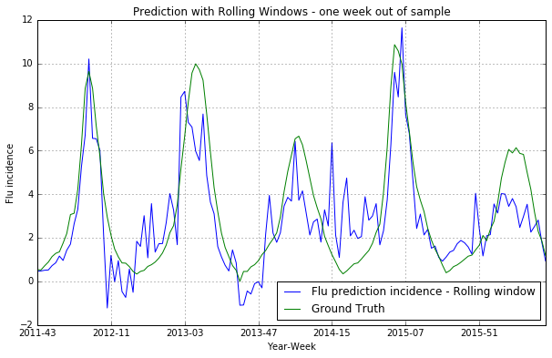

```python
flu_pred_rol.plot(legend=True, label='Flu prediction incidence - Rolling window')
gt_ts[flu_pred_rol.index].plot(legend=True, label=('Ground Truth'))
plt.title('Prediction with Rolling Windows - one week out of sample')
plt.xlabel('Year-Week')
plt.ylabel('Flu incidence')
plt.grid()
plt.show()
```

The model with the lowest MSE is Ridge. After that we try with a rolling window of 10 and 28 weeks to predict the next 1 week and see how it performs. 0 is a random value, but 28 is equal to 1 season observation and in this way we see how it perform in the next year

```python
windows = [10,28]
y_pred = {w:[] for w in windows}
```

```python
for w in windows:
    for i in range(len(df_top.index)-w):
        X_train = df_top.iloc[i:i+w]
        X_test = df_top.iloc[[i+w]]
        y_train = gt_ts.iloc[i:i+w]
        y_test = gt_ts.iloc[[i+w]]
        ridge_cv = linear_model.RidgeCV(fit_intercept=True, normalize=True, alphas = alphas).fit(X_train, y_train)
        ridge = linear_model.Ridge(fit_intercept=True, normalize=True, alpha = round(ridge_cv.alpha_,3)).fit(X_train, y_train)
        y_pred[w].append(ridge.predict(X_test)[0])
```

```python
flu_pred_rol = pd.concat([pd.Series(y_pred[w], index=df_top.index[w:], name=w) for w in windows], axis=1)
flu_pred_rol = pd.concat([gt_ts, flu_pred_rol], axis=1)
del flu_pred_rol[0]
```

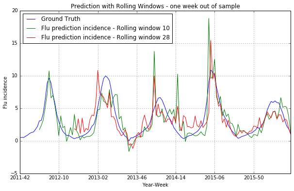

```python
gt_ts.plot(legend=True, label='Ground Truth')
plt.title('Prediction with Rolling Windows - one week out of sample')
plt.xlabel('Year-Week')
plt.ylabel('Flu incidence')
for w in windows:
    flu_pred_rol[w].plot(legend=True, label=('Flu prediction incidence - Rolling window '+ str(w)))
plt.grid()
plt.show()
```

The series are almost nearly. A fast measure of correlation:

```python
r,t,p = crossCorr(gt_ts[flu_pred_rol[windows[1]].index], flu_pred_rol[windows[1]])
print 'The correlation between Ground Truth and Flu Prediction is:'
print 'Cross-Correlation',round(r,4), 'with statistic test', round(t,4), 'and pvalue', p
```

```
The correlation between Ground Truth and Flu Prediction is:
Cross-Correlation 0.7664 with statistic test 14.0159 and pvalue 0.0
```

An other way to see how the model predict is to select one year, let the model estimate the better coefficients given this subset and after that try to estimate the flu of the next year. In the next cell this are done and at the end plot it.

```python
y_pred = {i:[] for i in range(4)}
for i in range(4):
    X_train = df_top.iloc[i*28:(i+1)*28]
    X_test = df_top.iloc[(i+1)*28:(i+2)*28]
    y_train = gt_ts.iloc[i*28:(i+1)*28]
    y_test = gt_ts.iloc[(i+1)*28:(i+1)*28]
    ridge_cv = linear_model.RidgeCV(fit_intercept=True, normalize=True, alphas = alphas).fit(X_train, y_train)
    ridge = linear_model.Ridge(fit_intercept=True, normalize=True, alpha = round(ridge_cv.alpha_,3)).fit(X_train, y_train)
    y_pred[i].append(ridge.predict(X_test))
```

```python
flu_pred_rol = pd.concat([pd.Series(y_pred[i][0], index=df_top.index[(i+1)*28:(i+2)*28], name=i+1) for i in range(4)], axis=1)
flu_pred_rol = pd.concat([gt_ts, flu_pred_rol], axis=1)
del flu_pred_rol[0]
```

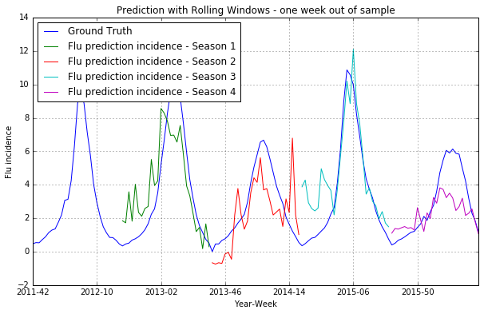

```python
gt_ts.plot(legend=True, label='Ground Truth')
plt.title('Prediction with Rolling Windows - one week out of sample')
plt.xlabel('Year-Week')
plt.ylabel('Flu incidence')
for i in range(4):
    flu_pred_rol[i+1].plot(legend=True, label=('Flu prediction incidence - Season '+ str(i+1)))
plt.grid()
plt.show()
```

Last prediction is done with all the previous season to let estimate the coeff and after that try to estimate the flu of the next year.  
The difference with the prediction above are only in the period considered to estimate the parameter of the model.

```python
y_pred = {i:[] for i in range(4)}
for i in range(4):
    X_train = df_top.iloc[:(i+1)*28]
    X_test = df_top.iloc[(i+1)*28:(i+2)*28]
    y_train = gt_ts.iloc[:(i+1)*28]
    y_test = gt_ts.iloc[(i+1)*28:(i+1)*28]
    ridge_cv = linear_model.RidgeCV(fit_intercept=True, normalize=True, alphas = alphas).fit(X_train, y_train)
    ridge = linear_model.Ridge(fit_intercept=True, normalize=True, alpha = round(ridge_cv.alpha_,3)).fit(X_train, y_train)
    y_pred[i].append(ridge.predict(X_test))
```

```python
flu_pred_rol = pd.concat([pd.Series(y_pred[i][0], index=df_top.index[(i+1)*28:(i+2)*28], name=i+1) for i in range(4)], axis=1)
flu_pred_rol = pd.concat([gt_ts, flu_pred_rol], axis=1)
del flu_pred_rol[0]
```

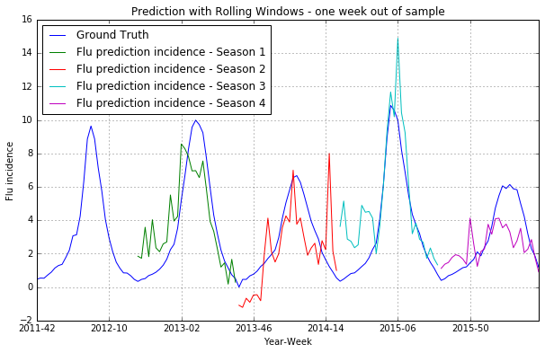

```python
gt_ts.plot(legend=True, label='Ground Truth')
plt.title('Prediction with Rolling Windows - one week out of sample')
plt.xlabel('Year-Week')
plt.ylabel('Flu incidence')
for i in range(4):
    flu_pred_rol[i+1].plot(legend=True, label=('Flu prediction incidence - Season '+ str(i+1)))
plt.grid()
plt.show()
```

Not significant difference are observable.

#### Build a model - model 1 - Night hours cut-off

In this model I have tried to cut off the night view, in particular from mid-night to 7am include.

```python
def hourlyToWeeklyDropNight(filename,sep,h_start,h_end):
    ts = pd.Series.from_csv(filename, sep = sep, header=None, index_col = 0)
    ts = ts.ix[ts.index.indexer_between_time(datetime.time(h_start),datetime.time(h_end),include_start=True,include_end=True)]
    wts = ts.groupby(ts.index.strftime("%G-%V")).sum()
    return wts
```

```python
df_night = pd.concat([hourlyToWeeklyDropNight(f, ' ', 8, 23) for f in glob.glob(path + "/*.txt")], axis=1)
df_night = df_night.fillna(0)
df_night.columns = [os.path.basename(f).split('.')[0] for f in glob.glob(path + "/*.txt")]
```

```python
df_night["Influenzavirus_A_sottotipo_H1N1"] = df_night["Influenzavirus_A_sottotipo_H1N1"].add(df_night["Virus_dell'influenza_A_sottotipo_H1N1"], fill_value=0).add(df_night["Virus_dell%27influenza_A_sottotipo_H1N1"], fill_value=0)
del df_night["Virus_dell'influenza_A_sottotipo_H1N1"]
del df_night["Virus_dell%27influenza_A_sottotipo_H1N1"]
```

```python
# Secure copy of the data
df_night_raw = df_night.copy()
```

```python
# To restore
# df_night = df_night_raw.copy()
```

```python
# Select a subset with the ground truth index
df_night = df_night.loc[gt_ts.index]

# Normalize the views by the Total Views and drop totalViews column
df_night = df_night.divide(df_night['totalViews'], axis='index')
del df_night['totalViews']
df_night
```

|  | Amantadina | Antivirale | Artralgia | Cefalea | Centro_europeo_per_la_prevenzione_e_il_controllo_delle_malattie | Epidemia | Febbre | Fotofobia | Influenza | Influenza_aviaria | ... | Oseltamivir | Pandemia_influenzale | Paracetamolo | Raffreddore_comune | Rinorrea | Starnuto | Tosse | Vaccino_antinfluenzale | Vomito | Zanamivir |
| --- | --- | --- | --- | --- | --- | --- | --- | --- | --- | --- | --- | --- | --- | --- | --- | --- | --- | --- | --- | --- | --- |
| 2011-42 | 0.000002 | 0.000002 | 0.000004 | 0.000018 | 5.820645e-07 | 0.000004 | 0.000040 | 0.000005 | 0.000013 | 0.000003 | ... | 1.065054e-06 | 1.325126e-06 | 0.000051 | 0.000021 | 0.000004 | 0.000005 | 0.000018 | 0.000000e+00 | 0.000019 | 7.306768e-07 |
| 2011-43 | 0.000002 | 0.000002 | 0.000004 | 0.000018 | 2.760650e-07 | 0.000004 | 0.000039 | 0.000005 | 0.000012 | 0.000004 | ... | 1.184779e-06 | 8.512006e-07 | 0.000051 | 0.000018 | 0.000004 | 0.000005 | 0.000020 | 0.000000e+00 | 0.000019 | 5.981409e-07 |
| 2011-44 | 0.000002 | 0.000003 | 0.000004 | 0.000020 | 2.190006e-07 | 0.000004 | 0.000038 | 0.000005 | 0.000013 | 0.000003 | ... | 1.053289e-06 | 9.072884e-07 | 0.000047 | 0.000017 | 0.000003 | 0.000005 | 0.000020 | 0.000000e+00 | 0.000020 | 5.214301e-07 |
| 2011-45 | 0.000002 | 0.000002 | 0.000004 | 0.000022 | 2.184855e-07 | 0.000004 | 0.000040 | 0.000006 | 0.000013 | 0.000003 | ... | 1.154852e-06 | 8.531340e-07 | 0.000045 | 0.000014 | 0.000003 | 0.000004 | 0.000021 | 3.880720e-06 | 0.000020 | 5.306078e-07 |
| 2011-46 | 0.000003 | 0.000002 | 0.000005 | 0.000020 | 3.845264e-07 | 0.000004 | 0.000041 | 0.000005 | 0.000014 | 0.000003 | ... | 1.185623e-06 | 8.331405e-07 | 0.000048 | 0.000018 | 0.000003 | 0.000005 | 0.000021 | 8.192548e-06 | 0.000020 | 6.515586e-07 |
| 2011-47 | 0.000003 | 0.000003 | 0.000004 | 0.000022 | 2.926736e-07 | 0.000004 | 0.000044 | 0.000006 | 0.000016 | 0.000004 | ... | 1.354971e-06 | 1.127335e-06 | 0.000065 | 0.000018 | 0.000004 | 0.000005 | 0.000022 | 1.145763e-05 | 0.000022 | 5.745075e-07 |
| 2011-48 | 0.000002 | 0.000003 | 0.000005 | 0.000020 | 2.311515e-07 | 0.000006 | 0.000045 | 0.000005 | 0.000016 | 0.000015 | ... | 1.199786e-06 | 1.166765e-06 | 0.000051 | 0.000019 | 0.000004 | 0.000005 | 0.000021 | 7.925194e-06 | 0.000023 | 7.705049e-07 |
| 2011-49 | 0.000002 | 0.000002 | 0.000005 | 0.000020 | 1.396456e-07 | 0.000004 | 0.000044 | 0.000005 | 0.000015 | 0.000005 | ... | 1.617562e-06 | 8.844223e-07 | 0.000049 | 0.000016 | 0.000004 | 0.000005 | 0.000021 | 4.747951e-06 | 0.000022 | 1.000794e-06 |
| 2011-50 | 0.000003 | 0.000003 | 0.000004 | 0.000020 | 2.032613e-07 | 0.000004 | 0.000045 | 0.000005 | 0.000015 | 0.000005 | ... | 1.276029e-06 | 1.050183e-06 | 0.000050 | 0.000016 | 0.000004 | 0.000005 | 0.000019 | 3.715165e-06 | 0.000021 | 7.001222e-07 |
| 2011-51 | 0.000002 | 0.000003 | 0.000004 | 0.000017 | 3.211938e-07 | 0.000005 | 0.000048 | 0.000005 | 0.000016 | 0.000015 | ... | 1.605969e-06 | 1.241949e-06 | 0.000067 | 0.000022 | 0.000003 | 0.000005 | 0.000021 | 2.890744e-06 | 0.000022 | 7.066263e-07 |
| 2011-52 | 0.000002 | 0.000002 | 0.000003 | 0.000015 | 1.668929e-07 | 0.000003 | 0.000057 | 0.000004 | 0.000019 | 0.000007 | ... | 1.335143e-06 | 9.756814e-07 | 0.000070 | 0.000022 | 0.000003 | 0.000005 | 0.000022 | 1.925687e-06 | 0.000028 | 6.547336e-07 |
| 2012-01 | 0.000002 | 0.000003 | 0.000004 | 0.000016 | 1.565146e-07 | 0.000005 | 0.000054 | 0.000005 | 0.000018 | 0.000004 | ... | 1.369503e-06 | 1.222770e-06 | 0.000059 | 0.000020 | 0.000004 | 0.000005 | 0.000022 | 1.643403e-06 | 0.000023 | 6.064941e-07 |
| 2012-02 | 0.000003 | 0.000003 | 0.000004 | 0.000018 | 1.986874e-07 | 0.000005 | 0.000053 | 0.000006 | 0.000019 | 0.000005 | ... | 1.589499e-06 | 9.338306e-07 | 0.000057 | 0.000019 | 0.000004 | 0.000006 | 0.000024 | 1.768318e-06 | 0.000024 | 8.543556e-07 |
| 2012-03 | 0.000003 | 0.000003 | 0.000004 | 0.000018 | 1.733102e-07 | 0.000004 | 0.000061 | 0.000005 | 0.000020 | 0.000005 | ... | 2.344786e-06 | 1.111225e-06 | 0.000059 | 0.000018 | 0.000003 | 0.000005 | 0.000024 | 1.835050e-06 | 0.000023 | 8.053829e-07 |
| 2012-04 | 0.000003 | 0.000003 | 0.000005 | 0.000019 | 2.156976e-07 | 0.000005 | 0.000064 | 0.000005 | 0.000023 | 0.000005 | ... | 2.353064e-06 | 1.274576e-06 | 0.000056 | 0.000021 | 0.000004 | 0.000005 | 0.000025 | 1.784407e-06 | 0.000020 | 1.294185e-06 |
| 2012-05 | 0.000003 | 0.000003 | 0.000005 | 0.000018 | 1.943584e-07 | 0.000004 | 0.000069 | 0.000004 | 0.000025 | 0.000005 | ... | 2.536377e-06 | 1.234176e-06 | 0.000062 | 0.000020 | 0.000004 | 0.000005 | 0.000025 | 2.176814e-06 | 0.000020 | 1.603457e-06 |
| 2012-06 | 0.000003 | 0.000003 | 0.000005 | 0.000017 | 1.430530e-07 | 0.000004 | 0.000063 | 0.000005 | 0.000020 | 0.000004 | ... | 2.307922e-06 | 1.144424e-06 | 0.000061 | 0.000019 | 0.000003 | 0.000005 | 0.000022 | 1.659415e-06 | 0.000019 | 1.239793e-06 |
| 2012-07 | 0.000003 | 0.000003 | 0.000005 | 0.000018 | 1.818077e-07 | 0.000005 | 0.000065 | 0.000005 | 0.000021 | 0.000004 | ... | 2.040286e-06 | 7.979337e-07 | 0.000059 | 0.000020 | 0.000004 | 0.000005 | 0.000023 | 1.757474e-06 | 0.000023 | 1.222152e-06 |
| 2012-08 | 0.000003 | 0.000003 | 0.000006 | 0.000019 | 2.220994e-07 | 0.000005 | 0.000068 | 0.000005 | 0.000021 | 0.000004 | ... | 1.756604e-06 | 9.994474e-07 | 0.000056 | 0.000020 | 0.000007 | 0.000006 | 0.000021 | 1.584982e-06 | 0.000024 | 1.120592e-06 |
| 2012-09 | 0.000002 | 0.000003 | 0.000005 | 0.000020 | 2.332892e-07 | 0.000004 | 0.000053 | 0.000005 | 0.000016 | 0.000004 | ... | 1.267876e-06 | 1.075159e-06 | 0.000050 | 0.000018 | 0.000004 | 0.000006 | 0.000019 | 1.551881e-06 | 0.000023 | 6.592957e-07 |
| 2012-10 | 0.000002 | 0.000002 | 0.000005 | 0.000016 | 1.794846e-07 | 0.000004 | 0.000050 | 0.000005 | 0.000011 | 0.000004 | ... | 8.868649e-07 | 1.161371e-06 | 0.000069 | 0.000017 | 0.000004 | 0.000006 | 0.000020 | 1.150813e-06 | 0.000023 | 6.545908e-07 |
| 2012-11 | 0.000002 | 0.000003 | 0.000006 | 0.000021 | 1.801968e-07 | 0.000006 | 0.000043 | 0.000007 | 0.000012 | 0.000004 | ... | 1.148755e-06 | 4.110740e-06 | 0.000042 | 0.000016 | 0.000004 | 0.000005 | 0.000017 | 1.362739e-06 | 0.000021 | 7.883612e-07 |
| 2012-12 | 0.000002 | 0.000003 | 0.000006 | 0.000019 | 2.616101e-07 | 0.000004 | 0.000041 | 0.000006 | 0.000010 | 0.000004 | ... | 1.035066e-06 | 1.342174e-06 | 0.000036 | 0.000014 | 0.000004 | 0.000005 | 0.000013 | 9.440712e-07 | 0.000018 | 5.687176e-07 |
| 2012-13 | 0.000002 | 0.000003 | 0.000006 | 0.000018 | 1.718733e-07 | 0.000004 | 0.000035 | 0.000006 | 0.000010 | 0.000004 | ... | 1.054156e-06 | 1.008323e-06 | 0.000038 | 0.000013 | 0.000004 | 0.000006 | 0.000010 | 8.135335e-07 | 0.000017 | 7.104096e-07 |
| 2012-14 | 0.000002 | 0.000002 | 0.000005 | 0.000017 | 2.309010e-07 | 0.000004 | 0.000033 | 0.000005 | 0.000008 | 0.000004 | ... | 9.120589e-07 | 8.196985e-07 | 0.000034 | 0.000010 | 0.000003 | 0.000005 | 0.000010 | 8.081534e-07 | 0.000017 | 4.733470e-07 |
| 2012-15 | 0.000002 | 0.000002 | 0.000005 | 0.000017 | 2.384887e-07 | 0.000004 | 0.000032 | 0.000005 | 0.000008 | 0.000004 | ... | 6.843588e-07 | 1.078384e-06 | 0.000036 | 0.000011 | 0.000003 | 0.000004 | 0.000010 | 7.776805e-07 | 0.000019 | 4.977155e-07 |
| 2012-16 | 0.000002 | 0.000003 | 0.000006 | 0.000019 | 2.642042e-07 | 0.000004 | 0.000038 | 0.000006 | 0.000008 | 0.000004 | ... | 1.025112e-06 | 1.109658e-06 | 0.000037 | 0.000010 | 0.000003 | 0.000004 | 0.000010 | 8.982942e-07 | 0.000019 | 5.812492e-07 |
| 2012-17 | 0.000002 | 0.000003 | 0.000007 | 0.000017 | 1.962913e-07 | 0.000005 | 0.000038 | 0.000005 | 0.000007 | 0.000004 | ... | 7.197349e-07 | 1.145033e-06 | 0.000041 | 0.000010 | 0.000004 | 0.000005 | 0.000010 | 7.742603e-07 | 0.000019 | 5.452537e-07 |
| 2012-42 | 0.000002 | 0.000003 | 0.000005 | 0.000022 | 1.325049e-07 | 0.000004 | 0.000037 | 0.000005 | 0.000014 | 0.000005 | ... | 1.258797e-06 | 1.580594e-06 | 0.000050 | 0.000016 | 0.000003 | 0.000006 | 0.000010 | 6.549529e-06 | 0.000016 | 5.489489e-07 |
| 2012-43 | 0.000002 | 0.000002 | 0.000005 | 0.000023 | 1.681957e-07 | 0.000004 | 0.000036 | 0.000005 | 0.000014 | 0.000005 | ... | 1.233435e-06 | 1.308189e-06 | 0.000049 | 0.000020 | 0.000003 | 0.000006 | 0.000012 | 9.260109e-06 | 0.000017 | 4.765546e-07 |
| ... | ... | ... | ... | ... | ... | ... | ... | ... | ... | ... | ... | ... | ... | ... | ... | ... | ... | ... | ... | ... | ... |
| 2015-16 | 0.000002 | 0.000002 | 0.000007 | 0.000013 | 8.887198e-07 | 0.000004 | 0.000016 | 0.000004 | 0.000008 | 0.000004 | ... | 8.887198e-07 | 7.554118e-07 | 0.000028 | 0.000008 | 0.000003 | 0.000004 | 0.000006 | 1.007216e-06 | 0.000009 | 5.776678e-07 |
| 2015-17 | 0.000002 | 0.000003 | 0.000005 | 0.000013 | 6.479232e-07 | 0.000004 | 0.000014 | 0.000005 | 0.000007 | 0.000003 | ... | 6.626487e-07 | 7.068253e-07 | 0.000025 | 0.000008 | 0.000003 | 0.000004 | 0.000005 | 1.251670e-06 | 0.000009 | 6.037466e-07 |
| 2015-42 | 0.000002 | 0.000003 | 0.000006 | 0.000013 | 5.647382e-07 | 0.000004 | 0.000017 | 0.000004 | 0.000010 | 0.000003 | ... | 9.203141e-07 | 8.575654e-07 | 0.000038 | 0.000018 | 0.000004 | 0.000004 | 0.000006 | 5.668298e-06 | 0.000009 | 4.183246e-07 |
| 2015-43 | 0.000003 | 0.000002 | 0.000004 | 0.000013 | 3.516862e-07 | 0.000005 | 0.000018 | 0.000004 | 0.000010 | 0.000004 | ... | 5.934705e-07 | 9.891176e-07 | 0.000038 | 0.000016 | 0.000003 | 0.000004 | 0.000007 | 6.198470e-06 | 0.000009 | 3.516862e-07 |
| 2015-44 | 0.000003 | 0.000002 | 0.000005 | 0.000013 | 2.891699e-07 | 0.000005 | 0.000017 | 0.000004 | 0.000010 | 0.000006 | ... | 8.230219e-07 | 1.356874e-06 | 0.000038 | 0.000013 | 0.000003 | 0.000004 | 0.000008 | 5.783397e-06 | 0.000009 | 4.893644e-07 |
| 2015-45 | 0.000002 | 0.000002 | 0.000005 | 0.000015 | 5.248107e-07 | 0.000006 | 0.000016 | 0.000004 | 0.000011 | 0.000004 | ... | 9.656517e-07 | 1.133591e-06 | 0.000036 | 0.000012 | 0.000003 | 0.000004 | 0.000007 | 7.305365e-06 | 0.000009 | 5.877880e-07 |
| 2015-46 | 0.000003 | 0.000002 | 0.000004 | 0.000014 | 3.081634e-07 | 0.000004 | 0.000016 | 0.000004 | 0.000010 | 0.000003 | ... | 8.217689e-07 | 1.088844e-06 | 0.000033 | 0.000010 | 0.000003 | 0.000003 | 0.000008 | 7.375376e-06 | 0.000009 | 7.190478e-07 |
| 2015-47 | 0.000003 | 0.000005 | 0.000004 | 0.000012 | 2.817999e-07 | 0.000004 | 0.000017 | 0.000004 | 0.000010 | 0.000004 | ... | 8.252712e-07 | 7.850141e-07 | 0.000035 | 0.000009 | 0.000003 | 0.000003 | 0.000006 | 8.011169e-06 | 0.000009 | 6.843712e-07 |
| 2015-48 | 0.000003 | 0.000002 | 0.000004 | 0.000013 | 4.589308e-07 | 0.000004 | 0.000019 | 0.000004 | 0.000011 | 0.000004 | ... | 8.552801e-07 | 1.272490e-06 | 0.000035 | 0.000012 | 0.000003 | 0.000004 | 0.000006 | 6.445891e-06 | 0.000009 | 5.215123e-07 |
| 2015-49 | 0.000003 | 0.000002 | 0.000004 | 0.000012 | 3.438639e-07 | 0.000004 | 0.000018 | 0.000004 | 0.000011 | 0.000006 | ... | 8.166767e-07 | 9.026427e-07 | 0.000046 | 0.000012 | 0.000003 | 0.000004 | 0.000006 | 5.136467e-06 | 0.000009 | 4.298299e-07 |
| 2015-50 | 0.000003 | 0.000002 | 0.000004 | 0.000013 | 5.292917e-07 | 0.000003 | 0.000020 | 0.000003 | 0.000011 | 0.000004 | ... | 1.058583e-06 | 9.924219e-07 | 0.000042 | 0.000012 | 0.000004 | 0.000004 | 0.000006 | 3.308073e-06 | 0.000009 | 1.477606e-06 |
| 2015-51 | 0.000003 | 0.000003 | 0.000004 | 0.000012 | 4.770773e-07 | 0.000004 | 0.000019 | 0.000003 | 0.000012 | 0.000003 | ... | 1.113180e-06 | 1.522104e-06 | 0.000040 | 0.000014 | 0.000003 | 0.000005 | 0.000007 | 2.294514e-06 | 0.000009 | 8.178467e-07 |
| 2015-52 | 0.000002 | 0.000003 | 0.000003 | 0.000009 | 4.621562e-07 | 0.000003 | 0.000016 | 0.000004 | 0.000010 | 0.000002 | ... | 1.033055e-06 | 1.114612e-06 | 0.000042 | 0.000015 | 0.000003 | 0.000004 | 0.000007 | 1.957367e-06 | 0.000008 | 4.349705e-07 |
| 2015-53 | 0.000002 | 0.000002 | 0.000004 | 0.000011 | 3.792961e-07 | 0.000004 | 0.000020 | 0.000003 | 0.000011 | 0.000005 | ... | 1.327536e-06 | 1.280124e-06 | 0.000042 | 0.000018 | 0.000003 | 0.000004 | 0.000007 | 1.232712e-06 | 0.000010 | 6.637681e-07 |
| 2016-01 | 0.000002 | 0.000002 | 0.000004 | 0.000010 | 8.615800e-07 | 0.000004 | 0.000020 | 0.000003 | 0.000012 | 0.000004 | ... | 1.033896e-06 | 1.053042e-06 | 0.000038 | 0.000017 | 0.000004 | 0.000004 | 0.000007 | 1.455113e-06 | 0.000009 | 5.743867e-07 |
| 2016-02 | 0.000003 | 0.000003 | 0.000005 | 0.000011 | 3.844726e-07 | 0.000004 | 0.000019 | 0.000004 | 0.000013 | 0.000005 | ... | 1.318192e-06 | 1.098493e-06 | 0.000037 | 0.000013 | 0.000004 | 0.000004 | 0.000008 | 1.428041e-06 | 0.000010 | 6.407877e-07 |
| 2016-03 | 0.000003 | 0.000003 | 0.000005 | 0.000013 | 2.807786e-07 | 0.000005 | 0.000019 | 0.000004 | 0.000013 | 0.000004 | ... | 2.096480e-06 | 1.123114e-06 | 0.000036 | 0.000014 | 0.000003 | 0.000005 | 0.000007 | 1.703390e-06 | 0.000009 | 7.300243e-07 |
| 2016-04 | 0.000003 | 0.000003 | 0.000005 | 0.000014 | 3.567119e-07 | 0.000005 | 0.000022 | 0.000004 | 0.000012 | 0.000005 | ... | 2.440660e-06 | 1.389299e-06 | 0.000041 | 0.000015 | 0.000004 | 0.000005 | 0.000006 | 1.483171e-06 | 0.000009 | 8.260697e-07 |
| 2016-05 | 0.000003 | 0.000003 | 0.000006 | 0.000015 | 3.352172e-07 | 0.000005 | 0.000027 | 0.000004 | 0.000014 | 0.000005 | ... | 1.825071e-06 | 1.378115e-06 | 0.000040 | 0.000015 | 0.000004 | 0.000005 | 0.000007 | 1.638840e-06 | 0.000009 | 8.007966e-07 |
| 2016-06 | 0.000003 | 0.000003 | 0.000005 | 0.000014 | 4.412528e-07 | 0.000006 | 0.000023 | 0.000005 | 0.000013 | 0.000004 | ... | 1.562770e-06 | 1.654698e-06 | 0.000041 | 0.000013 | 0.000003 | 0.000005 | 0.000007 | 1.268602e-06 | 0.000009 | 6.802647e-07 |
| 2016-07 | 0.000004 | 0.000003 | 0.000005 | 0.000014 | 3.186963e-07 | 0.000015 | 0.000025 | 0.000005 | 0.000014 | 0.000005 | ... | 2.230874e-06 | 1.181051e-06 | 0.000038 | 0.000012 | 0.000004 | 0.000005 | 0.000008 | 1.406013e-06 | 0.000009 | 7.686206e-07 |
| 2016-08 | 0.000003 | 0.000003 | 0.000006 | 0.000014 | 2.907323e-07 | 0.000009 | 0.000026 | 0.000004 | 0.000014 | 0.000004 | ... | 1.783158e-06 | 1.492426e-06 | 0.000041 | 0.000012 | 0.000003 | 0.000005 | 0.000007 | 1.279222e-06 | 0.000009 | 5.427003e-07 |
| 2016-09 | 0.000002 | 0.000003 | 0.000005 | 0.000013 | 5.282456e-07 | 0.000005 | 0.000023 | 0.000004 | 0.000012 | 0.000005 | ... | 1.471541e-06 | 2.169580e-06 | 0.000036 | 0.000010 | 0.000003 | 0.000004 | 0.000006 | 7.357707e-07 | 0.000008 | 5.282456e-07 |
| 2016-10 | 0.000002 | 0.000003 | 0.000005 | 0.000014 | 3.125825e-07 | 0.000005 | 0.000024 | 0.000004 | 0.000012 | 0.000004 | ... | 1.543376e-06 | 1.152648e-06 | 0.000036 | 0.000009 | 0.000004 | 0.000004 | 0.000007 | 9.572840e-07 | 0.000009 | 5.860923e-07 |
| 2016-11 | 0.000003 | 0.000002 | 0.000005 | 0.000013 | 4.951478e-07 | 0.000004 | 0.000023 | 0.000004 | 0.000013 | 0.000004 | ... | 1.445832e-06 | 9.308779e-07 | 0.000038 | 0.000010 | 0.000003 | 0.000004 | 0.000007 | 8.516542e-07 | 0.000008 | 8.318483e-07 |
| 2016-12 | 0.000002 | 0.000003 | 0.000004 | 0.000012 | 3.860533e-07 | 0.000004 | 0.000020 | 0.000003 | 0.000012 | 0.000003 | ... | 1.137841e-06 | 8.736996e-07 | 0.000032 | 0.000008 | 0.000004 | 0.000004 | 0.000005 | 9.346554e-07 | 0.000007 | 5.282835e-07 |
| 2016-13 | 0.000002 | 0.000002 | 0.000005 | 0.000012 | 3.121266e-07 | 0.000005 | 0.000019 | 0.000004 | 0.000011 | 0.000004 | ... | 9.168718e-07 | 7.608085e-07 | 0.000029 | 0.000011 | 0.000003 | 0.000004 | 0.000005 | 1.385062e-06 | 0.000008 | 2.926187e-07 |
| 2016-14 | 0.000002 | 0.000003 | 0.000005 | 0.000014 | 5.395737e-07 | 0.000004 | 0.000018 | 0.000004 | 0.000010 | 0.000004 | ... | 1.162159e-06 | 9.961360e-07 | 0.000036 | 0.000009 | 0.000003 | 0.000004 | 0.000005 | 1.162159e-06 | 0.000008 | 7.678548e-07 |
| 2016-15 | 0.000002 | 0.000003 | 0.000005 | 0.000014 | 5.179304e-07 | 0.000005 | 0.000019 | 0.000004 | 0.000009 | 0.000004 | ... | 6.474130e-07 | 7.553152e-07 | 0.000031 | 0.000009 | 0.000003 | 0.000004 | 0.000006 | 7.768957e-07 | 0.000007 | 6.042522e-07 |
| 2016-16 | 0.000003 | 0.000003 | 0.000005 | 0.000011 | 5.132934e-07 | 0.000004 | 0.000015 | 0.000004 | 0.000008 | 0.000004 | ... | 5.748887e-07 | 1.108714e-06 | 0.000029 | 0.000008 | 0.000003 | 0.000005 | 0.000005 | 9.033965e-07 | 0.000008 | 4.927617e-07 |

140 rows × 24 columns

The dataset is ready to start the analyze and modelling

```python
# F-test
f_test, _ = f_regression(df_night,gt_ts)
f_test = normalize([f_test])[0]

# Mutual Information
mi = mutual_info_regression(df_night,gt_ts)
mi = normalize([mi])[0]

# Cross-Correlation
corr = [crossCorr(gt_ts, df_night[i])[0] for i in list(df_night.columns)]
corr = normalize([corr])[0]

# Score
score = np.mean([f_test,mi,corr], axis=0)
```

```python
sort_index_f_test = sorted(range(len(f_test)), key=np.abs(f_test).__getitem__, reverse=True)
sort_index_mi = sorted(range(len(mi)), key=np.abs(mi).__getitem__, reverse=True)
sort_index_corr = sorted(range(len(corr)), key=np.abs(corr).__getitem__, reverse=True)
sort_index_score = sorted(range(len(score)), key=np.abs(score).__getitem__, reverse=True)
```

```python
# Select the top k elements
k = 5
```

```python
f_test_col = ['\033[36m%.4f\033[0m' if i  in sort_index_f_test[0:5] else '\033[30m%.4f' for i in range(len(df_night.columns))]
mi_col     = ['\033[36m%.4f\033[0m' if i in sort_index_mi[0:k] else '\033[30m%.4f' for i in range(len(df_night.columns))]
corr_col   = ['\033[36m%.4f\033[0m' if i in sort_index_corr[0:k] else '\033[30m%.4f' for i in range(len(df_night.columns))]
score_col  = ['\033[36m%.4f\033[0m' if i in sort_index_score[0:k] else '\033[30m%.4f' for i in range(len(df_night.columns))]
feat_col   = ['\033[46m%s\033[0m' if i in sort_index_score[0:k] else '\033[30m%s' for i in range(len(df_night.columns))]
```

```python
print ('\t'.join(['f_reg', 'mi', 'corr', 'score', 'feature']))
for i in range(len(df_night.columns)):
    print('\t'.join([f_test_col[i], mi_col[i], corr_col[i], score_col[i], feat_col[i]]) % (f_test[i], f_test[i], corr[i], score[i], df_night.columns[i][:33]))
```

```
f_reg	mi	corr	score	feature
0.1041	0.1041	0.2134	0.1776	Amantadina
0.2312	0.2312	0.2893	0.2510	Antivirale
0.0070	0.0070	0.0605	0.0473	Artralgia
0.0018	0.0018	-0.0308	-0.0069	Cefalea
0.0021	0.0021	0.0330	0.0327	Centro_europeo_per_la_prevenzione
0.0435	0.0435	0.1454	0.1103	Epidemia
0.1463	0.1463	0.2446	0.2415	Febbre
0.0039	0.0039	0.0451	0.0369	Fotofobia
0.6494	0.6494	0.3871	0.4464	Influenza
0.0192	0.0192	0.0989	0.0713	Influenza_aviaria
0.2707	0.2707	0.3049	0.2858	Influenzavirus_A
0.3164	0.3164	0.3204	0.3270	Influenzavirus_A_sottotipo_H1N1
0.0009	0.0009	-0.0216	0.0020	Istituto_superiore_di_sanità
0.0068	0.0068	0.0597	0.0402	Mialgia
0.4085	0.4085	0.3452	0.3778	Oseltamivir
0.0120	0.0120	0.0786	0.0572	Pandemia_influenzale
0.1182	0.1182	0.2248	0.1893	Paracetamolo
0.0406	0.0406	0.1409	0.1061	Raffreddore_comune
0.0940	0.0940	0.2045	0.1590	Rinorrea
0.0393	0.0393	0.1388	0.0969	Starnuto
0.0428	0.0428	0.1443	0.0869	Tosse
0.0795	0.0795	-0.1903	0.0201	Vaccino_antinfluenzale
0.0031	0.0031	0.0404	0.0475	Vomito
0.3401	0.3401	0.3275	0.3135	Zanamivir
```

```python
print 'The top feature is', df_night.columns[score.argmax()],'with score',  round(score.max(),4)
```

```
The top feature is Influenza with score 0.4464
```

```python
ind = np.argpartition(score, -k)[-k:]
ind = ind[np.argsort(score[ind], -1, )][::-1]
```

```python
print 'The top', k, 'features are:'
for i in range(len(ind)):
    print (i+1), ' with value ', round(score[ind[i]],4),'is', df_night.columns[ind[i]]
```

```
The top 5 features are:
1  with value  0.4464 is Influenza
2  with value  0.3778 is Oseltamivir
3  with value  0.327 is Influenzavirus_A_sottotipo_H1N1
4  with value  0.3135 is Zanamivir
5  with value  0.2858 is Influenzavirus_A
```

```python
df_top = df_norm[list(df_night.columns[ind])].copy()
```

```python
kf = KFold(n_splits=10, shuffle=True).split(df_top.index)
models = ['LinearRegression','Ridge','Lasso','Bayesian','Polynomial']
mse = {m:[] for m in models}
alphas = [0.01,0.02,0.05,0.08,0.1,0.2,0.5,0.8,1,2,5,8]
```

```python
for tr, te in kf:
    X_train = df_top.iloc[tr]
    X_test = df_top.iloc[te]
    y_train = gt_ts.iloc[tr]
    y_test = gt_ts.iloc[te]

    ### Ordinary least squares Linear Regression
    reg = linear_model.LinearRegression(fit_intercept=True, normalize=True).fit(X_train,y_train)
    mse['LinearRegression'].append(np.mean((reg.predict(X_test) - y_test) ** 2))

    ### Ridge Regression
    ridge_cv = linear_model.RidgeCV(fit_intercept=True, normalize=True, alphas = alphas).fit(X_train, y_train)
    ridge = linear_model.Ridge(fit_intercept=True, normalize=True, alpha = round(ridge_cv.alpha_,3)).fit(X_train, y_train)
    mse['Ridge'].append(np.mean((ridge.predict(X_test) - y_test) ** 2))

    ### Lasso Regression
    lasso_cv = linear_model.LassoCV(fit_intercept=True, normalize=True, alphas=alphas).fit(X_train, y_train)
    lasso = linear_model.Lasso(fit_intercept=True, normalize=True, alpha = round(lasso_cv.alpha_,3)).fit(X_train, y_train)
    mse['Lasso'].append(np.mean((lasso.predict(X_test) - y_test) ** 2))

    ### Bayesian Ridge Regression
    bay = linear_model.BayesianRidge(fit_intercept=True, normalize=True).fit(X_train, y_train)
    mse['Bayesian'].append(np.mean((bay.predict(X_test) - y_test) ** 2))

    ### Polynomial Regression
    pol = Pipeline([('poly', PolynomialFeatures(degree=2)),
                    ('linear', linear_model.LinearRegression(fit_intercept=True, normalize=True))]).fit(X_train, y_train)
    mse['Polynomial'].append(np.mean((pol.predict(X_test) - y_test) ** 2))
```

```python
mse_mean = {k: np.mean(mse[k]) for k in models}
print 'MSE models means'
for k, v in mse_mean.iteritems():
    print round(v,5),'\t', k
print '\nThe model with the minimum MSE', min(mse_mean.values()),'is', min(mse_mean, key=mse_mean.get)
```

```
MSE models means
2.65546 	Bayesian
2.60657 	Ridge
9.21673 	Polynomial
2.67753 	LinearRegression
2.6956 	Lasso

The model with the minimum MSE 2.60657161615 is Ridge
```

As anticipated nothing is changed! Ridge is again the model with the lowest MSE. To not be redundant a lot, we make a prediction only with an increase train set step-by-step from one observation to all minus one observations. The train set is used to estimate the coefficients of the model. The predictions are done one week out-of-sample of every increasing dataset.

```python
y_pred = []
for i in range(1,len(df_top.index)):
    X_train = df_top.iloc[:i]
    X_test = df_top.iloc[[i]]
    y_train = gt_ts.iloc[:i]
    y_test = gt_ts.iloc[[i]]
    ridge_cv = linear_model.RidgeCV(fit_intercept=True, normalize=True, alphas = alphas).fit(X_train, y_train)
    ridge = linear_model.Ridge(fit_intercept=True, normalize=True, alpha = round(ridge_cv.alpha_,3)).fit(X_train, y_train)
    y_pred.append(ridge.predict(X_test)[0])
```

```python
flu_pred_rol = pd.Series(y_pred, index=df_top.index[1:], name='flu_pred')
```

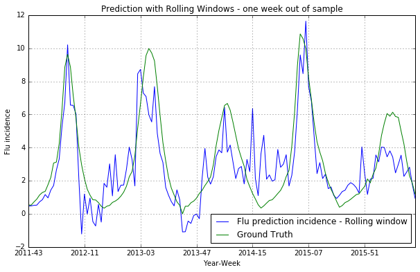

```python
flu_pred_rol.plot(legend=True, label='Flu prediction incidence - Rolling window')
gt_ts[flu_pred_rol.index].plot(legend=True, label=('Ground Truth'))
plt.title('Prediction with Rolling Windows - one week out of sample')
plt.xlabel('Year-Week')
plt.ylabel('Flu incidence')
plt.grid()
plt.show()
```

As we could see in this plot, it is equal to the entire hourly dataset.

#### Build a model - model 2 - Structural Break

At this point we consider the possibilities of a structural break at each season. To consider this case, we introduce one dummy for each season.

We start re-searching the top 5 feature.

```python
# F-test
f_test, _ = f_regression(df_norm,gt_ts)
f_test = normalize([f_test])[0]

# Mutual Information
mi = mutual_info_regression(df_norm,gt_ts)
mi = normalize([mi])[0]

# Cross-Correlation
corr = [crossCorr(gt_ts, df_norm[i])[0] for i in list(df_norm.columns)]
corr = normalize([corr])[0]

# Score
score = np.mean([f_test,mi,corr], axis=0)
```

```python
sort_index_f_test = sorted(range(len(f_test)), key=np.abs(f_test).__getitem__, reverse=True)
sort_index_mi = sorted(range(len(mi)), key=np.abs(mi).__getitem__, reverse=True)
sort_index_corr = sorted(range(len(corr)), key=np.abs(corr).__getitem__, reverse=True)
sort_index_score = sorted(range(len(score)), key=np.abs(score).__getitem__, reverse=True)
```

```python
# Select the top k elements
k = 5
```

```python
f_test_col = ['\033[36m%.4f\033[0m' if i  in sort_index_f_test[0:5] else '\033[30m%.4f' for i in range(len(df_norm.columns))]
mi_col     = ['\033[36m%.4f\033[0m' if i in sort_index_mi[0:k] else '\033[30m%.4f' for i in range(len(df_norm.columns))]
corr_col   = ['\033[36m%.4f\033[0m' if i in sort_index_corr[0:k] else '\033[30m%.4f' for i in range(len(df_norm.columns))]
score_col  = ['\033[36m%.4f\033[0m' if i in sort_index_score[0:k] else '\033[30m%.4f' for i in range(len(df_norm.columns))]
feat_col   = ['\033[46m%s\033[0m' if i in sort_index_score[0:k] else '\033[30m%s' for i in range(len(df_norm.columns))]
```

```python
print ('\t'.join(['f_reg', 'mi', 'corr', 'score', 'feature']))
for i in range(len(df_norm.columns)):
    print('\t'.join([f_test_col[i], mi_col[i], corr_col[i], score_col[i], feat_col[i]]) % (f_test[i], f_test[i], corr[i], score[i], df_norm.columns[i][:33]))
```

```
f_reg	mi	corr	score	feature
0.1085	0.1085	0.2183	0.1678	Amantadina
0.2276	0.2276	0.2902	0.2444	Antivirale
0.0048	0.0048	0.0503	0.0496	Artralgia
0.0025	0.0025	-0.0366	-0.0125	Cefalea
0.0003	0.0003	0.0129	0.0120	Centro_europeo_per_la_prevenzione
0.0492	0.0492	0.1543	0.1071	Epidemia
0.1429	0.1429	0.2440	0.2568	Febbre
0.0036	0.0036	0.0433	0.0335	Fotofobia
0.6835	0.6835	0.3974	0.4573	Influenza
0.0204	0.0204	0.1020	0.0744	Influenza_aviaria
0.2712	0.2712	0.3081	0.2790	Influenzavirus_A
0.3202	0.3202	0.3250	0.3355	Influenzavirus_A_sottotipo_H1N1
0.0011	0.0011	-0.0236	0.0044	Istituto_superiore_di_sanità
0.0050	0.0050	0.0513	0.0297	Mialgia
0.3497	0.3497	0.3339	0.3628	Oseltamivir
0.0136	0.0136	0.0837	0.0562	Pandemia_influenzale
0.1089	0.1089	0.2186	0.1729	Paracetamolo
0.0397	0.0397	0.1397	0.0891	Raffreddore_comune
0.0739	0.0739	0.1852	0.1406	Rinorrea
0.0354	0.0354	0.1325	0.1103	Starnuto
0.0388	0.0388	0.1382	0.0907	Tosse
0.0832	0.0832	-0.1951	0.0171	Vaccino_antinfluenzale
0.0030	0.0030	0.0399	0.0522	Vomito
0.3446	0.3446	0.3324	0.3100	Zanamivir
```

```python
ind = np.argpartition(score, -k)[-k:]
ind = ind[np.argsort(score[ind], -1, )][::-1]
```

```python
print 'The top', k, 'features are:'
for i in range(len(ind)):
    print (i+1), ' with value ', round(score[ind[i]],4),'is', df_norm.columns[ind[i]]
```

```
The top 5 features are:
1  with value  0.4573 is Influenza
2  with value  0.3628 is Oseltamivir
3  with value  0.3355 is Influenzavirus_A_sottotipo_H1N1
4  with value  0.31 is Zanamivir
5  with value  0.279 is Influenzavirus_A
```

Create the dummy variables for each season. As discriminant factor I have used 26 as the mean value of 52 week: if the value is smaller the season is the previous, if it is greater the season is the next.

```python
yr = sorted(list(set([int(x.split('-')[0]) for x in df_top.index.values])))
```

```python
yr_id = [(yr.index(int(x.split('-')[0]))-1) if int(x.split('-')[1])<=26 else (yr.index(int(x.split('-')[0]))) for x in df_top.index.values]
```

```python
yr_dummies = pd.get_dummies(yr_id).astype(np.int8)
yr_dummies.set_index(gt_ts.index, inplace = True)
df_an = pd.concat([df_top,yr_dummies], axis=1)
names = list(df_top.columns.values)
names.extend(['Season0','Season1','Season2','Season3','Season4'])
df_an.columns = names
df_an
```

|  | Influenza | Oseltamivir | Influenzavirus_A_sottotipo_H1N1 | Zanamivir | Influenzavirus_A | Season0 | Season1 | Season2 | Season3 | Season4 |
| --- | --- | --- | --- | --- | --- | --- | --- | --- | --- | --- |
| 2011-42 | 0.000013 | 1.072135e-06 | 0.000003 | 7.290519e-07 | 8.577081e-07 | 1 | 0 | 0 | 0 | 0 |
| 2011-43 | 0.000011 | 1.177480e-06 | 0.000003 | 6.742836e-07 | 6.440918e-07 | 1 | 0 | 0 | 0 | 0 |
| 2011-44 | 0.000012 | 1.093330e-06 | 0.000004 | 5.696341e-07 | 1.093330e-06 | 1 | 0 | 0 | 0 | 0 |
| 2011-45 | 0.000012 | 1.083432e-06 | 0.000004 | 5.007458e-07 | 6.373129e-07 | 1 | 0 | 0 | 0 | 0 |
| 2011-46 | 0.000013 | 1.152236e-06 | 0.000003 | 6.276408e-07 | 9.086740e-07 | 1 | 0 | 0 | 0 | 0 |
| 2011-47 | 0.000015 | 1.298357e-06 | 0.000004 | 5.591466e-07 | 9.666602e-07 | 1 | 0 | 0 | 0 | 0 |
| 2011-48 | 0.000015 | 1.165627e-06 | 0.000006 | 7.513956e-07 | 1.069294e-06 | 1 | 0 | 0 | 0 | 0 |
| 2011-49 | 0.000014 | 1.591312e-06 | 0.000004 | 9.290892e-07 | 1.077348e-06 | 1 | 0 | 0 | 0 | 0 |
| 2011-50 | 0.000014 | 1.201149e-06 | 0.000004 | 6.630342e-07 | 8.744364e-07 | 1 | 0 | 0 | 0 | 0 |
| 2011-51 | 0.000015 | 1.464593e-06 | 0.000005 | 6.328489e-07 | 1.175291e-06 | 1 | 0 | 0 | 0 | 0 |
| 2011-52 | 0.000018 | 1.241529e-06 | 0.000004 | 6.872752e-07 | 6.983603e-07 | 1 | 0 | 0 | 0 | 0 |
| 2012-01 | 0.000017 | 1.293574e-06 | 0.000004 | 6.092318e-07 | 9.263661e-07 | 1 | 0 | 0 | 0 | 0 |
| 2012-02 | 0.000018 | 1.496395e-06 | 0.000005 | 8.083972e-07 | 9.029969e-07 | 1 | 0 | 0 | 0 | 0 |
| 2012-03 | 0.000019 | 2.211018e-06 | 0.000005 | 7.643026e-07 | 9.553782e-07 | 1 | 0 | 0 | 0 | 0 |
| 2012-04 | 0.000022 | 2.229861e-06 | 0.000005 | 1.244573e-06 | 1.192716e-06 | 1 | 0 | 0 | 0 | 0 |
| 2012-05 | 0.000023 | 2.511898e-06 | 0.000005 | 1.539828e-06 | 1.178527e-06 | 1 | 0 | 0 | 0 | 0 |
| 2012-06 | 0.000019 | 2.189592e-06 | 0.000004 | 1.211797e-06 | 1.270298e-06 | 1 | 0 | 0 | 0 | 0 |
| 2012-07 | 0.000019 | 1.941846e-06 | 0.000004 | 1.124689e-06 | 1.019249e-06 | 1 | 0 | 0 | 0 | 0 |
| 2012-08 | 0.000020 | 1.745514e-06 | 0.000005 | 1.072118e-06 | 9.126291e-07 | 1 | 0 | 0 | 0 | 0 |
| 2012-09 | 0.000015 | 1.283733e-06 | 0.000004 | 6.507812e-07 | 1.007374e-06 | 1 | 0 | 0 | 0 | 0 |
| 2012-10 | 0.000011 | 9.553328e-07 | 0.000004 | 6.678055e-07 | 6.492553e-07 | 1 | 0 | 0 | 0 | 0 |
| 2012-11 | 0.000012 | 1.073835e-06 | 0.000003 | 7.684327e-07 | 8.472463e-07 | 1 | 0 | 0 | 0 | 0 |
| 2012-12 | 0.000009 | 1.015910e-06 | 0.000003 | 5.632769e-07 | 8.449153e-07 | 1 | 0 | 0 | 0 | 0 |
| 2012-13 | 0.000010 | 1.049634e-06 | 0.000003 | 6.963919e-07 | 8.578741e-07 | 1 | 0 | 0 | 0 | 0 |
| 2012-14 | 0.000008 | 9.501452e-07 | 0.000002 | 4.801809e-07 | 7.049464e-07 | 1 | 0 | 0 | 0 | 0 |
| 2012-15 | 0.000008 | 6.984937e-07 | 0.000003 | 5.029154e-07 | 8.009394e-07 | 1 | 0 | 0 | 0 | 0 |
| 2012-16 | 0.000008 | 1.000477e-06 | 0.000004 | 5.797155e-07 | 7.667205e-07 | 1 | 0 | 0 | 0 | 0 |
| 2012-17 | 0.000007 | 7.396940e-07 | 0.000003 | 5.158392e-07 | 7.980909e-07 | 1 | 0 | 0 | 0 | 0 |
| 2012-42 | 0.000013 | 1.201244e-06 | 0.000004 | 5.594837e-07 | 6.417607e-07 | 0 | 1 | 0 | 0 | 0 |
| 2012-43 | 0.000013 | 1.179048e-06 | 0.000003 | 5.567727e-07 | 7.696564e-07 | 0 | 1 | 0 | 0 | 0 |
| ... | ... | ... | ... | ... | ... | ... | ... | ... | ... | ... |
| 2015-16 | 0.000007 | 1.014211e-06 | 0.000003 | 5.759716e-07 | 1.089338e-06 | 0 | 0 | 0 | 1 | 0 |
| 2015-17 | 0.000007 | 7.174352e-07 | 0.000003 | 6.308482e-07 | 9.029788e-07 | 0 | 0 | 0 | 1 | 0 |
| 2015-42 | 0.000010 | 9.896840e-07 | 0.000003 | 3.996801e-07 | 9.706516e-07 | 0 | 0 | 0 | 0 | 1 |
| 2015-43 | 0.000010 | 6.014429e-07 | 0.000004 | 3.608658e-07 | 1.483559e-06 | 0 | 0 | 0 | 0 | 1 |
| 2015-44 | 0.000010 | 8.422656e-07 | 0.000003 | 4.612407e-07 | 1.383722e-06 | 0 | 0 | 0 | 0 | 1 |
| 2015-45 | 0.000011 | 9.496632e-07 | 0.000002 | 5.887912e-07 | 1.025636e-06 | 0 | 0 | 0 | 0 | 1 |
| 2015-46 | 0.000010 | 7.817886e-07 | 0.000003 | 7.073326e-07 | 1.060999e-06 | 0 | 0 | 0 | 0 | 1 |
| 2015-47 | 0.000010 | 8.877312e-07 | 0.000002 | 6.340937e-07 | 1.395006e-06 | 0 | 0 | 0 | 0 | 1 |
| 2015-48 | 0.000011 | 8.850669e-07 | 0.000003 | 5.461051e-07 | 1.073379e-06 | 0 | 0 | 0 | 0 | 1 |
| 2015-49 | 0.000011 | 8.491144e-07 | 0.000003 | 4.245572e-07 | 1.042095e-06 | 0 | 0 | 0 | 0 | 1 |
| 2015-50 | 0.000010 | 1.004248e-06 | 0.000003 | 1.358688e-06 | 1.693438e-06 | 0 | 0 | 0 | 0 | 1 |
| 2015-51 | 0.000012 | 1.058324e-06 | 0.000002 | 7.937431e-07 | 1.180439e-06 | 0 | 0 | 0 | 0 | 1 |
| 2015-52 | 0.000010 | 1.025797e-06 | 0.000003 | 4.771149e-07 | 8.110953e-07 | 0 | 0 | 0 | 0 | 1 |
| 2015-53 | 0.000011 | 1.246322e-06 | 0.000007 | 6.647049e-07 | 6.231608e-07 | 0 | 0 | 0 | 0 | 1 |
| 2016-01 | 0.000011 | 1.029963e-06 | 0.000004 | 5.403085e-07 | 1.671579e-06 | 0 | 0 | 0 | 0 | 1 |
| 2016-02 | 0.000012 | 1.233387e-06 | 0.000006 | 6.084707e-07 | 2.812121e-06 | 0 | 0 | 0 | 0 | 1 |
| 2016-03 | 0.000013 | 2.035614e-06 | 0.000005 | 6.729303e-07 | 1.379507e-06 | 0 | 0 | 0 | 0 | 1 |
| 2016-04 | 0.000012 | 2.366834e-06 | 0.000007 | 8.002962e-07 | 1.975199e-06 | 0 | 0 | 0 | 0 | 1 |
| 2016-05 | 0.000013 | 1.851464e-06 | 0.000007 | 8.006331e-07 | 1.968223e-06 | 0 | 0 | 0 | 0 | 1 |
| 2016-06 | 0.000013 | 1.457624e-06 | 0.000006 | 6.791200e-07 | 1.855157e-06 | 0 | 0 | 0 | 0 | 1 |
| 2016-07 | 0.000013 | 2.032383e-06 | 0.000006 | 7.054554e-07 | 1.830825e-06 | 0 | 0 | 0 | 0 | 1 |
| 2016-08 | 0.000014 | 1.804342e-06 | 0.000006 | 5.080186e-07 | 1.874413e-06 | 0 | 0 | 0 | 0 | 1 |
| 2016-09 | 0.000011 | 1.425243e-06 | 0.000006 | 5.030268e-07 | 1.391708e-06 | 0 | 0 | 0 | 0 | 1 |
| 2016-10 | 0.000012 | 1.725427e-06 | 0.000005 | 5.634047e-07 | 1.443725e-06 | 0 | 0 | 0 | 0 | 1 |
| 2016-11 | 0.000013 | 1.334525e-06 | 0.000006 | 7.550603e-07 | 1.580359e-06 | 0 | 0 | 0 | 0 | 1 |
| 2016-12 | 0.000011 | 1.143864e-06 | 0.000005 | 4.575454e-07 | 1.372636e-06 | 0 | 0 | 0 | 0 | 1 |
| 2016-13 | 0.000013 | 9.615744e-07 | 0.000005 | 3.949323e-07 | 1.425191e-06 | 0 | 0 | 0 | 0 | 1 |
| 2016-14 | 0.000010 | 1.299679e-06 | 0.000006 | 8.099447e-07 | 1.375022e-06 | 0 | 0 | 0 | 0 | 1 |
| 2016-15 | 0.000009 | 6.084034e-07 | 0.000006 | 5.495256e-07 | 1.432692e-06 | 0 | 0 | 0 | 0 | 1 |
| 2016-16 | 0.000009 | 5.559166e-07 | 0.000004 | 4.632638e-07 | 8.709360e-07 | 0 | 0 | 0 | 0 | 1 |

140 rows × 10 columns

And then try with linear regression model to verify if the dummy coefficients are significants or not.

```python
id_train, id_test = train_test_split(range(len(gt_ts.index)), train_size = 0.7, test_size = 0.3)
```

```python
X_train = df_an.iloc[id_train]
X_test = df_an.iloc[id_test]
y_train = gt_ts.iloc[id_train]
y_test = gt_ts.iloc[id_test]
```

```python
reg = linear_model.LinearRegression(fit_intercept=True, normalize=True).fit(X_train,y_train)
```

```python
sse = np.sum((reg.predict(X_train) - y_train) ** 2, axis=0) / float(X_train.shape[0] - X_train.shape[1])
se = np.array([np.sqrt(np.diagonal(sse * np.linalg.inv(np.dot(X_train.T, X_train))))])
t = reg.coef_ / se
p = 2 * (1 - stats.t.cdf(np.abs(t), y_train.shape[0] - X_train.shape[1]))
```

```python
# The intercept
print 'Intercept: \n', reg.intercept_
```

```
Intercept:
-4.48036745137
```

```python
print '\t'.join(['Coefficient','t-stat','p-value','feature'])
for i in range(len(df_top.columns)):
    print '\t'.join(['%.4f','%.4f','%.4f','%s']) % (reg.coef_[i],t[0][i],p[0][i],df_an.columns[i])
for i in range(len(df_top.columns), len(df_an.columns)):
    print '\t'.join(['%.4f','\t%.4f','%.4f','%s']) % (reg.coef_[i],t[0][i],p[0][i],df_an.columns[i])
```

```
Coefficient	t-stat	p-value	feature
219895.6339	6.6028	0.0000	Influenza
2911574.6823	6.1881	0.0000	Oseltamivir
137983.6746	2.6715	0.0090	Influenzavirus_A_sottotipo_H1N1
-241248.7538	-0.3236	0.7470	Zanamivir
295500.5444	0.6020	0.5487	Influenzavirus_A
-0.2400		-0.4720	0.6381	Season0
-1.2366		-2.2399	0.0276	Season1
1.1326		2.3722	0.0199	Season2
0.1345		0.2253	0.8223	Season3
0.3886		0.6477	0.5188	Season4
```

```python
kf = KFold(n_splits=10, shuffle=True).split(df_an.index)
models = ['LinearRegression','Ridge','Lasso','Bayesian','Polynomial']
mse = {m:[] for m in models}
alphas = [0.01,0.02,0.05,0.08,0.1,0.2,0.5,0.8,1,2,5,8]
```

```python
for tr, te in kf:
    X_train = df_an.iloc[tr]
    X_test = df_an.iloc[te]
    y_train = gt_ts.iloc[tr]
    y_test = gt_ts.iloc[te]

    ### Ordinary least squares Linear Regression
    reg = linear_model.LinearRegression(fit_intercept=True, normalize=True).fit(X_train,y_train)
    mse['LinearRegression'].append(np.mean((reg.predict(X_test) - y_test) ** 2))

    ### Ridge Regression
    ridge_cv = linear_model.RidgeCV(fit_intercept=True, normalize=True, alphas = alphas).fit(X_train, y_train)
    ridge = linear_model.Ridge(fit_intercept=True, normalize=True, alpha = round(ridge_cv.alpha_,3)).fit(X_train, y_train)
    mse['Ridge'].append(np.mean((ridge.predict(X_test) - y_test) ** 2))

    ### Lasso Regression
    lasso_cv = linear_model.LassoCV(fit_intercept=True, normalize=True, alphas=alphas).fit(X_train, y_train)
    lasso = linear_model.Lasso(fit_intercept=True, normalize=True, alpha = round(lasso_cv.alpha_,3)).fit(X_train, y_train)
    mse['Lasso'].append(np.mean((lasso.predict(X_test) - y_test) ** 2))

    ### Bayesian Ridge Regression
    bay = linear_model.BayesianRidge(fit_intercept=True, normalize=True).fit(X_train, y_train)
    mse['Bayesian'].append(np.mean((bay.predict(X_test) - y_test) ** 2))

    ### Polynomial Regression
    pol = Pipeline([('poly', PolynomialFeatures(degree=2)),
                    ('linear', linear_model.LinearRegression(fit_intercept=True, normalize=True))]).fit(X_train, y_train)
    mse['Polynomial'].append(np.mean((pol.predict(X_test) - y_test) ** 2))
```

```python
mse_mean = {k: np.mean(mse[k]) for k in models}
print 'MSE models means'
for k, v in mse_mean.iteritems():
    print round(v,6),'\t', k
print '\nThe model with the minimum MSE', min(mse_mean.values()),'is', min(mse_mean, key=mse_mean.get)
```

```
MSE models means
2.879307 	Bayesian
2.714751 	Ridge
20.824629 	Polynomial
3.004026 	LinearRegression
3.352034 	Lasso

The model with the minimum MSE 2.71475089584 is Ridge
```

And even with this dataframe the model with the minimum MSE is Ridge.

#### Build a model - model 3 - Shift

In this model we dig up the strange thing that we have seen in the part 2.1: Vaccino_antinfluenzale seems to have an high correlation with ground truth but it require a shift. To not limit the shift only to Vaccino_antinfluenzale series we extend this approach to all series. In particular we compute the cross-correlation between ground truth and each series with shift varying from 0 to 20.

To have more completed series we reload the raw dataframe with values from the beginning of October to the end of April.

```python
df_shift = df_raw.copy()

df_shift_norm = df_shift.divide(df_shift['totalViews'], axis='index')
del df_shift_norm['totalViews']
df_shift_norm.fillna(0, inplace=True)
```

```python
c_shift = {c:[] for c in df_shift_norm.columns}
c_s_idx = {c:[] for c in df_shift_norm.columns}
for c in df_shift_norm.columns:
    c_shift[c].append([crossCorr(gt_ts, df_shift_norm[c].shift(i)[gt_ts.index].fillna(0))[0] for i in range(20)])
    c_s_idx[c].append(c_shift[c][0].index(max(c_shift[c][0], key=abs)))
c_s_idx
```

```
{'Amantadina': [0],
 'Antivirale': [0],
 'Artralgia': [16],
 'Cefalea': [14],
 'Centro_europeo_per_la_prevenzione_e_il_controllo_delle_malattie': [9],
 'Epidemia': [0],
 'Febbre': [0],
 'Fotofobia': [16],
 'Influenza': [1],
 'Influenza_aviaria': [0],
 'Influenzavirus_A': [0],
 'Influenzavirus_A_sottotipo_H1N1': [0],
 'Istituto_superiore_di_sanita\xcc\x80': [16],
 'Mialgia': [15],
 'Oseltamivir': [0],
 'Pandemia_influenzale': [0],
 'Paracetamolo': [1],
 'Raffreddore_comune': [5],
 'Rinorrea': [0],
 'Starnuto': [0],
 'Tosse': [2],
 'Vaccino_antinfluenzale': [11],
 'Vomito': [5],
 'Zanamivir': [1]}
```

As we have seen in part 2.1 the Vaccino_influenzale series have a greater cross-correlation with ground truth if we shift it of 11 week.

```python
for c in df_shift_norm.columns:
    df_shift_norm[c] = df_shift_norm[c].shift(c_s_idx[c][0])[gt_ts.index].fillna(0)
df_shift_norm = df_shift_norm.loc[gt_ts.index]
df_shift_norm
```

|  | Amantadina | Antivirale | Artralgia | Cefalea | Centro_europeo_per_la_prevenzione_e_il_controllo_delle_malattie | Epidemia | Febbre | Fotofobia | Influenza | Influenza_aviaria | ... | Oseltamivir | Pandemia_influenzale | Paracetamolo | Raffreddore_comune | Rinorrea | Starnuto | Tosse | Vaccino_antinfluenzale | Vomito | Zanamivir |
| --- | --- | --- | --- | --- | --- | --- | --- | --- | --- | --- | --- | --- | --- | --- | --- | --- | --- | --- | --- | --- | --- |
| 2011-42 | 0.000002 | 0.000002 | 0.000000 | 0.000000 | 0.000000e+00 | 0.000004 | 0.000038 | 0.000000 | 0.000012 | 0.000003 | ... | 1.072135e-06 | 1.211513e-06 | 0.000046 | 0.000000 | 0.000004 | 0.000005 | 0.000011 | 0.000000e+00 | 0.000000 | 5.177115e-07 |
| 2011-43 | 0.000002 | 0.000002 | 0.000000 | 0.000000 | 0.000000e+00 | 0.000004 | 0.000037 | 0.000000 | 0.000013 | 0.000004 | ... | 1.177480e-06 | 8.353066e-07 | 0.000048 | 0.000000 | 0.000004 | 0.000005 | 0.000016 | 0.000000e+00 | 0.000000 | 7.290519e-07 |
| 2011-44 | 0.000002 | 0.000003 | 0.000000 | 0.000000 | 0.000000e+00 | 0.000004 | 0.000036 | 0.000000 | 0.000011 | 0.000003 | ... | 1.093330e-06 | 9.187647e-07 | 0.000049 | 0.000018 | 0.000003 | 0.000005 | 0.000018 | 0.000000e+00 | 0.000017 | 6.742836e-07 |
| 2011-45 | 0.000002 | 0.000002 | 0.000000 | 0.000000 | 0.000000e+00 | 0.000004 | 0.000038 | 0.000000 | 0.000012 | 0.000003 | ... | 1.083432e-06 | 8.467157e-07 | 0.000046 | 0.000015 | 0.000003 | 0.000004 | 0.000020 | 0.000000e+00 | 0.000013 | 5.696341e-07 |
| 2011-46 | 0.000003 | 0.000002 | 0.000000 | 0.000000 | 0.000000e+00 | 0.000004 | 0.000039 | 0.000000 | 0.000012 | 0.000003 | ... | 1.152236e-06 | 8.712029e-07 | 0.000044 | 0.000022 | 0.000004 | 0.000005 | 0.000020 | 0.000000e+00 | 0.000018 | 5.007458e-07 |
| 2011-47 | 0.000002 | 0.000003 | 0.000000 | 0.000000 | 0.000000e+00 | 0.000004 | 0.000041 | 0.000000 | 0.000013 | 0.000004 | ... | 1.298357e-06 | 1.108816e-06 | 0.000046 | 0.000020 | 0.000004 | 0.000005 | 0.000021 | 0.000000e+00 | 0.000018 | 6.276408e-07 |
| 2011-48 | 0.000002 | 0.000003 | 0.000000 | 0.000000 | 1.815547e-07 | 0.000005 | 0.000042 | 0.000000 | 0.000015 | 0.000014 | ... | 1.165627e-06 | 1.165627e-06 | 0.000062 | 0.000018 | 0.000004 | 0.000005 | 0.000020 | 0.000000e+00 | 0.000018 | 5.591466e-07 |
| 2011-49 | 0.000002 | 0.000002 | 0.000000 | 0.000000 | 2.366098e-07 | 0.000004 | 0.000041 | 0.000000 | 0.000015 | 0.000005 | ... | 1.591312e-06 | 9.093213e-07 | 0.000049 | 0.000016 | 0.000004 | 0.000005 | 0.000022 | 0.000000e+00 | 0.000020 | 7.513956e-07 |
| 2011-50 | 0.000002 | 0.000003 | 0.000000 | 0.000000 | 2.535730e-07 | 0.000004 | 0.000042 | 0.000000 | 0.000014 | 0.000004 | ... | 1.201149e-06 | 1.028183e-06 | 0.000047 | 0.000014 | 0.000004 | 0.000005 | 0.000021 | 0.000000e+00 | 0.000019 | 9.290892e-07 |
| 2011-51 | 0.000002 | 0.000003 | 0.000000 | 0.000000 | 5.467889e-07 | 0.000004 | 0.000045 | 0.000000 | 0.000014 | 0.000014 | ... | 1.464593e-06 | 1.265698e-06 | 0.000047 | 0.000017 | 0.000003 | 0.000005 | 0.000020 | 0.000000e+00 | 0.000020 | 6.630342e-07 |
| 2011-52 | 0.000002 | 0.000002 | 0.000000 | 0.000000 | 3.421738e-07 | 0.000003 | 0.000054 | 0.000000 | 0.000015 | 0.000007 | ... | 1.241529e-06 | 9.200619e-07 | 0.000063 | 0.000017 | 0.000003 | 0.000005 | 0.000019 | 0.000000e+00 | 0.000022 | 6.328489e-07 |
| 2012-01 | 0.000002 | 0.000003 | 0.000000 | 0.000014 | 2.480665e-07 | 0.000004 | 0.000050 | 0.000000 | 0.000018 | 0.000004 | ... | 1.293574e-06 | 1.168390e-06 | 0.000066 | 0.000018 | 0.000004 | 0.000005 | 0.000020 | 0.000000e+00 | 0.000023 | 6.872752e-07 |
| 2012-02 | 0.000003 | 0.000003 | 0.000000 | 0.000013 | 2.185073e-07 | 0.000004 | 0.000051 | 0.000000 | 0.000017 | 0.000005 | ... | 1.496395e-06 | 9.115968e-07 | 0.000057 | 0.000015 | 0.000004 | 0.000005 | 0.000021 | 0.000000e+00 | 0.000021 | 6.092318e-07 |
| 2012-03 | 0.000003 | 0.000003 | 0.000003 | 0.000017 | 3.653432e-07 | 0.000004 | 0.000058 | 0.000004 | 0.000018 | 0.000005 | ... | 2.211018e-06 | 1.046367e-06 | 0.000055 | 0.000015 | 0.000003 | 0.000005 | 0.000022 | 0.000000e+00 | 0.000020 | 8.083972e-07 |
| 2012-04 | 0.000003 | 0.000003 | 0.000003 | 0.000016 | 3.032659e-07 | 0.000005 | 0.000060 | 0.000003 | 0.000019 | 0.000005 | ... | 2.229861e-06 | 1.279145e-06 | 0.000057 | 0.000021 | 0.000004 | 0.000005 | 0.000024 | 3.587161e-06 | 0.000021 | 7.643026e-07 |
| 2012-05 | 0.000003 | 0.000003 | 0.000004 | 0.000017 | 2.600985e-07 | 0.000004 | 0.000066 | 0.000004 | 0.000022 | 0.000004 | ... | 2.511898e-06 | 1.281756e-06 | 0.000054 | 0.000021 | 0.000004 | 0.000005 | 0.000024 | 7.737781e-06 | 0.000027 | 1.244573e-06 |
| 2012-06 | 0.000003 | 0.000003 | 0.000004 | 0.000019 | 2.174464e-07 | 0.000004 | 0.000060 | 0.000005 | 0.000023 | 0.000004 | ... | 2.189592e-06 | 1.195083e-06 | 0.000060 | 0.000020 | 0.000003 | 0.000005 | 0.000024 | 1.069960e-05 | 0.000023 | 1.539828e-06 |
| 2012-07 | 0.000003 | 0.000003 | 0.000004 | 0.000021 | 2.498390e-07 | 0.000004 | 0.000061 | 0.000005 | 0.000019 | 0.000004 | ... | 1.941846e-06 | 8.523033e-07 | 0.000059 | 0.000018 | 0.000003 | 0.000005 | 0.000024 | 7.330924e-06 | 0.000024 | 1.211797e-06 |
| 2012-08 | 0.000003 | 0.000003 | 0.000004 | 0.000019 | 2.893023e-07 | 0.000004 | 0.000064 | 0.000005 | 0.000019 | 0.000004 | ... | 1.745514e-06 | 9.746525e-07 | 0.000057 | 0.000017 | 0.000007 | 0.000006 | 0.000022 | 4.477419e-06 | 0.000023 | 1.124689e-06 |
| 2012-09 | 0.000002 | 0.000003 | 0.000004 | 0.000021 | 1.995315e-07 | 0.000004 | 0.000051 | 0.000006 | 0.000020 | 0.000004 | ... | 1.283733e-06 | 1.043033e-06 | 0.000054 | 0.000020 | 0.000004 | 0.000006 | 0.000022 | 3.315171e-06 | 0.000020 | 1.072118e-06 |
| 2012-10 | 0.000002 | 0.000002 | 0.000004 | 0.000020 | 2.253323e-07 | 0.000004 | 0.000047 | 0.000005 | 0.000015 | 0.000004 | ... | 9.553328e-07 | 1.085184e-06 | 0.000048 | 0.000019 | 0.000004 | 0.000006 | 0.000021 | 2.657965e-06 | 0.000020 | 6.507812e-07 |
| 2012-11 | 0.000002 | 0.000003 | 0.000004 | 0.000019 | 2.063993e-07 | 0.000005 | 0.000041 | 0.000005 | 0.000011 | 0.000004 | ... | 1.073835e-06 | 3.901274e-06 | 0.000065 | 0.000018 | 0.000004 | 0.000005 | 0.000019 | 1.773613e-06 | 0.000019 | 6.678055e-07 |
| 2012-12 | 0.000002 | 0.000003 | 0.000004 | 0.000019 | 2.092733e-07 | 0.000004 | 0.000039 | 0.000005 | 0.000012 | 0.000004 | ... | 1.015910e-06 | 1.287490e-06 | 0.000041 | 0.000019 | 0.000004 | 0.000005 | 0.000019 | 1.493870e-06 | 0.000023 | 7.684327e-07 |
| 2012-13 | 0.000002 | 0.000003 | 0.000004 | 0.000016 | 2.247147e-07 | 0.000004 | 0.000033 | 0.000005 | 0.000009 | 0.000004 | ... | 1.049634e-06 | 1.009264e-06 | 0.000035 | 0.000019 | 0.000004 | 0.000005 | 0.000017 | 1.694194e-06 | 0.000023 | 5.632769e-07 |
| 2012-14 | 0.000002 | 0.000002 | 0.000004 | 0.000015 | 2.064574e-07 | 0.000004 | 0.000032 | 0.000005 | 0.000010 | 0.000004 | ... | 9.501452e-07 | 7.764627e-07 | 0.000037 | 0.000017 | 0.000004 | 0.000005 | 0.000013 | 1.701483e-06 | 0.000023 | 6.963919e-07 |
| 2012-15 | 0.000002 | 0.000002 | 0.000004 | 0.000016 | 2.005733e-07 | 0.000004 | 0.000031 | 0.000005 | 0.000008 | 0.000004 | ... | 6.984937e-07 | 1.043084e-06 | 0.000033 | 0.000016 | 0.000003 | 0.000004 | 0.000011 | 1.719931e-06 | 0.000023 | 4.801809e-07 |
| 2012-16 | 0.000002 | 0.000003 | 0.000003 | 0.000018 | 1.933059e-07 | 0.000004 | 0.000037 | 0.000004 | 0.000008 | 0.000004 | ... | 1.000477e-06 | 1.047228e-06 | 0.000035 | 0.000015 | 0.000003 | 0.000004 | 0.000010 | 2.047369e-06 | 0.000020 | 5.029154e-07 |
| 2012-17 | 0.000002 | 0.000003 | 0.000004 | 0.000017 | 2.215119e-07 | 0.000005 | 0.000036 | 0.000004 | 0.000008 | 0.000003 | ... | 7.396940e-07 | 1.109541e-06 | 0.000036 | 0.000013 | 0.000004 | 0.000004 | 0.000009 | 1.587872e-06 | 0.000018 | 5.797155e-07 |
| 2012-42 | 0.000002 | 0.000003 | 0.000005 | 0.000017 | 2.414044e-07 | 0.000004 | 0.000035 | 0.000004 | 0.000013 | 0.000005 | ... | 1.201244e-06 | 1.522125e-06 | 0.000047 | 0.000010 | 0.000003 | 0.000006 | 0.000011 | 1.113009e-06 | 0.000019 | 4.826234e-07 |
| 2012-43 | 0.000002 | 0.000002 | 0.000005 | 0.000018 | 2.321306e-07 | 0.000004 | 0.000034 | 0.000005 | 0.000013 | 0.000005 | ... | 1.179048e-06 | 1.195424e-06 | 0.000048 | 0.000010 | 0.000003 | 0.000006 | 0.000012 | 1.320128e-06 | 0.000019 | 5.594837e-07 |
| ... | ... | ... | ... | ... | ... | ... | ... | ... | ... | ... | ... | ... | ... | ... | ... | ... | ... | ... | ... | ... | ... |
| 2015-16 | 0.000002 | 0.000002 | 0.000003 | 0.000010 | 4.732351e-07 | 0.000004 | 0.000015 | 0.000003 | 0.000009 | 0.000004 | ... | 1.014211e-06 | 7.512673e-07 | 0.000025 | 0.000012 | 0.000003 | 0.000004 | 0.000006 | 1.998273e-06 | 0.000011 | 6.395598e-07 |
| 2015-17 | 0.000002 | 0.000003 | 0.000003 | 0.000011 | 6.344514e-07 | 0.000004 | 0.000013 | 0.000003 | 0.000007 | 0.000003 | ... | 7.174352e-07 | 7.545439e-07 | 0.000026 | 0.000012 | 0.000003 | 0.000004 | 0.000006 | 2.907617e-06 | 0.000010 | 5.759716e-07 |
| 2015-42 | 0.000002 | 0.000003 | 0.000005 | 0.000011 | 5.428490e-07 | 0.000004 | 0.000017 | 0.000003 | 0.000012 | 0.000003 | ... | 9.896840e-07 | 8.183925e-07 | 0.000036 | 0.000008 | 0.000004 | 0.000004 | 0.000005 | 1.202751e-06 | 0.000008 | 4.406128e-07 |
| 2015-43 | 0.000002 | 0.000002 | 0.000005 | 0.000013 | 5.589526e-07 | 0.000005 | 0.000018 | 0.000004 | 0.000010 | 0.000004 | ... | 6.014429e-07 | 9.623087e-07 | 0.000038 | 0.000008 | 0.000003 | 0.000004 | 0.000006 | 1.433690e-06 | 0.000009 | 3.996801e-07 |
| 2015-44 | 0.000003 | 0.000002 | 0.000005 | 0.000012 | 6.063973e-07 | 0.000004 | 0.000017 | 0.000004 | 0.000010 | 0.000006 | ... | 8.422656e-07 | 1.283452e-06 | 0.000038 | 0.000008 | 0.000003 | 0.000004 | 0.000007 | 1.411407e-06 | 0.000009 | 3.608658e-07 |
| 2015-45 | 0.000002 | 0.000002 | 0.000006 | 0.000012 | 5.220897e-07 | 0.000005 | 0.000016 | 0.000004 | 0.000010 | 0.000004 | ... | 9.496632e-07 | 1.139596e-06 | 0.000036 | 0.000017 | 0.000003 | 0.000003 | 0.000007 | 1.325888e-06 | 0.000006 | 4.612407e-07 |
| 2015-46 | 0.000003 | 0.000002 | 0.000005 | 0.000011 | 9.140419e-07 | 0.000004 | 0.000015 | 0.000004 | 0.000011 | 0.000003 | ... | 7.817886e-07 | 1.079613e-06 | 0.000036 | 0.000019 | 0.000003 | 0.000003 | 0.000008 | 9.971866e-07 | 0.000008 | 5.887912e-07 |
| 2015-47 | 0.000002 | 0.000004 | 0.000005 | 0.000012 | 7.050657e-07 | 0.000004 | 0.000016 | 0.000004 | 0.000010 | 0.000003 | ... | 8.877312e-07 | 7.609124e-07 | 0.000032 | 0.000018 | 0.000003 | 0.000003 | 0.000007 | 1.031127e-06 | 0.000008 | 7.073326e-07 |
| 2015-48 | 0.000003 | 0.000002 | 0.000005 | 0.000011 | 6.030847e-07 | 0.000004 | 0.000018 | 0.000003 | 0.000010 | 0.000004 | ... | 8.850669e-07 | 1.280522e-06 | 0.000034 | 0.000016 | 0.000003 | 0.000004 | 0.000008 | 1.026732e-06 | 0.000008 | 6.340937e-07 |
| 2015-49 | 0.000003 | 0.000002 | 0.000005 | 0.000010 | 3.218143e-07 | 0.000004 | 0.000018 | 0.000004 | 0.000011 | 0.000006 | ... | 8.491144e-07 | 9.263067e-07 | 0.000034 | 0.000012 | 0.000003 | 0.000004 | 0.000006 | 1.236957e-06 | 0.000008 | 5.461051e-07 |
| 2015-50 | 0.000003 | 0.000002 | 0.000005 | 0.000011 | 4.589717e-07 | 0.000003 | 0.000019 | 0.000003 | 0.000011 | 0.000004 | ... | 1.004248e-06 | 9.254834e-07 | 0.000045 | 0.000012 | 0.000004 | 0.000004 | 0.000006 | 7.969333e-07 | 0.000008 | 4.245572e-07 |
| 2015-51 | 0.000003 | 0.000003 | 0.000004 | 0.000012 | 5.329068e-07 | 0.000003 | 0.000018 | 0.000004 | 0.000010 | 0.000003 | ... | 1.058324e-06 | 1.383962e-06 | 0.000040 | 0.000010 | 0.000004 | 0.000005 | 0.000006 | 2.503000e-06 | 0.000009 | 1.358688e-06 |
| 2015-52 | 0.000002 | 0.000003 | 0.000004 | 0.000012 | 3.809139e-07 | 0.000002 | 0.000016 | 0.000003 | 0.000012 | 0.000002 | ... | 1.025797e-06 | 1.001941e-06 | 0.000039 | 0.000009 | 0.000003 | 0.000004 | 0.000006 | 3.451467e-06 | 0.000008 | 7.937431e-07 |
| 2015-53 | 0.000002 | 0.000002 | 0.000007 | 0.000012 | 2.807552e-07 | 0.000003 | 0.000019 | 0.000004 | 0.000010 | 0.000005 | ... | 1.246322e-06 | 1.204778e-06 | 0.000040 | 0.000011 | 0.000004 | 0.000004 | 0.000007 | 5.538424e-06 | 0.000008 | 4.771149e-07 |
| 2016-01 | 0.000002 | 0.000002 | 0.000005 | 0.000011 | 5.128181e-07 | 0.000003 | 0.000020 | 0.000004 | 0.000011 | 0.000003 | ... | 1.029963e-06 | 1.080617e-06 | 0.000040 | 0.000012 | 0.000004 | 0.000004 | 0.000007 | 6.335199e-06 | 0.000008 | 6.647049e-07 |
| 2016-02 | 0.000003 | 0.000003 | 0.000005 | 0.000014 | 3.164383e-07 | 0.000004 | 0.000019 | 0.000003 | 0.000011 | 0.000005 | ... | 1.233387e-06 | 1.068935e-06 | 0.000036 | 0.000011 | 0.000003 | 0.000004 | 0.000007 | 5.474726e-06 | 0.000009 | 5.403085e-07 |
| 2016-03 | 0.000003 | 0.000003 | 0.000005 | 0.000013 | 2.536375e-07 | 0.000004 | 0.000018 | 0.000003 | 0.000012 | 0.000004 | ... | 2.035614e-06 | 1.160805e-06 | 0.000036 | 0.000013 | 0.000003 | 0.000005 | 0.000007 | 6.799589e-06 | 0.000008 | 6.084707e-07 |
| 2016-04 | 0.000003 | 0.000003 | 0.000008 | 0.000014 | 4.331178e-07 | 0.000005 | 0.000022 | 0.000006 | 0.000013 | 0.000004 | ... | 2.366834e-06 | 1.396261e-06 | 0.000035 | 0.000013 | 0.000004 | 0.000005 | 0.000008 | 7.129168e-06 | 0.000007 | 6.729303e-07 |
| 2016-05 | 0.000003 | 0.000003 | 0.000006 | 0.000013 | 3.280669e-07 | 0.000005 | 0.000025 | 0.000004 | 0.000012 | 0.000004 | ... | 1.851464e-06 | 1.317709e-06 | 0.000039 | 0.000016 | 0.000004 | 0.000004 | 0.000007 | 7.482306e-06 | 0.000010 | 8.002962e-07 |
| 2016-06 | 0.000003 | 0.000003 | 0.000004 | 0.000014 | 4.922784e-07 | 0.000006 | 0.000023 | 0.000004 | 0.000013 | 0.000004 | ... | 1.457624e-06 | 1.639826e-06 | 0.000039 | 0.000016 | 0.000004 | 0.000004 | 0.000007 | 6.176637e-06 | 0.000008 | 8.006331e-07 |
| 2016-07 | 0.000004 | 0.000003 | 0.000005 | 0.000013 | 4.681049e-07 | 0.000013 | 0.000024 | 0.000004 | 0.000013 | 0.000005 | ... | 2.032383e-06 | 1.142166e-06 | 0.000040 | 0.000013 | 0.000003 | 0.000005 | 0.000007 | 4.843812e-06 | 0.000009 | 6.791200e-07 |
| 2016-08 | 0.000003 | 0.000003 | 0.000005 | 0.000012 | 4.055477e-07 | 0.000008 | 0.000025 | 0.000004 | 0.000013 | 0.000004 | ... | 1.804342e-06 | 1.453984e-06 | 0.000037 | 0.000014 | 0.000004 | 0.000005 | 0.000007 | 3.071817e-06 | 0.000008 | 7.054554e-07 |
| 2016-09 | 0.000002 | 0.000003 | 0.000004 | 0.000013 | 3.738965e-07 | 0.000004 | 0.000021 | 0.000004 | 0.000014 | 0.000004 | ... | 1.425243e-06 | 2.079178e-06 | 0.000040 | 0.000015 | 0.000003 | 0.000004 | 0.000007 | 2.238763e-06 | 0.000009 | 5.080186e-07 |
| 2016-10 | 0.000002 | 0.000003 | 0.000004 | 0.000012 | 7.598088e-07 | 0.000004 | 0.000023 | 0.000004 | 0.000011 | 0.000004 | ... | 1.725427e-06 | 1.144416e-06 | 0.000035 | 0.000014 | 0.000003 | 0.000004 | 0.000007 | 2.027738e-06 | 0.000009 | 5.030268e-07 |
| 2016-11 | 0.000003 | 0.000002 | 0.000004 | 0.000013 | 3.782385e-07 | 0.000004 | 0.000022 | 0.000004 | 0.000012 | 0.000004 | ... | 1.334525e-06 | 9.833343e-07 | 0.000036 | 0.000012 | 0.000003 | 0.000003 | 0.000006 | 1.287866e-06 | 0.000008 | 5.634047e-07 |
| 2016-12 | 0.000002 | 0.000003 | 0.000004 | 0.000012 | 2.859954e-07 | 0.000003 | 0.000019 | 0.000003 | 0.000013 | 0.000003 | ... | 1.143864e-06 | 8.974929e-07 | 0.000036 | 0.000012 | 0.000003 | 0.000004 | 0.000007 | 1.401425e-06 | 0.000008 | 7.550603e-07 |
| 2016-13 | 0.000002 | 0.000002 | 0.000004 | 0.000009 | 3.405516e-07 | 0.000004 | 0.000018 | 0.000003 | 0.000011 | 0.000004 | ... | 9.615744e-07 | 7.211808e-07 | 0.000030 | 0.000012 | 0.000003 | 0.000004 | 0.000006 | 1.397838e-06 | 0.000008 | 4.575454e-07 |
| 2016-14 | 0.000002 | 0.000003 | 0.000004 | 0.000011 | 3.169173e-07 | 0.000004 | 0.000018 | 0.000003 | 0.000013 | 0.000004 | ... | 1.299679e-06 | 9.606320e-07 | 0.000029 | 0.000010 | 0.000003 | 0.000004 | 0.000005 | 1.598210e-06 | 0.000007 | 3.949323e-07 |
| 2016-15 | 0.000002 | 0.000003 | 0.000003 | 0.000010 | 4.140976e-07 | 0.000005 | 0.000018 | 0.000003 | 0.000010 | 0.000004 | ... | 6.084034e-07 | 7.457848e-07 | 0.000035 | 0.000009 | 0.000003 | 0.000004 | 0.000005 | 1.447344e-06 | 0.000008 | 8.099447e-07 |
| 2016-16 | 0.000003 | 0.000003 | 0.000003 | 0.000011 | 2.855415e-07 | 0.000003 | 0.000015 | 0.000003 | 0.000009 | 0.000004 | ... | 5.559166e-07 | 1.074772e-06 | 0.000031 | 0.000009 | 0.000003 | 0.000004 | 0.000005 | 1.567906e-06 | 0.000008 | 5.495256e-07 |

140 rows × 24 columns

```python
r,t,p = crossCorr(gt_ts, df_shift_norm['Vaccino_antinfluenzale'])

print 'Correlation between Ground Truth and shifted Vaccino_antinfluenzale'
print 'is:', round(r,4), 'with statistic test', round(t,4), 'and pvalue', p
```

```
Correlation between Ground Truth and shifted Vaccino_antinfluenzale
is: 0.7573 with statistic test 13.6206 and pvalue 0.0
```

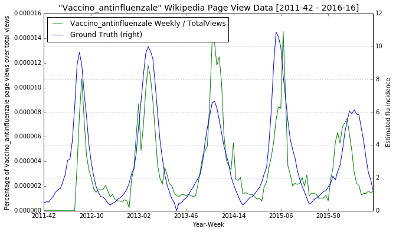

```python
df_shift_norm['Vaccino_antinfluenzale'].plot(legend=True, label='Vaccino_antinfluenzale Weekly / TotalViews', color='g')
plt.title('"Vaccino_antinfluenzale" Wikipedia Page View Data ['+ min(gt_ts.index)+' - '+max(gt_ts.index)+']', fontsize=14)
plt.xlabel('Year-Week')
plt.ylabel('Percentage of Vaccino_antinfluenzale page views over total views')
gt_ts.plot(legend=True, label='Ground Truth', secondary_y=True, color='b')
plt.ylabel('Estimated flu incidence')
plt.grid()
plt.show()
```

And now tried to fit a model, and see if this is better than the previous. and if there is some changing in the top 5 feature.

```python
# F-test
f_test, _ = f_regression(df_shift_norm,gt_ts)
f_test = normalize([f_test])[0]

# Mutual Information
mi = mutual_info_regression(df_shift_norm,gt_ts)
mi = normalize([mi])[0]

# Cross-Correlation
corr = [crossCorr(gt_ts, df_shift_norm[i])[0] for i in list(df_shift_norm.columns)]
corr = normalize([corr])[0]

# Score
score = np.mean([f_test,mi,corr], axis=0)
```

```python
sort_index_f_test = sorted(range(len(f_test)), key=np.abs(f_test).__getitem__, reverse=True)
sort_index_mi = sorted(range(len(mi)), key=np.abs(mi).__getitem__, reverse=True)
sort_index_corr = sorted(range(len(corr)), key=np.abs(corr).__getitem__, reverse=True)
sort_index_score = sorted(range(len(score)), key=np.abs(score).__getitem__, reverse=True)
```

```python
# Select the top k elements
k = 5
```

```python
f_test_col = ['\033[36m%.4f\033[0m' if i  in sort_index_f_test[0:5] else '\033[30m%.4f' for i in range(len(df_norm.columns))]
mi_col     = ['\033[36m%.4f\033[0m' if i in sort_index_mi[0:k] else '\033[30m%.4f' for i in range(len(df_norm.columns))]
corr_col   = ['\033[36m%.4f\033[0m' if i in sort_index_corr[0:k] else '\033[30m%.4f' for i in range(len(df_norm.columns))]
score_col  = ['\033[36m%.4f\033[0m' if i in sort_index_score[0:k] else '\033[30m%.4f' for i in range(len(df_norm.columns))]
feat_col   = ['\033[46m%s\033[0m' if i in sort_index_score[0:k] else '\033[30m%s' for i in range(len(df_norm.columns))]
```

```python
print ('\t'.join(['f_reg', 'mi', 'corr', 'score', 'feature']))
for i in range(len(df_shift_norm.columns)):
    print('\t'.join([f_test_col[i], mi_col[i], corr_col[i], score_col[i], feat_col[i]]) % (f_test[i], f_test[i], corr[i], score[i], df_shift_norm.columns[i][:33]))
```

```
f_reg	mi	corr	score	feature
0.0863	0.0863	0.1968	0.1496	Amantadina
0.1811	0.1811	0.2617	0.2162	Antivirale
0.0229	0.0229	0.1083	0.0599	Artralgia
0.0275	0.0275	0.1182	0.0908	Cefalea
0.0061	0.0061	0.0569	0.0449	Centro_europeo_per_la_prevenzione
0.0392	0.0392	0.1392	0.0953	Epidemia
0.1137	0.1137	0.2200	0.2313	Febbre
0.0066	0.0066	0.0591	0.0312	Fotofobia
0.5783	0.5783	0.3631	0.4325	Influenza
0.0163	0.0163	0.0920	0.0668	Influenza_aviaria
0.2157	0.2157	0.2778	0.2468	Influenzavirus_A
0.2548	0.2548	0.2930	0.2969	Influenzavirus_A_sottotipo_H1N1
0.0142	0.0142	0.0862	0.0647	Istituto_superiore_di_sanità
0.0435	0.0435	0.1460	0.1071	Mialgia
0.2782	0.2782	0.3011	0.3211	Oseltamivir
0.0108	0.0108	0.0755	0.0502	Pandemia_influenzale
0.0911	0.0911	0.2013	0.1691	Paracetamolo
0.0651	0.0651	0.1747	0.1368	Raffreddore_comune
0.0588	0.0588	0.1670	0.1257	Rinorrea
0.0282	0.0282	0.1195	0.1000	Starnuto
0.0411	0.0411	0.1423	0.0949	Tosse
0.5670	0.5670	0.3616	0.4137	Vaccino_antinfluenzale
0.0177	0.0177	0.0958	0.0684	Vomito
0.2791	0.2791	0.3013	0.2779	Zanamivir
```

```python
print 'The top feature is', df_shift_norm.columns[score.argmax()],'with score',  round(score.max(),4)
```

```
The top feature is Influenza with score 0.4325
```

```python
ind = np.argpartition(score, -k)[-k:]
ind = ind[np.argsort(score[ind], -1, )][::-1]
```

```python
print 'The top', k, 'features are:'
for i in range(len(ind)):
    print (i+1), ' with value ', round(score[ind[i]],4),'is', df_shift_norm.columns[ind[i]]
```

```
The top 5 features are:
1  with value  0.4325 is Influenza
2  with value  0.4137 is Vaccino_antinfluenzale
3  with value  0.3211 is Oseltamivir
4  with value  0.2969 is Influenzavirus_A_sottotipo_H1N1
5  with value  0.2779 is Zanamivir
```

```python
top_corr = np.corrcoef(df_norm[list(df_norm.columns[ind])], rowvar=0)
print top_corr
```

```
[[ 1.         -0.10712966  0.54288161  0.49994673  0.55222429]
 [-0.10712966  1.         -0.22492101 -0.18327278 -0.15074593]
 [ 0.54288161 -0.22492101  1.          0.5006891   0.62880622]
 [ 0.49994673 -0.18327278  0.5006891   1.          0.42860158]
 [ 0.55222429 -0.15074593  0.62880622  0.42860158  1.        ]]
```

In this case the matrix with correlation between the top 5 are more different and with a cross-correlation in some cases near to 0. Try to build a model.

```python
df_top = df_shift_norm[list(df_shift_norm.columns[ind])].copy()
```

```python
kf = KFold(n_splits=10, shuffle=True).split(df_top.index)
models = ['LinearRegression','Ridge','Lasso','Bayesian','Polynomial']
mse = {m:[] for m in models}
alphas = [0.01,0.02,0.05,0.08,0.1,0.2,0.5,0.8,1,2,5,8]
```

```python
for tr, te in kf:
    X_train = df_top.iloc[tr]
    X_test = df_top.iloc[te]
    y_train = gt_ts.iloc[tr]
    y_test = gt_ts.iloc[te]

    ### Ordinary least squares Linear Regression
    reg = linear_model.LinearRegression(fit_intercept=True, normalize=True).fit(X_train,y_train)
    mse['LinearRegression'].append(np.mean((reg.predict(X_test) - y_test) ** 2))

    ### Ridge Regression
    ridge_cv = linear_model.RidgeCV(fit_intercept=True, normalize=True, alphas = alphas).fit(X_train, y_train)
    ridge = linear_model.Ridge(fit_intercept=True, normalize=True, alpha = round(ridge_cv.alpha_,3)).fit(X_train, y_train)
    mse['Ridge'].append(np.mean((ridge.predict(X_test) - y_test) ** 2))

    ### Lasso Regression
    lasso_cv = linear_model.LassoCV(fit_intercept=True, normalize=True, alphas=alphas).fit(X_train, y_train)
    lasso = linear_model.Lasso(fit_intercept=True, normalize=True, alpha = round(lasso_cv.alpha_,3)).fit(X_train, y_train)
    mse['Lasso'].append(np.mean((lasso.predict(X_test) - y_test) ** 2))

    ### Bayesian Ridge Regression
    bay = linear_model.BayesianRidge(fit_intercept=True, normalize=True).fit(X_train, y_train)
    mse['Bayesian'].append(np.mean((bay.predict(X_test) - y_test) ** 2))

    ### Polynomial Regression
    pol = Pipeline([('poly', PolynomialFeatures(degree=2)),
                    ('linear', linear_model.LinearRegression(fit_intercept=True, normalize=True))]).fit(X_train, y_train)
    mse['Polynomial'].append(np.mean((pol.predict(X_test) - y_test) ** 2))
```

```python
mse_mean = {k: np.mean(mse[k]) for k in models}
print 'MSE models means'
for k, v in mse_mean.iteritems():
    print round(v,6),'\t', k
print '\nThe model with the minimum MSE', min(mse_mean.values()),'is', min(mse_mean, key=mse_mean.get)
```

```
MSE models means
1.986851 	Bayesian
1.948698 	Ridge
3.051199 	Polynomial
2.007723 	LinearRegression
2.018596 	Lasso

The model with the minimum MSE 1.94869845565 is Ridge
```

Ridge model is again the model with the lower MSE. Try to make prediction one obs out of sample.

```python
y_pred = []
for i in range(1,len(df_top.index)):
    X_train = df_top.iloc[:i]
    X_test = df_top.iloc[[i]]
    y_train = gt_ts.iloc[:i]
    y_test = gt_ts.iloc[[i]]
    ridge_cv = linear_model.RidgeCV(fit_intercept=True, normalize=True, alphas = alphas).fit(X_train, y_train)
    ridge = linear_model.Ridge(fit_intercept=True, normalize=True, alpha = round(ridge_cv.alpha_,3)).fit(X_train, y_train)
    y_pred.append(ridge.predict(X_test)[0])
```

```python
flu_pred_rol = pd.Series(y_pred, index=df_top.index[1:], name='flu_pred')
```

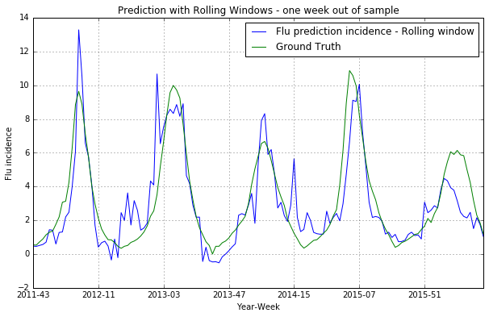

```python
flu_pred_rol.plot(legend=True, label='Flu prediction incidence - Rolling window')
gt_ts[flu_pred_rol.index].plot(legend=True, label=('Ground Truth'))
plt.title('Prediction with Rolling Windows - one week out of sample')
plt.xlabel('Year-Week')
plt.ylabel('Flu incidence')
plt.grid()
plt.show()
```

```python
r,t,p = crossCorr(gt_ts[flu_pred_rol.index], flu_pred_rol)
print 'The correlation between Ground Truth and Flu Prediction is:'
print 'Cross-Correlation',round(r,4), 'with statistic test', round(t,4), 'and pvalue', p
```

```
The correlation between Ground Truth and Flu Prediction is:
Cross-Correlation 0.8481 with statistic test 18.7349 and pvalue 0.0
```

An evident improvement we have done: the series predicted is more similar than the previous model and this is confirmed by cross correlation.

After that we try with a rolling window of 10 and 28 weeks to predict the next 1 week and see how it performs.

```python
windows = [10,28]
y_pred = {w:[] for w in windows}
```

```python
for w in windows:
    for i in range(len(df_top.index)-w):
        X_train = df_top.iloc[i:i+w]
        X_test = df_top.iloc[[i+w]]
        y_train = gt_ts.iloc[i:i+w]
        y_test = gt_ts.iloc[[i+w]]
        ridge_cv = linear_model.RidgeCV(fit_intercept=True, normalize=True, alphas = alphas).fit(X_train, y_train)
        ridge = linear_model.Ridge(fit_intercept=True, normalize=True, alpha = round(ridge_cv.alpha_,3)).fit(X_train, y_train)
        y_pred[w].append(ridge.predict(X_test)[0])
```

```python
flu_pred_rol = pd.concat([pd.Series(y_pred[w], index=df_top.index[w:], name=w) for w in windows], axis=1)
flu_pred_rol = pd.concat([gt_ts, flu_pred_rol], axis=1)
del flu_pred_rol[0]
```

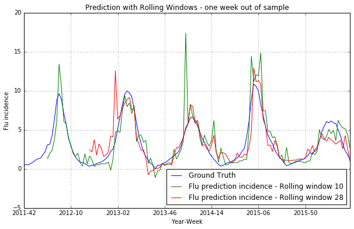

```python
gt_ts.plot(legend=True, label='Ground Truth')
plt.title('Prediction with Rolling Windows - one week out of sample')
plt.xlabel('Year-Week')
plt.ylabel('Flu incidence')
for w in windows:
    flu_pred_rol[w].plot(legend=True, label=('Flu prediction incidence - Rolling window '+ str(w)))
plt.grid()
plt.show()
```

```python
r,t,p = crossCorr(gt_ts[flu_pred_rol[windows[1]].index], flu_pred_rol[windows[1]])
print 'The correlation between Ground Truth and Flu Prediction is:'
print 'Cross-Correlation',round(r,4), 'with statistic test', round(t,4), 'and pvalue', p
```

```
The correlation between Ground Truth and Flu Prediction is:
Cross-Correlation 0.8475 with statistic test 18.7544 and pvalue 0.0
```

An other way to see how the model predict is to select one year, let the model estimate the better coefficients given this subset and after that try to estimate the flu of the next year. In the next cell this are done and at the end plot it.

```python
y_pred = {i:[] for i in range(4)}
for i in range(4):
    X_train = df_top.iloc[i*28:(i+1)*28]
    X_test = df_top.iloc[(i+1)*28:(i+2)*28]
    y_train = gt_ts.iloc[i*28:(i+1)*28]
    y_test = gt_ts.iloc[(i+1)*28:(i+1)*28]
    ridge_cv = linear_model.RidgeCV(fit_intercept=True, normalize=True, alphas = alphas).fit(X_train, y_train)
    ridge = linear_model.Ridge(fit_intercept=True, normalize=True, alpha = round(ridge_cv.alpha_,3)).fit(X_train, y_train)
    y_pred[i].append(ridge.predict(X_test))
```

```python
flu_pred_rol = pd.concat([pd.Series(y_pred[i][0], index=df_top.index[(i+1)*28:(i+2)*28], name=i+1) for i in range(4)], axis=1)
flu_pred_rol = pd.concat([gt_ts, flu_pred_rol], axis=1)
del flu_pred_rol[0]
```

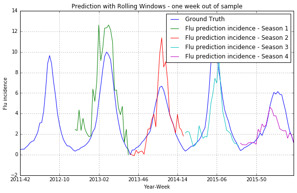

```python
gt_ts.plot(legend=True, label='Ground Truth')
plt.title('Prediction with Rolling Windows - one week out of sample')
plt.xlabel('Year-Week')
plt.ylabel('Flu incidence')
for i in range(4):
    flu_pred_rol[i+1].plot(legend=True, label=('Flu prediction incidence - Season '+ str(i+1)))
plt.grid()
plt.show()
```

Last prediction is done with all the previous season to let estimate the coeff and after that try to estimate the flu of the next year. The difference with the prediction above are only in the period considered to estimate the parameter of the model.

```python
y_pred = {i:[] for i in range(4)}
for i in range(4):
    X_train = df_top.iloc[:(i+1)*28]
    X_test = df_top.iloc[(i+1)*28:(i+2)*28]
    y_train = gt_ts.iloc[:(i+1)*28]
    y_test = gt_ts.iloc[(i+1)*28:(i+1)*28]
    ridge_cv = linear_model.RidgeCV(fit_intercept=True, normalize=True, alphas = alphas).fit(X_train, y_train)
    ridge = linear_model.Ridge(fit_intercept=True, normalize=True, alpha = round(ridge_cv.alpha_,3)).fit(X_train, y_train)
    y_pred[i].append(ridge.predict(X_test))
```

```python
flu_pred_rol = pd.concat([pd.Series(y_pred[i][0], index=df_top.index[(i+1)*28:(i+2)*28], name=i+1) for i in range(4)], axis=1)
flu_pred_rol = pd.concat([gt_ts, flu_pred_rol], axis=1)
del flu_pred_rol[0]
```

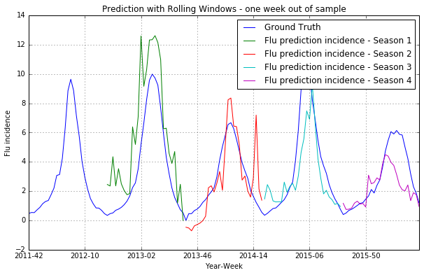

```python
gt_ts.plot(legend=True, label='Ground Truth')
plt.title('Prediction with Rolling Windows - one week out of sample')
plt.xlabel('Year-Week')
plt.ylabel('Flu incidence')
for i in range(4):
    flu_pred_rol[i+1].plot(legend=True, label=('Flu prediction incidence - Season '+ str(i+1)))
plt.grid()
plt.show()
```

## Part 3.2

### Build a regression model with the Influnet incidence for the week preceding the target week and the pageview counts for all the pages you selected for the week

At the beginning of this last part of the assignment I want to see an autocorrelation and partial autocorrelation plot to see how are the series. But first reload the initial dataframe.

```python
# F-test
f_test, _ = f_regression(df_norm,gt_ts)
f_test = normalize([f_test])[0]

# Mutual Information
mi = mutual_info_regression(df_norm,gt_ts)
mi = normalize([mi])[0]

# Cross-Correlation
corr = [crossCorr(gt_ts, df_norm[i])[0] for i in list(df_norm.columns)]
corr = normalize([corr])[0]

# Score
score = np.mean([f_test,mi,corr], axis=0)
```

```python
sort_index_f_test = sorted(range(len(f_test)), key=np.abs(f_test).__getitem__, reverse=True)
sort_index_mi = sorted(range(len(mi)), key=np.abs(mi).__getitem__, reverse=True)
sort_index_corr = sorted(range(len(corr)), key=np.abs(corr).__getitem__, reverse=True)
sort_index_score = sorted(range(len(score)), key=np.abs(score).__getitem__, reverse=True)
```

```python
# Select the top k elements
k = 5
```

```python
f_test_col = ['\033[36m%.4f\033[0m' if i  in sort_index_f_test[0:5] else '\033[30m%.4f' for i in range(len(df_norm.columns))]
mi_col     = ['\033[36m%.4f\033[0m' if i in sort_index_mi[0:k] else '\033[30m%.4f' for i in range(len(df_norm.columns))]
corr_col   = ['\033[36m%.4f\033[0m' if i in sort_index_corr[0:k] else '\033[30m%.4f' for i in range(len(df_norm.columns))]
score_col  = ['\033[36m%.4f\033[0m' if i in sort_index_score[0:k] else '\033[30m%.4f' for i in range(len(df_norm.columns))]
feat_col   = ['\033[46m%s\033[0m' if i in sort_index_score[0:k] else '\033[30m%s' for i in range(len(df_norm.columns))]
```

```python
print ('\t'.join(['f_reg', 'mi', 'corr', 'score', 'feature']))
for i in range(len(df_norm.columns)):
    print('\t'.join([f_test_col[i], mi_col[i], corr_col[i], score_col[i], feat_col[i]]) % (f_test[i], f_test[i], corr[i], score[i], df_norm.columns[i][:33]))
```

```
f_reg	mi	corr	score	feature
0.1085	0.1085	0.2183	0.1510	Amantadina
0.2276	0.2276	0.2902	0.2296	Antivirale
0.0048	0.0048	0.0503	0.0489	Artralgia
0.0025	0.0025	-0.0366	-0.0053	Cefalea
0.0003	0.0003	0.0129	0.0118	Centro_europeo_per_la_prevenzione
0.0492	0.0492	0.1543	0.0910	Epidemia
0.1429	0.1429	0.2440	0.2610	Febbre
0.0036	0.0036	0.0433	0.0298	Fotofobia
0.6835	0.6835	0.3974	0.4777	Influenza
0.0204	0.0204	0.1020	0.0642	Influenza_aviaria
0.2712	0.2712	0.3081	0.2699	Influenzavirus_A
0.3202	0.3202	0.3250	0.3392	Influenzavirus_A_sottotipo_H1N1
0.0011	0.0011	-0.0236	0.0139	Istituto_superiore_di_sanità
0.0050	0.0050	0.0513	0.0231	Mialgia
0.3497	0.3497	0.3339	0.3724	Oseltamivir
0.0136	0.0136	0.0837	0.0476	Pandemia_influenzale
0.1089	0.1089	0.2186	0.1575	Paracetamolo
0.0397	0.0397	0.1397	0.0718	Raffreddore_comune
0.0739	0.0739	0.1852	0.1256	Rinorrea
0.0354	0.0354	0.1325	0.1029	Starnuto
0.0388	0.0388	0.1382	0.0755	Tosse
0.0832	0.0832	-0.1951	0.0877	Vaccino_antinfluenzale
0.0030	0.0030	0.0399	0.0558	Vomito
0.3446	0.3446	0.3324	0.3022	Zanamivir
```

```python
print 'The top feature is', df_norm.columns[score.argmax()],'with score',  round(score.max(),4)
```

```
The top feature is Influenza with score 0.4777
```

```python
ind = np.argpartition(score, -k)[-k:]
ind = ind[np.argsort(score[ind], -1, )][::-1]
```

```python
print 'The top', k, 'features are:'
for i in range(len(ind)):
    print (i+1), ' with value ', round(score[ind[i]],4),'is', df_norm.columns[ind[i]]
```

```
The top 5 features are:
1  with value  0.4777 is Influenza
2  with value  0.3724 is Oseltamivir
3  with value  0.3392 is Influenzavirus_A_sottotipo_H1N1
4  with value  0.3022 is Zanamivir
5  with value  0.2699 is Influenzavirus_A
```

```python
df_top = df_norm[list(df_norm.columns[ind])].copy()
```

```python
df_top_save = df_top.copy()
```

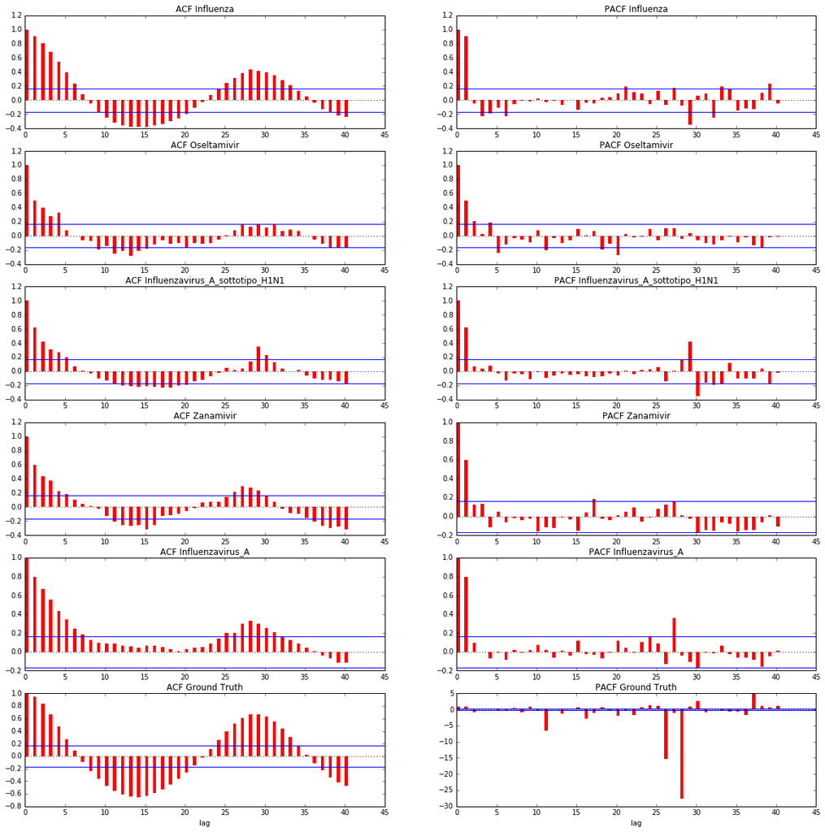

```python
pos = [[0,0],[0,1],[1,0],[1,1],[2,0],[2,1],[3,0],[3,1],[4,0],[4,1],[5,0],[5,1]]
fig, axes = plt.subplots(nrows=6, ncols=2,sharey=False,sharex=False,figsize=(20,20))
z = stats.norm.ppf(0.975)
for i in range(k):
    acf = statsmodels.tsa.stattools.acf(df_top[df_top.columns[i]], alpha=0.05)[0]
    pacf = statsmodels.tsa.stattools.pacf(df_top[df_top.columns[i]], alpha=0.05)[0]
    a,b = pos[i*2]
    n = len(df_top[df_top.columns[i]])
    axes[a,b].bar(np.arange(len(acf)), acf, width=.4, linewidth=0, color='red')
    axes[a,b].set_title('ACF ' + df_top.columns[i])
    #axes[a,b].set_xlabel('lag')
    axes[a,b].axhline(y=z / np.sqrt(n), linestyle='-', color='blue')
    axes[a,b].axhline(y=-z / np.sqrt(n), linestyle='-',linewidth=1, color='blue')
    axes[a,b].axhline(y=0 / np.sqrt(n), linestyle=':', color='black')

    a,b = pos[(i*2)+1]
    axes[a,b].bar(np.arange(len(pacf)), pacf, width=.4, linewidth=0, color='red')
    axes[a,b].set_title('PACF ' + df_top.columns[i])
    #axes[a,b].set_xlabel('lag')
    axes[a,b].axhline(y=z / np.sqrt(n), linestyle='-', color='blue')
    axes[a,b].axhline(y=-z / np.sqrt(n), linestyle='-', color='blue')
    axes[a,b].axhline(y=0 / np.sqrt(n), linestyle=':', color='black')

acf = statsmodels.tsa.stattools.acf(gt_ts, alpha=0.05)[0]
pacf = statsmodels.tsa.stattools.pacf(gt_ts, alpha=0.05)[0]
a,b = pos[(i+1)*2]
n = len(gt_ts)
axes[a,b].bar(np.arange(len(acf)), acf, width=.4, linewidth=0, color='red')
axes[a,b].set_title('ACF ' + 'Ground Truth')
axes[a,b].set_xlabel('lag')
axes[a,b].axhline(y=z / np.sqrt(n), linestyle='-', color='blue')
axes[a,b].axhline(y=-z / np.sqrt(n), linestyle='-',linewidth=1, color='blue')
axes[a,b].axhline(y=0 / np.sqrt(n), linestyle=':', color='black')

a,b = pos[((i+1)*2)+1]
axes[a,b].bar(np.arange(len(pacf)), pacf, width=.4, linewidth=0, color='red')
axes[a,b].set_title('PACF ' + 'Ground Truth')
axes[a,b].set_xlabel('lag')
axes[a,b].axhline(y=z / np.sqrt(n), linestyle='-', color='blue')
axes[a,b].axhline(y=-z / np.sqrt(n), linestyle='-', color='blue')
axes[a,b].axhline(y=0 / np.sqrt(n), linestyle=':', color='black')

plt.show()
```

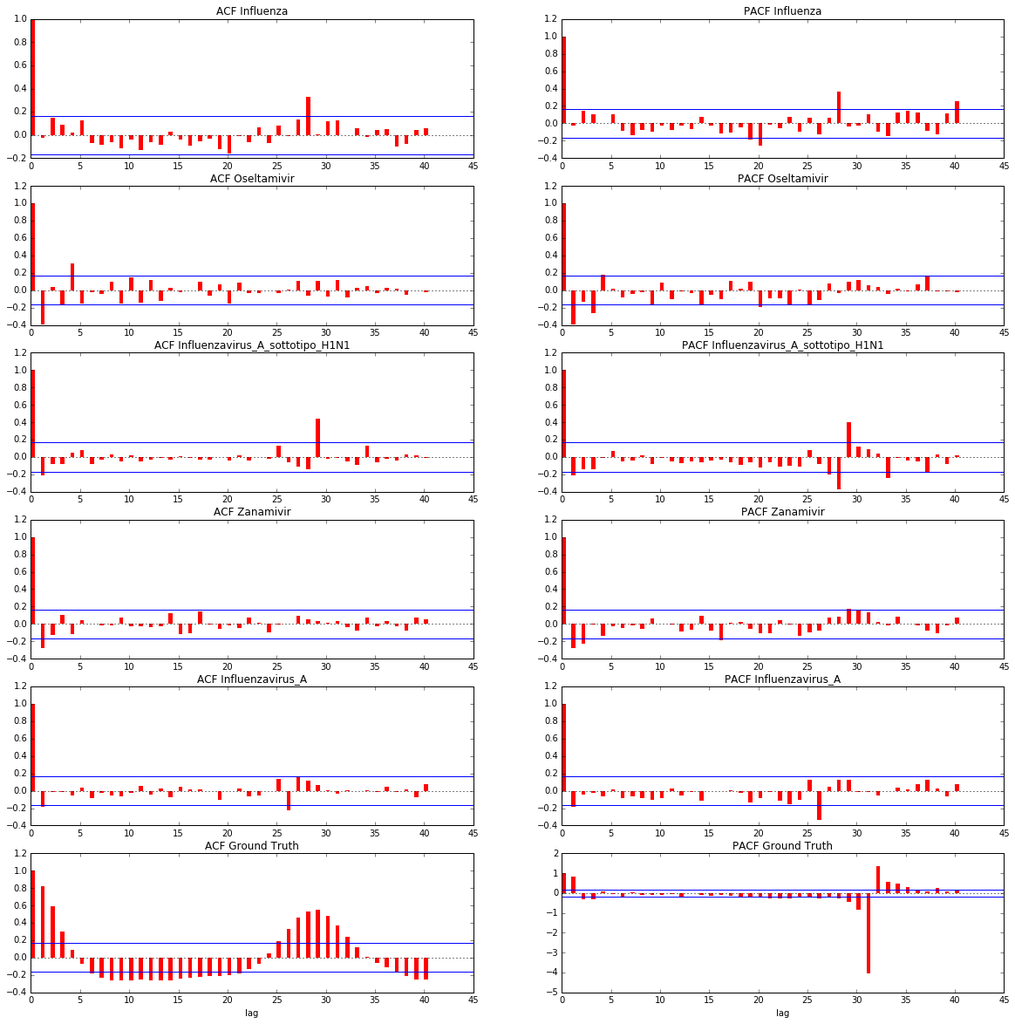

```python
pos = [[0,0],[0,1],[1,0],[1,1],[2,0],[2,1],[3,0],[3,1],[4,0],[4,1],[5,0],[5,1]]
fig, axes = plt.subplots(nrows=6, ncols=2,sharey=False,sharex=False,figsize=(20,20))
z = stats.norm.ppf(0.975)
with warnings.catch_warnings():
    warnings.filterwarnings("ignore")
    for i in range(k):
        arima_treat=statsmodels.tsa.arima_model.ARIMA(df_top[df_top.columns[i]].values, order=(1,0,0)).fit(trend='nc')
        acf = statsmodels.tsa.stattools.acf(df_top[df_top.columns[i]].values-arima_treat.predict(), alpha=0.05)[0]
        pacf = statsmodels.tsa.stattools.pacf(df_top[df_top.columns[i]].values-arima_treat.predict(), alpha=0.05)[0]
        a,b = pos[i*2]
        n = len(df_top[df_top.columns[i]])
        axes[a,b].bar(np.arange(len(acf)), acf, width=.4, linewidth=0, color='red')
        axes[a,b].set_title('ACF ' + df_top.columns[i])
        #axes[a,b].set_xlabel('lag')
        axes[a,b].axhline(y=z / np.sqrt(n), linestyle='-', color='blue')
        axes[a,b].axhline(y=-z / np.sqrt(n), linestyle='-',linewidth=1, color='blue')
        axes[a,b].axhline(y=0 / np.sqrt(n), linestyle=':', color='black')

        a,b = pos[(i*2)+1]
        axes[a,b].bar(np.arange(len(pacf)), pacf, width=.4, linewidth=0, color='red')
        axes[a,b].set_title('PACF ' + df_top.columns[i])
        #axes[a,b].set_xlabel('lag')
        axes[a,b].axhline(y=z / np.sqrt(n), linestyle='-', color='blue')
        axes[a,b].axhline(y=-z / np.sqrt(n), linestyle='-', color='blue')
        axes[a,b].axhline(y=0 / np.sqrt(n), linestyle=':', color='black')

    arima_treat=statsmodels.tsa.arima_model.ARIMA(gt_ts.values, order=(1,0,0)).fit(trend='nc')
    acf = statsmodels.tsa.stattools.acf(gt_ts.values-arima_treat.predict(), alpha=0.05)[0]
    pacf = statsmodels.tsa.stattools.pacf(gt_ts.values-arima_treat.predict(), alpha=0.05)[0]
    a,b = pos[(i+1)*2]
    n = len(gt_ts)
    axes[a,b].bar(np.arange(len(acf)), acf, width=.4, linewidth=0, color='red')
    axes[a,b].set_title('ACF ' + 'Ground Truth')
    axes[a,b].set_xlabel('lag')
    axes[a,b].axhline(y=z / np.sqrt(n), linestyle='-', color='blue')
    axes[a,b].axhline(y=-z / np.sqrt(n), linestyle='-',linewidth=1, color='blue')
    axes[a,b].axhline(y=0 / np.sqrt(n), linestyle=':', color='black')

    a,b = pos[((i+1)*2)+1]
    axes[a,b].bar(np.arange(len(pacf)), pacf, width=.4, linewidth=0, color='red')
    axes[a,b].set_title('PACF ' + 'Ground Truth')
    axes[a,b].set_xlabel('lag')
    axes[a,b].axhline(y=z / np.sqrt(n), linestyle='-', color='blue')
    axes[a,b].axhline(y=-z / np.sqrt(n), linestyle='-', color='blue')
    axes[a,b].axhline(y=0 / np.sqrt(n), linestyle=':', color='black')
plt.show()
```

A consistent improvement we have done! Try to fit the model considering all the feature and with a lag 1.

```python
df_ar = pd.concat([df_top, df_top.shift(1).fillna(0), gt_ts.shift(1).fillna(0)], axis=1)
```

```python
names = list(df_top.columns.values)
names.extend([df_top.columns.values[i]+'_lag1' for i in range(len(df_top.columns))])
names.append('GroundTruth_lag1')
df_ar.columns = names
df_ar
```

|  | Influenza | Oseltamivir | Influenzavirus_A_sottotipo_H1N1 | Zanamivir | Influenzavirus_A | Influenza_lag1 | Oseltamivir_lag1 | Influenzavirus_A_sottotipo_H1N1_lag1 | Zanamivir_lag1 | Influenzavirus_A_lag1 | GroundTruth_lag1 |
| --- | --- | --- | --- | --- | --- | --- | --- | --- | --- | --- | --- |
| 2011-42 | 0.000013 | 1.072135e-06 | 0.000003 | 7.290519e-07 | 8.577081e-07 | 0.000000 | 0.000000e+00 | 0.000000 | 0.000000e+00 | 0.000000e+00 | 0.00 |
| 2011-43 | 0.000011 | 1.177480e-06 | 0.000003 | 6.742836e-07 | 6.440918e-07 | 0.000013 | 1.072135e-06 | 0.000003 | 7.290519e-07 | 8.577081e-07 | 0.47 |
| 2011-44 | 0.000012 | 1.093330e-06 | 0.000004 | 5.696341e-07 | 1.093330e-06 | 0.000011 | 1.177480e-06 | 0.000003 | 6.742836e-07 | 6.440918e-07 | 0.54 |
| 2011-45 | 0.000012 | 1.083432e-06 | 0.000004 | 5.007458e-07 | 6.373129e-07 | 0.000012 | 1.093330e-06 | 0.000004 | 5.696341e-07 | 1.093330e-06 | 0.53 |
| 2011-46 | 0.000013 | 1.152236e-06 | 0.000003 | 6.276408e-07 | 9.086740e-07 | 0.000012 | 1.083432e-06 | 0.000004 | 5.007458e-07 | 6.373129e-07 | 0.72 |
| 2011-47 | 0.000015 | 1.298357e-06 | 0.000004 | 5.591466e-07 | 9.666602e-07 | 0.000013 | 1.152236e-06 | 0.000003 | 6.276408e-07 | 9.086740e-07 | 0.89 |
| 2011-48 | 0.000015 | 1.165627e-06 | 0.000006 | 7.513956e-07 | 1.069294e-06 | 0.000015 | 1.298357e-06 | 0.000004 | 5.591466e-07 | 9.666602e-07 | 1.14 |
| 2011-49 | 0.000014 | 1.591312e-06 | 0.000004 | 9.290892e-07 | 1.077348e-06 | 0.000015 | 1.165627e-06 | 0.000006 | 7.513956e-07 | 1.069294e-06 | 1.29 |
| 2011-50 | 0.000014 | 1.201149e-06 | 0.000004 | 6.630342e-07 | 8.744364e-07 | 0.000014 | 1.591312e-06 | 0.000004 | 9.290892e-07 | 1.077348e-06 | 1.36 |
| 2011-51 | 0.000015 | 1.464593e-06 | 0.000005 | 6.328489e-07 | 1.175291e-06 | 0.000014 | 1.201149e-06 | 0.000004 | 6.630342e-07 | 8.744364e-07 | 1.76 |
| 2011-52 | 0.000018 | 1.241529e-06 | 0.000004 | 6.872752e-07 | 6.983603e-07 | 0.000015 | 1.464593e-06 | 0.000005 | 6.328489e-07 | 1.175291e-06 | 2.20 |
| 2012-01 | 0.000017 | 1.293574e-06 | 0.000004 | 6.092318e-07 | 9.263661e-07 | 0.000018 | 1.241529e-06 | 0.000004 | 6.872752e-07 | 6.983603e-07 | 3.07 |
| 2012-02 | 0.000018 | 1.496395e-06 | 0.000005 | 8.083972e-07 | 9.029969e-07 | 0.000017 | 1.293574e-06 | 0.000004 | 6.092318e-07 | 9.263661e-07 | 3.13 |
| 2012-03 | 0.000019 | 2.211018e-06 | 0.000005 | 7.643026e-07 | 9.553782e-07 | 0.000018 | 1.496395e-06 | 0.000005 | 8.083972e-07 | 9.029969e-07 | 4.24 |
| 2012-04 | 0.000022 | 2.229861e-06 | 0.000005 | 1.244573e-06 | 1.192716e-06 | 0.000019 | 2.211018e-06 | 0.000005 | 7.643026e-07 | 9.553782e-07 | 6.30 |
| 2012-05 | 0.000023 | 2.511898e-06 | 0.000005 | 1.539828e-06 | 1.178527e-06 | 0.000022 | 2.229861e-06 | 0.000005 | 1.244573e-06 | 1.192716e-06 | 8.86 |
| 2012-06 | 0.000019 | 2.189592e-06 | 0.000004 | 1.211797e-06 | 1.270298e-06 | 0.000023 | 2.511898e-06 | 0.000005 | 1.539828e-06 | 1.178527e-06 | 9.64 |
| 2012-07 | 0.000019 | 1.941846e-06 | 0.000004 | 1.124689e-06 | 1.019249e-06 | 0.000019 | 2.189592e-06 | 0.000004 | 1.211797e-06 | 1.270298e-06 | 8.87 |
| 2012-08 | 0.000020 | 1.745514e-06 | 0.000005 | 1.072118e-06 | 9.126291e-07 | 0.000019 | 1.941846e-06 | 0.000004 | 1.124689e-06 | 1.019249e-06 | 7.14 |
| 2012-09 | 0.000015 | 1.283733e-06 | 0.000004 | 6.507812e-07 | 1.007374e-06 | 0.000020 | 1.745514e-06 | 0.000005 | 1.072118e-06 | 9.126291e-07 | 5.75 |
| 2012-10 | 0.000011 | 9.553328e-07 | 0.000004 | 6.678055e-07 | 6.492553e-07 | 0.000015 | 1.283733e-06 | 0.000004 | 6.507812e-07 | 1.007374e-06 | 4.03 |
| 2012-11 | 0.000012 | 1.073835e-06 | 0.000003 | 7.684327e-07 | 8.472463e-07 | 0.000011 | 9.553328e-07 | 0.000004 | 6.678055e-07 | 6.492553e-07 | 2.95 |
| 2012-12 | 0.000009 | 1.015910e-06 | 0.000003 | 5.632769e-07 | 8.449153e-07 | 0.000012 | 1.073835e-06 | 0.000003 | 7.684327e-07 | 8.472463e-07 | 2.13 |
| 2012-13 | 0.000010 | 1.049634e-06 | 0.000003 | 6.963919e-07 | 8.578741e-07 | 0.000009 | 1.015910e-06 | 0.000003 | 5.632769e-07 | 8.449153e-07 | 1.49 |
| 2012-14 | 0.000008 | 9.501452e-07 | 0.000002 | 4.801809e-07 | 7.049464e-07 | 0.000010 | 1.049634e-06 | 0.000003 | 6.963919e-07 | 8.578741e-07 | 1.13 |
| 2012-15 | 0.000008 | 6.984937e-07 | 0.000003 | 5.029154e-07 | 8.009394e-07 | 0.000008 | 9.501452e-07 | 0.000002 | 4.801809e-07 | 7.049464e-07 | 0.85 |
| 2012-16 | 0.000008 | 1.000477e-06 | 0.000004 | 5.797155e-07 | 7.667205e-07 | 0.000008 | 6.984937e-07 | 0.000003 | 5.029154e-07 | 8.009394e-07 | 0.84 |
| 2012-17 | 0.000007 | 7.396940e-07 | 0.000003 | 5.158392e-07 | 7.980909e-07 | 0.000008 | 1.000477e-06 | 0.000004 | 5.797155e-07 | 7.667205e-07 | 0.68 |
| 2012-42 | 0.000013 | 1.201244e-06 | 0.000004 | 5.594837e-07 | 6.417607e-07 | 0.000007 | 7.396940e-07 | 0.000003 | 5.158392e-07 | 7.980909e-07 | 0.46 |
| 2012-43 | 0.000013 | 1.179048e-06 | 0.000003 | 5.567727e-07 | 7.696564e-07 | 0.000013 | 1.201244e-06 | 0.000004 | 5.594837e-07 | 6.417607e-07 | 0.34 |
| ... | ... | ... | ... | ... | ... | ... | ... | ... | ... | ... | ... |
| 2015-16 | 0.000007 | 1.014211e-06 | 0.000003 | 5.759716e-07 | 1.089338e-06 | 0.000009 | 8.483957e-07 | 0.000004 | 6.395598e-07 | 1.187754e-06 | 1.48 |
| 2015-17 | 0.000007 | 7.174352e-07 | 0.000003 | 6.308482e-07 | 9.029788e-07 | 0.000007 | 1.014211e-06 | 0.000003 | 5.759716e-07 | 1.089338e-06 | 1.15 |
| 2015-42 | 0.000010 | 9.896840e-07 | 0.000003 | 3.996801e-07 | 9.706516e-07 | 0.000007 | 7.174352e-07 | 0.000003 | 6.308482e-07 | 9.029788e-07 | 0.75 |
| 2015-43 | 0.000010 | 6.014429e-07 | 0.000004 | 3.608658e-07 | 1.483559e-06 | 0.000010 | 9.896840e-07 | 0.000003 | 3.996801e-07 | 9.706516e-07 | 0.40 |
| 2015-44 | 0.000010 | 8.422656e-07 | 0.000003 | 4.612407e-07 | 1.383722e-06 | 0.000010 | 6.014429e-07 | 0.000004 | 3.608658e-07 | 1.483559e-06 | 0.50 |
| 2015-45 | 0.000011 | 9.496632e-07 | 0.000002 | 5.887912e-07 | 1.025636e-06 | 0.000010 | 8.422656e-07 | 0.000003 | 4.612407e-07 | 1.383722e-06 | 0.68 |
| 2015-46 | 0.000010 | 7.817886e-07 | 0.000003 | 7.073326e-07 | 1.060999e-06 | 0.000011 | 9.496632e-07 | 0.000002 | 5.887912e-07 | 1.025636e-06 | 0.76 |
| 2015-47 | 0.000010 | 8.877312e-07 | 0.000002 | 6.340937e-07 | 1.395006e-06 | 0.000010 | 7.817886e-07 | 0.000003 | 7.073326e-07 | 1.060999e-06 | 0.88 |
| 2015-48 | 0.000011 | 8.850669e-07 | 0.000003 | 5.461051e-07 | 1.073379e-06 | 0.000010 | 8.877312e-07 | 0.000002 | 6.340937e-07 | 1.395006e-06 | 1.02 |
| 2015-49 | 0.000011 | 8.491144e-07 | 0.000003 | 4.245572e-07 | 1.042095e-06 | 0.000011 | 8.850669e-07 | 0.000003 | 5.461051e-07 | 1.073379e-06 | 1.16 |
| 2015-50 | 0.000010 | 1.004248e-06 | 0.000003 | 1.358688e-06 | 1.693438e-06 | 0.000011 | 8.491144e-07 | 0.000003 | 4.245572e-07 | 1.042095e-06 | 1.21 |
| 2015-51 | 0.000012 | 1.058324e-06 | 0.000002 | 7.937431e-07 | 1.180439e-06 | 0.000010 | 1.004248e-06 | 0.000003 | 1.358688e-06 | 1.693438e-06 | 1.45 |
| 2015-52 | 0.000010 | 1.025797e-06 | 0.000003 | 4.771149e-07 | 8.110953e-07 | 0.000012 | 1.058324e-06 | 0.000002 | 7.937431e-07 | 1.180439e-06 | 1.66 |
| 2015-53 | 0.000011 | 1.246322e-06 | 0.000007 | 6.647049e-07 | 6.231608e-07 | 0.000010 | 1.025797e-06 | 0.000003 | 4.771149e-07 | 8.110953e-07 | 2.11 |
| 2016-01 | 0.000011 | 1.029963e-06 | 0.000004 | 5.403085e-07 | 1.671579e-06 | 0.000011 | 1.246322e-06 | 0.000007 | 6.647049e-07 | 6.231608e-07 | 1.87 |
| 2016-02 | 0.000012 | 1.233387e-06 | 0.000006 | 6.084707e-07 | 2.812121e-06 | 0.000011 | 1.029963e-06 | 0.000004 | 5.403085e-07 | 1.671579e-06 | 2.39 |
| 2016-03 | 0.000013 | 2.035614e-06 | 0.000005 | 6.729303e-07 | 1.379507e-06 | 0.000012 | 1.233387e-06 | 0.000006 | 6.084707e-07 | 2.812121e-06 | 2.76 |
| 2016-04 | 0.000012 | 2.366834e-06 | 0.000007 | 8.002962e-07 | 1.975199e-06 | 0.000013 | 2.035614e-06 | 0.000005 | 6.729303e-07 | 1.379507e-06 | 3.62 |
| 2016-05 | 0.000013 | 1.851464e-06 | 0.000007 | 8.006331e-07 | 1.968223e-06 | 0.000012 | 2.366834e-06 | 0.000007 | 8.002962e-07 | 1.975199e-06 | 4.73 |
| 2016-06 | 0.000013 | 1.457624e-06 | 0.000006 | 6.791200e-07 | 1.855157e-06 | 0.000013 | 1.851464e-06 | 0.000007 | 8.006331e-07 | 1.968223e-06 | 5.47 |
| 2016-07 | 0.000013 | 2.032383e-06 | 0.000006 | 7.054554e-07 | 1.830825e-06 | 0.000013 | 1.457624e-06 | 0.000006 | 6.791200e-07 | 1.855157e-06 | 6.06 |
| 2016-08 | 0.000014 | 1.804342e-06 | 0.000006 | 5.080186e-07 | 1.874413e-06 | 0.000013 | 2.032383e-06 | 0.000006 | 7.054554e-07 | 1.830825e-06 | 5.90 |
| 2016-09 | 0.000011 | 1.425243e-06 | 0.000006 | 5.030268e-07 | 1.391708e-06 | 0.000014 | 1.804342e-06 | 0.000006 | 5.080186e-07 | 1.874413e-06 | 6.14 |
| 2016-10 | 0.000012 | 1.725427e-06 | 0.000005 | 5.634047e-07 | 1.443725e-06 | 0.000011 | 1.425243e-06 | 0.000006 | 5.030268e-07 | 1.391708e-06 | 5.88 |
| 2016-11 | 0.000013 | 1.334525e-06 | 0.000006 | 7.550603e-07 | 1.580359e-06 | 0.000012 | 1.725427e-06 | 0.000005 | 5.634047e-07 | 1.443725e-06 | 5.83 |
| 2016-12 | 0.000011 | 1.143864e-06 | 0.000005 | 4.575454e-07 | 1.372636e-06 | 0.000013 | 1.334525e-06 | 0.000006 | 7.550603e-07 | 1.580359e-06 | 5.00 |
| 2016-13 | 0.000013 | 9.615744e-07 | 0.000005 | 3.949323e-07 | 1.425191e-06 | 0.000011 | 1.143864e-06 | 0.000005 | 4.575454e-07 | 1.372636e-06 | 4.23 |
| 2016-14 | 0.000010 | 1.299679e-06 | 0.000006 | 8.099447e-07 | 1.375022e-06 | 0.000013 | 9.615744e-07 | 0.000005 | 3.949323e-07 | 1.425191e-06 | 3.18 |
| 2016-15 | 0.000009 | 6.084034e-07 | 0.000006 | 5.495256e-07 | 1.432692e-06 | 0.000010 | 1.299679e-06 | 0.000006 | 8.099447e-07 | 1.375022e-06 | 2.30 |
| 2016-16 | 0.000009 | 5.559166e-07 | 0.000004 | 4.632638e-07 | 8.709360e-07 | 0.000009 | 6.084034e-07 | 0.000006 | 5.495256e-07 | 1.432692e-06 | 1.85 |

140 rows × 11 columns

The dataframe are ready to fit the model, let's start!

```python
kf = KFold(n_splits=10, shuffle=True).split(df_ar.index)
models = ['LinearRegression','Ridge','Lasso','Bayesian','Polynomial']
mse = {m:[] for m in models}
alphas = [0.01,0.02,0.05,0.08,0.1,0.2,0.5,0.8,1,2,5,8]
```

```python
for tr, te in kf:
    X_train = df_ar.iloc[tr]
    X_test = df_ar.iloc[te]
    y_train = gt_ts.iloc[tr]
    y_test = gt_ts.iloc[te]

    ### Ordinary least squares Linear Regression
    reg = linear_model.LinearRegression(fit_intercept=True, normalize=True).fit(X_train,y_train)
    mse['LinearRegression'].append(np.mean((reg.predict(X_test) - y_test) ** 2))

    ### Ridge Regression
    ridge_cv = linear_model.RidgeCV(fit_intercept=True, normalize=True, alphas = alphas).fit(X_train, y_train)
    ridge = linear_model.Ridge(fit_intercept=True, normalize=True, alpha = round(ridge_cv.alpha_,3)).fit(X_train, y_train)
    mse['Ridge'].append(np.mean((ridge.predict(X_test) - y_test) ** 2))

    ### Lasso Regression
    lasso_cv = linear_model.LassoCV(fit_intercept=True, normalize=True, alphas=alphas).fit(X_train, y_train)
    lasso = linear_model.Lasso(fit_intercept=True, normalize=True, alpha = round(lasso_cv.alpha_,3)).fit(X_train, y_train)
    mse['Lasso'].append(np.mean((lasso.predict(X_test) - y_test) ** 2))

    ### Bayesian Ridge Regression
    bay = linear_model.BayesianRidge(fit_intercept=True, normalize=True).fit(X_train, y_train)
    mse['Bayesian'].append(np.mean((bay.predict(X_test) - y_test) ** 2))

    ### Polynomial Regression
    pol = Pipeline([('poly', PolynomialFeatures(degree=2)),
                    ('linear', linear_model.LinearRegression(fit_intercept=True, normalize=True))]).fit(X_train, y_train)
    mse['Polynomial'].append(np.mean((pol.predict(X_test) - y_test) ** 2))
```

```python
mse_mean = {k: np.mean(mse[k]) for k in models}
print 'MSE models means'
for k, v in mse_mean.iteritems():
    print round(v,6),'\t', k
print '\nThe model with the minimum MSE', min(mse_mean.values()),'is', min(mse_mean, key=mse_mean.get)
```

```
MSE models means
0.530612 	Bayesian
0.528198 	Ridge
9.895118 	Polynomial
0.531165 	LinearRegression
0.50836 	Lasso

The model with the minimum MSE 0.508360060305 is Lasso
```

Lasso model is now the model with the lower MSE. Try to make prediction one obs out of sample.

```python
y_pred = []
for i in range(1,len(df_ar.index)):
    X_train = df_ar.iloc[:i]
    X_test = df_ar.iloc[[i]]
    y_train = gt_ts.iloc[:i]
    y_test = gt_ts.iloc[[i]]
    ridge_cv = linear_model.RidgeCV(fit_intercept=True, normalize=True, alphas = alphas).fit(X_train, y_train)
    ridge = linear_model.Ridge(fit_intercept=True, normalize=True, alpha = round(ridge_cv.alpha_,3)).fit(X_train, y_train)
    y_pred.append(ridge.predict(X_test)[0])
```

```python
flu_pred_rol = pd.Series(y_pred, index=df_ar.index[1:], name='flu_pred')
```

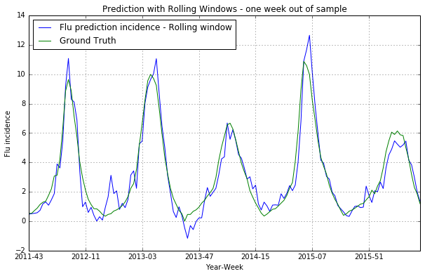

```python
flu_pred_rol.plot(legend=True, label='Flu prediction incidence - Rolling window')
gt_ts[flu_pred_rol.index].plot(legend=True, label=('Ground Truth'))
plt.title('Prediction with Rolling Windows - one week out of sample')
plt.xlabel('Year-Week')
plt.ylabel('Flu incidence')
plt.grid()
plt.show()
```

```python
r,t,p = crossCorr(gt_ts[flu_pred_rol.index], flu_pred_rol)
print 'The correlation between Ground Truth and Flu Prediction is:'
print 'Cross-Correlation',round(r,4), 'with statistic test', round(t,4), 'and pvalue', p
```

```
The correlation between Ground Truth and Flu Prediction is:
Cross-Correlation 0.9603 with statistic test 40.3108 and pvalue 0.0
```

An evident improvement we have done: the series predicted is more similar than the previous model and this is confirmed by cross correlation.

```python
X_train = df_ar.iloc[:(28*3)]
X_test = df_ar.iloc[(28*3):(28*5)]
y_train = gt_ts.iloc[:(28*3)]
y_test = gt_ts.iloc[(28*3):(28*5)]
ridge_cv = linear_model.RidgeCV(fit_intercept=True, normalize=True, alphas = alphas).fit(X_train, y_train)
ridge = linear_model.Ridge(fit_intercept=True, normalize=True, alpha = round(ridge_cv.alpha_,3)).fit(X_train, y_train)
y_pred = ridge.predict(X_test)
```

```python
flu_pred_rol = pd.Series(y_pred, index=df_ar.index[(28*3):(28*5)], name='flu_pred')
```

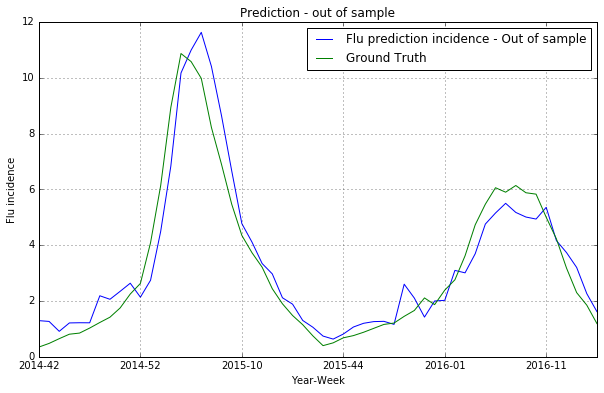

```python
flu_pred_rol.plot(legend=True, label='Flu prediction incidence - Out of sample')
gt_ts[flu_pred_rol.index].plot(legend=True, label=('Ground Truth'))
plt.title('Prediction - out of sample')
plt.xlabel('Year-Week')
plt.ylabel('Flu incidence')
plt.grid()
plt.show()
```

```python
r,t,p = crossCorr(gt_ts[flu_pred_rol.index], flu_pred_rol)
print 'The correlation between Ground Truth and Flu Prediction is:'
print 'Cross-Correlation',round(r,4), 'with statistic test', round(t,4), 'and pvalue', p
```

```
The correlation between Ground Truth and Flu Prediction is:
Cross-Correlation 0.9578 with statistic test 24.4777 and pvalue 0.0
```

```python
MAE = np.mean(abs(y_pred - y_test))
print 'The Mean Absolute Error is :', MAE
```

```
The Mean Absolute Error is : 0.632812388815
```

An other way to see how the model predict is to select one year, let the model estimate the better coefficients given this subset and after that try to estimate the flu of the next year. In the next cell this are done and at the end plot it.

This model and prediction ar emore similar to the paper. They have obtain a Pearson correlation between ground truth and predicted values equal to 0.9854 with lasso model and a MAE 0.29%. We are not so far away from this value and we are satisfied of what we have done.

Repeat the previous prediction with this model and at the end I will try to comment the works and a briefly conclusion.

```python
y_pred = {i:[] for i in range(4)}
for i in range(4):
    X_train = df_ar.iloc[i*28:(i+1)*28]
    X_test = df_ar.iloc[(i+1)*28:(i+2)*28]
    y_train = gt_ts.iloc[i*28:(i+1)*28]
    y_test = gt_ts.iloc[(i+1)*28:(i+1)*28]
    ridge_cv = linear_model.RidgeCV(fit_intercept=True, normalize=True, alphas = alphas).fit(X_train, y_train)
    ridge = linear_model.Ridge(fit_intercept=True, normalize=True, alpha = round(ridge_cv.alpha_,3)).fit(X_train, y_train)
    y_pred[i].append(ridge.predict(X_test))
```

```python
flu_pred_rol = pd.concat([pd.Series(y_pred[i][0], index=df_top.index[(i+1)*28:(i+2)*28], name=i+1) for i in range(4)], axis=1)
flu_pred_rol = pd.concat([gt_ts, flu_pred_rol], axis=1)
del flu_pred_rol[0]
```

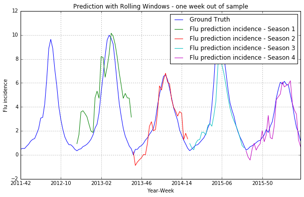

```python
gt_ts.plot(legend=True, label='Ground Truth')
plt.title('Prediction with Rolling Windows - one week out of sample')
plt.xlabel('Year-Week')
plt.ylabel('Flu incidence')
for i in range(4):
    flu_pred_rol[i+1].plot(legend=True, label=('Flu prediction incidence - Season '+ str(i+1)))
plt.grid()
plt.show()
```

Last prediction is done with all the previous season to let estimate the coeff and after that try to estimate the flu of the next year. The difference with the prediction above are only in the period considered to estimate the parameter of the model.

```python
y_pred = {i:[] for i in range(4)}
for i in range(4):
    X_train = df_ar.iloc[:(i+1)*28]
    X_test = df_ar.iloc[(i+1)*28:(i+2)*28]
    y_train = gt_ts.iloc[:(i+1)*28]
    y_test = gt_ts.iloc[(i+1)*28:(i+1)*28]
    ridge_cv = linear_model.RidgeCV(fit_intercept=True, normalize=True, alphas = alphas).fit(X_train, y_train)
    ridge = linear_model.Ridge(fit_intercept=True, normalize=True, alpha = round(ridge_cv.alpha_,3)).fit(X_train, y_train)
    y_pred[i].append(ridge.predict(X_test))
```

```python
flu_pred_rol = pd.concat([pd.Series(y_pred[i][0], index=df_top.index[(i+1)*28:(i+2)*28], name=i+1) for i in range(4)], axis=1)
flu_pred_rol = pd.concat([gt_ts, flu_pred_rol], axis=1)
del flu_pred_rol[0]
```

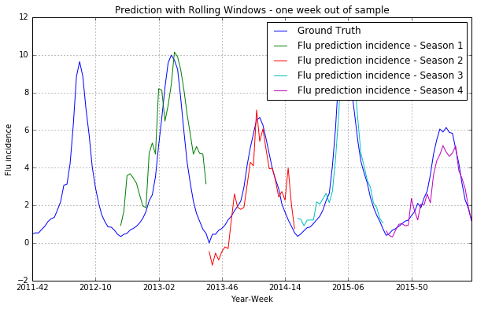

```python
gt_ts.plot(legend=True, label='Ground Truth')
plt.title('Prediction with Rolling Windows - one week out of sample')
plt.xlabel('Year-Week')
plt.ylabel('Flu incidence')
for i in range(4):
    flu_pred_rol[i+1].plot(legend=True, label=('Flu prediction incidence - Season '+ str(i+1)))
plt.grid()
plt.show()
```

#### Note and conclusion

In this last case we have seen thata a simpler model, such as Lasso, is better to make prediction of a series.

Furthermore, we have seen the role of the autoregressive process of order 1, previously in the ACF and PACF plot and after in the model estimate.

To reduce the work of download data from wikipedia, we could drop out the night views and we don't loose information about our research.

The difference with the paper is mainly due to:

- population in Italy don't use a lot the pc and in particular internet. Without internet the people with flu don't search information on the net;
- the time series have one year extra;
- the time series are of all the years and not only the flu seasons (294 obs vs 140 our obs);